## [ 2020 NH투자증권 Y&Z세대 투자자 프로파일링 보고서 ]

### Title:

# "FARM분석 기반 Y&Z세대 투자자 커뮤니티 형성과 포인트제도 도입 제안"

### FARMers 팀 (김동현, 우현우, 장은조)

## Highlights

- Factor Analysis (요인분석)을 통해 측정오차를 통제함과 동시에 Y&Z세대의 잠재된 공통의 특성을 추출하였다.
- 유사성이 높은 변수들을 조합하여, Y&Z세대 주식투자자들의 특성을 나타내는 F, A, R, M이라는 4가지 핵심요인을 선정하였다.
- 확률적 추정 기반의 Latent Profile Analysis (LPA; 잠재프로파일분석)을 적용하여 기존의 군집분석의 한계를 보완하였다.
- Y&Z세대만의 두드러진 특성(커뮤니티와 포인트 적립)을 이용해 상품 및 서비스를 기획하였다.

# Abstract (요약)

2020년 상반기 국내와 해외 주식 시장은 모두 COVIID-19의 영향으로 큰 변동이 발생하였고, 그 이전 시기와 비교할 때 개인 투자자들의 대규모 유입과 적극적 투자 활동이 있었다. 그중에서도 국내 Y&Z세대의 주식에 대한 이례적인 관심과 투자의 급증은 금융권과 증권사의 큰 주목을 받고 있다. 이로 인해 증권사는 기존의 주식 시장의 핵심 고객층이라 보기 어려웠었던 Y&Z세대에 대한 면밀한 분석과 효과적인 Customer Relationship Management (CRM; 고객관계관리) 전략을 세워야 한다. 따라서 본 프로젝트는 2019년부터 2020년 상반기의 NH투자증권의 주식거래 데이터를 이용해, Y&Z세대 투자자에 대한 고객 프로파일링을 위한 "FARM" 분석을 제안한다. 이는 투자자의 특징과 관련성이 높은 변수들에 대해 Factor Analysis (FA; 요인분석)을 통해 핵심 요인을 추출한 뒤, 해당 요인들에 대한 Latent Profile Analysis (잠재프로파일분석; LPA)을 통해 투자자군 프로파일링을 시행한다. 해당 결과를 기반으로 Y&Z세대의 특성을 충분히 반영한 상품과 서비스를 기획하고 NH투자증권에 제안한다.

#### Keywords: 요인분석 (Factor Anaylsis), 잠재프로파일분석 (Latent Profile Analysis), CRM, NH투자증권, Y&Z세대

#### [Dataset]

##### - NH투자증권 주식거래 데이터 ('2019.1.~'2020.6.)

##### - 한국거래소 코스피 &코스닥 상장종목 데이터 ('2020.12.)

#### [Libraries (라이브러리)]

```r
suppressMessages({install.packages(c("gridExtra","data.table","FactoMineR","factoextra","corrplot","psy","psych","tidyLPA","lubridate","stringr","outliers","reshape","dplyr","ggplot2","gridExtra","grid","gridBase","PupillometryR"))})

library(gridExtra)
library(data.table)
library(FactoMineR)
library(factoextra)
library(corrplot)
library(psy)
library(psych)
library(tidyLPA)
library(lubridate)
library(stringr)
library(outliers)
library(reshape)
library(dplyr)
library(ggplot2)
library(gridExtra)
library(grid)
library(gridBase)
library(PupillometryR)
```

```
  There are binary versions available but the source versions are later:
           binary source needs_compilation
data.table 1.13.4 1.13.6              TRUE
ggplot2     3.3.2  3.3.3             FALSE
```

# 1. Introduction (서론)

## 1.1 Background & Literature Reveiw (배경 & 문헌 조사)

### 2020년 주식 투자 상황

```
    2020년 COVID-19 (코로나)의 전세계적 대유행으로 글로벌 주식시장의 변동성은 2000년대 글로벌 금융위기 이후 약 12년 만에 최고치를 갱신하였다. 이는 해외뿐만 아니라, 국내 증시에도 금융위기 이후 가장 높은 변동성을 보였다. COVID-19 Pandemic으로 인해 세계적인 경제 불확실성이 확대되면서, 전통적인 위험자산으로 여겨지는 국내 개인투자자들의 주식에 대한 투자 역시 급증하고 있다. 특히 2020년에 주식 신규 투자자들이 많이 발생하였는데, 신규 개인 주식계좌는 2020년 1월부터 12월 15일까지를 기준으로 작년대비 4.7배 상승한 216만 2,802개에 달한다. 이로 인해 2020년의 국내 주식 거래에 대한 관심과 규모는 최근 5년 대비 월등하게 커진 것으로 밝혀졌다. 특히 국내 개인투자자의 월평균 순매수 금액은 2020년에만 6.8조원으로, 금융위기 당시 0.5조원과 비교할 때 순매수세가 훨씬 강하다고 할 수가 있다.
```

### 떠오르는 주식투자자 YZ세대

```
     2020년 국내 주식시장에서 가장 큰 변화와 주목을 받은 것은 Y&Z세대 (본 공모전에서의 정의로 20대와 30대)이다. Lee & Wei (2018)에 따르면, 2019년 Y&Z세대의 비중은 전세계 인구의 31.5%인 24억 4,000만 명에 달한다. 국내 Y&Z 세대 역시 1,000만 명이 넘는 숫자로 대한민국 국민의 1/5 이상을 차지하는데, 더욱이 이들이 경제와 사회적 측면에서 가지는 소비 파워가 전체 인구 수에서 차지하는 비중보다 훨씬 더 크게 작용할 것으로 알려져 있다 (이필원, 2019).주식 투자자로서 이들은 2020년 신규개좌를 개설한 개인고객의 약 52.1%을 차지하며, 국내 주식시장에서 Y&Z세대가 차지하는 비율은 전체의 약 57%에 달한다. 주식투자 비율의 증가폭도 가장 컸다. 20대의 주식투자 비율은 2018년 대비 3.5배 증가한 56.2%였고, 30대의 경우 1.6배 증가한 48.5%의 높은 증가율을 보였다. 반면, 40대 이상에서는 주식투자 양상의 차이가 크지 않았으며, 2018년에 35%에서 2020년 41.9%의 소폭 상승 수준이었다. 뿐만 아니라, 2020년 해외투자의 경우에 20대, 30대, 그리고 40대는 2018년 대비 각각 6.5배 (11.8%), 3배 (11.8%), 3.4배 (8.6%) 증가하였다.
    이러한 Y&Z세대가 X세대라 알려져있는 기존 세대와 가지는 가장 큰 차이점은, 개성, 자기만족, 그리고 자아실현 욕구를 추구하는 경향이 매우 높다는 것이다.이들은 어린 시절부터 다양한 디지털 서비스를 접하면서 자기 표현과 소셜 네트워킹, 그리고 소통에 적극적이다. 또한 현금이나 잔돈을 들고다니지 않는 것에 익숙한 세대라는 점에서, 제품이나 서비스를 이용할 때에 포인트를 쌓고 이를 적절히 활용하는 데에 능숙한 것으로 알려져 있다. 그러나, 이러한 Y&Z세대는 이전의 X세대에 비해 조직에 대한 헌신이나 충성심이 부족하다는 부정적인 의견도 제시되고 있다 (Fromm et al., 2011). 따라서 증권사는 Y&Z세대 투자자들의 개성과 소통 욕구를 충족시켜줌과 동시에 고객으로서의 충성심이 아닌 흥미를 통한 재방문을 높이는 방향의 전략이 필요하다.
```

### 투자자 프로파일링 기존 연구

[output not shown]

## 1.2 Data Driven Verification (데이터 기반 검증)

### (Data Preprocessing)

```r
# 파일 불러오기
cus_info <- read.csv('2_cus_info.csv')
act_info <- read.csv('2_act_info.csv')
trd_kr <- fread('2_trd_kr.csv')
trd_oss <- fread('2_trd_oss.csv')
iem_info <- read.csv('2_iem_info.csv', encoding = 'UTF-8')

# 변수명 재점검
colnames(cus_info) <- c('cus_id','sex_dit_cd','cus_age','zip_ctp_cd','tco_cus_grd_cd','ivs_icn_cd')
colnames(act_info) <-c('act_id','cus_id','act_opn_ym')
colnames(iem_info) <- c('iem_cd','iem_eng_nm','iem_krl_nm')

# 주식종목명에 대한 여백 제거
iem_info$iem_cd <- str_trim(iem_info$iem_cd , side = 'right')
iem_info$iem_eng_nm <- str_trim(iem_info$iem_eng_nm, side = 'right')
iem_info$iem_krl_nm <- str_trim(iem_info$iem_krl_nm, side = 'right')
```

```r
# {X, Y, Z}세대 각각에 대한 dataframe 생성
cus_info_x <- cus_info %>% filter(cus_age %in% c('40','45','50','55','60','65','70'))  # 6370명
cus_info_y <- cus_info %>% filter(cus_age %in% c('30','35'))  #2164명
cus_info_z <- cus_info %>% filter(cus_age %in% c('20','25'))  #1254명
```

```r
# 주식거래금액 변수에 대한 단위 통일 [Korean Won; 원]
trd_kr$tot_pr = trd_kr$cns_qty * trd_kr$orr_pr # 거래량[주] * 주당 거래단가[원] (거래당 총 거래금액)
trd_oss$tot_pr = trd_oss$cns_qty * trd_oss$orr_pr * trd_oss$trd_cur_xcg_rt # 해외주식에 대한 거래당 총 거래금액
trd_oss$orr_pr = trd_oss$orr_pr * trd_oss$trd_cur_xcg_rt # 해외주식에 대한 종목당 단가 [korean Won]
trd_tot = bind_rows(list(kr= trd_kr, oss= trd_oss), .id="country") # 국내와 해외 주식 거래를 합한 하나의 dataframe
```

```r
# 시간 변수 설정 (연year, 월month, 분기quarter)
trd_tot$orr_dt = ymd(trd_tot$orr_dt) # Year-Month-Day
trd_tot$trd_year = year(trd_tot$orr_dt)
trd_tot$trd_month = month(trd_tot$orr_dt)
trd_tot$trd_quarter= quarter(trd_tot$orr_dt) # Quarter (분기)
trd_tot$trd_ym = trd_tot$trd_year*100 + trd_tot$trd_month # YYYYMM
trd_tot$trd_yQ = trd_tot$trd_year*100 + trd_tot$trd_quarter # YYYYQQ

act_info$opn_year = floor((act_info$act_opn_ym)/100) # YYYY
act_info$opn_month = act_info$act_opn_ym - (act_info$opn_year)*100 # MM
act_info$opn_quarter = ifelse(act_info$opn_month == 0, 0,
                              ifelse(act_info$opn_month < 4, 1,
                                     ifelse(act_info$opn_month < 7, 2,
                                            ifelse(act_info$opn_month < 10, 3, 4)
                                     )
                              )
) # QQ
act_info$opn_yQ = (act_info$opn_year)*100 + act_info$opn_quarter # YYYYQQ
```

```r
# 변수 (고객당 보유하고 있는 주식 계좌 수) 추가
act_info <- left_join(act_info,
                      act_info %>% group_by(cus_id) %>% summarize(act_tot_count=n()), by = 'cus_id')
# 계좌정보 dataframe에 (고객)에 대한 정보를 추가
act_info <- left_join(act_info,cus_info, by = 'cus_id')
# 연령에 따라 X, Y, Z 세대 Categorization (20대 미만은 "B")
act_info$age_group <- ifelse(act_info$cus_age %in% c('20','25'),'Z',
                          ifelse(act_info$cus_age %in% c('30','35'),'Y',
                             ifelse(act_info$cus_age %in% c('40','45','50','55','60','65','70'),'X','B')))
```

```r
# {계좌정보, 고객정보}가 합쳐진 Dataframe: act_info
head(act_info) # Unique key: "계좌(act_id)"
```

| act_id | cus_id | act_opn_ym | opn_year | opn_month | opn_quarter | opn_yQ | act_tot_count | sex_dit_cd | cus_age | zip_ctp_cd | tco_cus_grd_cd | ivs_icn_cd | age_group |
| --- | --- | --- | --- | --- | --- | --- | --- | --- | --- | --- | --- | --- | --- |
| 8e1a987ebef2a3374ba558aeda4c7821de7808a11cfea1e149438ae91f1d4c79 | 892f41b5002a79c9c93992acf60682f5698372aea023bda68d942687109ae8ab | 197912 | 1979 | 12 | 4 | 197904 | 40 | 1 | 65 | 11 | 01 | 04 | X |
| eb161b66263589c3f38efd2277cec2a9a81e1ffa0a5255931265d35f4b064b67 | 006ad32069efb2a8ce1a99542dfe41cb14e8e75685278a3ce127ab83d04fbafa | 198702 | 1987 | 2 | 1 | 198701 | 3 | 1 | 35 | 28 | 09 | - | Y |
| 01866857515304e9e1315e54863cc1108e1d46fff0d467fe1d405b96a06ece0c | 1925ed2d8ed2cad53997f5b24722482137c4d1da4b555e9217722a3b3397f9ab | 199109 | 1991 | 9 | 3 | 199103 | 29 | 2 | 60 | 41 | 02 | 04 | X |
| 63a58b0fee2fa4dc467c043fde465846b65705659497c5e627b43247b221a143 | 7829365dc463ed8275c8b92518d58b3c8d983f00f7bf87ba7e567981e13a1f3a | 199401 | 1994 | 1 | 1 | 199401 | 11 | 1 | 55 | 11 | 03 | 03 | X |
| b563fb76d3d432d67198f194701ca67e895da4c2f24e8ea94ea24583286c3e90 | 36e05dde058cf7531bd4001ed3b976ef9562a9ecd9f43df4a4b159da18dfea07 | 199404 | 1994 | 4 | 2 | 199402 | 14 | 1 | 55 | 41 | 04 | 04 | X |
| 1f27eba90952bc73234c4f23371c5259e7cded486464d2de4dc10421157ce2d2 | 21468fbf60a09ff57945f45bf08a8c9d939f9807576f88c305750f26ed1a586a | 199412 | 1994 | 12 | 4 | 199404 | 4 | 1 | 50 | 11 | 03 | 04 | X |

```r
# {거래정보 & 계좌정보 & 고객정보}가 모두 합쳐진 Dataframe: trd_tot
trd_tot <- left_join(trd_tot, act_info, by = 'act_id') # 거래정보 dataframe에 (계좌와 고객)에 대한 정보를 추가
head(trd_tot) # Unique key: "계좌(act_id)"
```

| country | act_id | orr_dt | orr_ord | orr_rtn_hur | lst_cns_hur | iem_cd | sby_dit_cd | cns_qty | orr_pr | ... | opn_month | opn_quarter | opn_yQ | act_tot_count | sex_dit_cd | cus_age | zip_ctp_cd | tco_cus_grd_cd | ivs_icn_cd | age_group |
| --- | --- | --- | --- | --- | --- | --- | --- | --- | --- | --- | --- | --- | --- | --- | --- | --- | --- | --- | --- | --- |
| kr | 6caf4de40251d37cbba310f0c6dd0ed8f4c7ca4ccfa67560534c60f7d2da3332 | 2019-01-02 | 1 | 12 | 13 | A215600 | 2 | 35 | 74200 | ... | 12 | 4 | 200504 | 12 | 1 | 55 | 11 | 02 | 05 | X |
| kr | 6caf4de40251d37cbba310f0c6dd0ed8f4c7ca4ccfa67560534c60f7d2da3332 | 2019-01-02 | 2 | 12 | 12 | A001060 | 2 | 20 | 41100 | ... | 12 | 4 | 200504 | 12 | 1 | 55 | 11 | 02 | 05 | X |
| kr | effb34815e1b7efb34beb550f604ede8ac71a5a71edb30a0250e48c3b1bcafdb | 2019-01-02 | 1 | 14 | 14 | A281820 | 2 | 20 | 9460 | ... | 10 | 4 | 199804 | 4 | 2 | 50 | 44 | 04 | - | X |
| kr | fea6c038cb7236a02d1e779262698a36219b4c9b527ab10328f82fe08ccc5d91 | 2019-01-02 | 1 | 12 | 12 | A006650 | 2 | 1 | 148500 | ... | 9 | 3 | 201103 | 1 | 1 | 35 | 30 | 04 | 04 | Y |
| kr | fea6c038cb7236a02d1e779262698a36219b4c9b527ab10328f82fe08ccc5d91 | 2019-01-02 | 2 | 12 | 13 | A051360 | 2 | 10 | 6550 | ... | 9 | 3 | 201103 | 1 | 1 | 35 | 30 | 04 | 04 | Y |
| kr | fea6c038cb7236a02d1e779262698a36219b4c9b527ab10328f82fe08ccc5d91 | 2019-01-02 | 3 | 12 | 13 | A051360 | 2 | 10 | 6560 | ... | 9 | 3 | 201103 | 1 | 1 | 35 | 30 | 04 | 04 | Y |

### (2020년 주식 투자 상황)

## "2020년 투자자 & 투자규모 급증, 주식시장의 급격한 규모 성장. 과거와는 다른 판이 열렸다!"

신규 투자자의 대거 유입, 기존 투자자들의 적극적 투자 증가. 따라서 우리는 2020년 데이터에 집중해야 한다.

### (a) 투자 규모 확인

과거대비 2020년 {거래 계좌의 수, 거래 투자자의 수, 거래량, 거래빈도, 거래총금액} 면에서 모두 급격한 증가를 확인할 수 있다.

- 분기별 거래 기록이 있는 계좌의 수 비교:

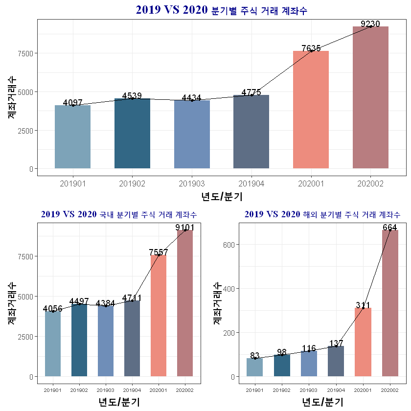

```r
theme_1 <- theme(axis.title.x = element_text(size  = 15, face  = "bold", angle = 0, vjust = 0.5),
                 axis.title.y = element_text(size  = 15, face  = "bold", angle = 0, vjust = 0.5),
                 legend.position="none",
                 plot.title = element_text(family = "serif", face = "bold", hjust = 0.5, size = 15, color = "darkblue"))

col_1 <- c("#7DA3B8", "#326785", "#6F8EB8",'#5E6E85','#ED8C7E','#B87D80')


lay <- rbind(c(3,3),
             c(1,2))

# 분기별 주식 거래 계좌 수 Graph
trd_actid_df <- trd_tot %>% group_by(trd_yQ) %>% summarise(unique_actid = n_distinct(act_id))

a <- trd_actid_df%>%
     data.frame() %>%
    ggplot( aes(x= factor(trd_yQ), y = unique_actid)) +
    geom_bar(stat="identity",width=.6, fill = col_1 ) +
    ylab('계좌거래수') + xlab('년도/분기') +
    geom_line(aes(group = TRUE)) +
    geom_point(size = 1) +  theme_bw() +
    ggtitle('2019 VS 2020 분기별 주식 거래 계좌수') +
    geom_text(aes(label = unique_actid), vjust = 0, color = "black") + theme_1 +
  theme(axis.title.x = element_text(size  = 15, face  = "bold", angle = 0, vjust = 0.5),
        axis.title.y = element_text(size  = 15, face  = "bold", angle = 90, vjust = 0.5),
        plot.title = element_text(family = "serif", face = "bold", hjust = 0.5, size = 15, color = "darkblue"),
       axis.text.x = element_text(size=10))

# 분기별 주식 거래 계좌 수 Graph (국내 vs 해외 비교)
trd_actid_df <- trd_tot %>% group_by(country,trd_yQ) %>% summarise(unique_actid = n_distinct(act_id))
a_kr <- trd_actid_df%>%
  data.frame() %>%
  filter(country == 'kr') %>%
  ggplot( aes(x= factor(trd_yQ), y = unique_actid)) +
  geom_bar(stat="identity",width=.6, fill = col_1) +
  geom_line(aes(group = TRUE)) +
  geom_point(size = 1) +
  ylab('계좌거래수') + xlab('년도/분기') +
  theme_bw() +
  ggtitle('2019 VS 2020 국내 분기별 주식 거래 계좌수') +
  geom_text(aes(label = unique_actid), vjust = 0, color = "black") + theme_1 +
  theme(axis.title.x = element_text(size  = 15, face  = "bold", angle = 0, vjust = 0.5),
        axis.title.y = element_text(size  = 15, face  = "bold", angle = 90, vjust = 0.5),
        plot.title = element_text(family = "serif", face = "bold", hjust = 0.5, size = 12, color = "darkblue"),
       axis.text.x = element_text(size=6))

a_oss <- trd_actid_df%>%
  data.frame() %>%
  filter(country == 'oss') %>%
  ggplot( aes(x= factor(trd_yQ), y = unique_actid)) +
  geom_bar(stat="identity",width=.6, fill = col_1) +
  geom_line(aes(group = TRUE)) +
  geom_point(size = 1) +
  ylab('계좌거래수') + xlab('년도/분기') +
  theme_bw() +
  ggtitle('2019 VS 2020 해외 분기별 주식 거래 계좌수') +
  geom_text(aes(label = unique_actid), vjust = 0, color = "black") + theme_1 +
  theme(axis.title.x = element_text(size  = 15, face  = "bold", angle = 0, vjust = 0.5),
        axis.title.y = element_text(size  = 15, face  = "bold", angle = 90, vjust = 0.5),
        plot.title = element_text(family = "serif", face = "bold", hjust = 0.5, size = 12, color = "darkblue"),
       axis.text.x = element_text(size=6))


grid.arrange(a_kr,a_oss,a,layout_matrix = lay)
```

- 분기별 투자자 수 비교:

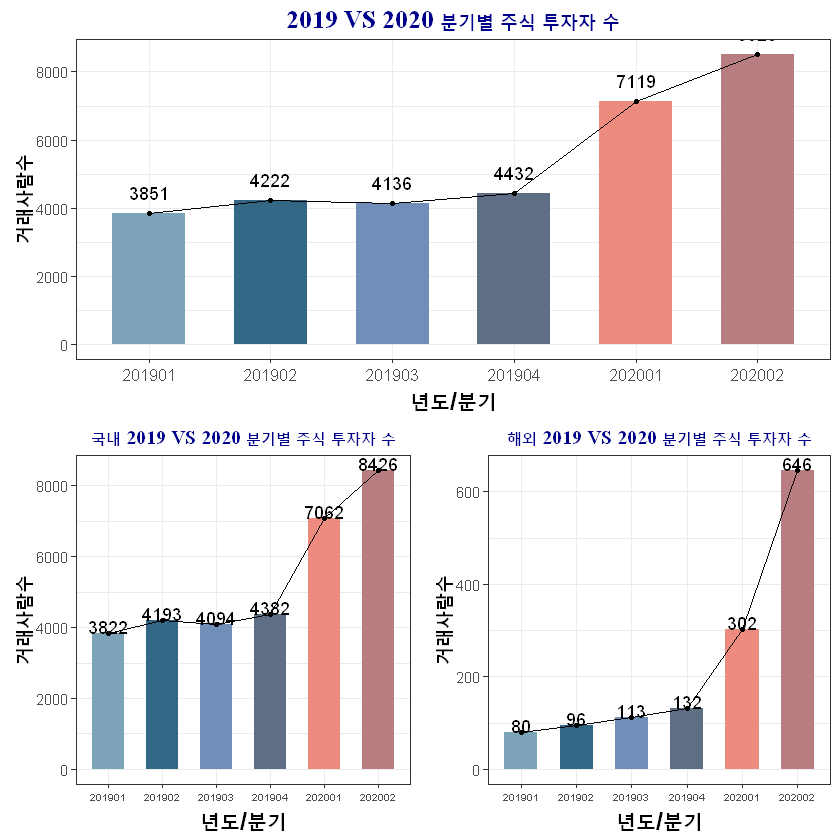

```r
# 분기별 주식 투자자 수 Graph
trd_cusid_df <- trd_tot %>% group_by(trd_yQ) %>% summarise(unique_cusid = n_distinct(cus_id))
b <- trd_cusid_df%>%
   data.frame() %>%
    ggplot( aes(x= factor(trd_yQ), y = unique_cusid)) +
    geom_bar(stat="identity",width=.6, fill = col_1) +
    geom_line(aes(group = TRUE)) +
    geom_point(size = 1) +
    ylab('거래사람수') + xlab('년도/분기') +
    theme_bw() +
    ggtitle('2019 VS 2020 분기별 주식 투자자 수') +
    geom_text(aes(label = unique_cusid), vjust = -1, color = "black") + theme_1+
  theme(axis.title.x = element_text(size  = 15, face  = "bold", angle = 0, vjust = 0.5),
        axis.title.y = element_text(size  = 15, face  = "bold", angle = 90, vjust = 0.5),
        plot.title = element_text(family = "serif", face = "bold", hjust = 0.5, size = 15, color = "darkblue"),
       axis.text.x = element_text(size=10))

# 분기별 주식 투자자 수 Graph (국내 vs 해외 비교)
trd_cusid_df <- trd_tot %>% group_by(country,trd_yQ) %>% summarise(unique_cusid = n_distinct(cus_id))
b_kr <- trd_cusid_df%>%
  data.frame() %>%
  filter(country == 'kr') %>%
  ggplot( aes(x= factor(trd_yQ), y = unique_cusid)) +
  geom_bar(stat="identity",width=.6, fill = col_1) +
  geom_line(aes(group = TRUE)) +
  geom_point(size = 1) +
  ylab('거래사람수') + xlab('년도/분기') +
  theme_bw() +
  ggtitle('국내 2019 VS 2020 분기별 주식 투자자 수') +
  geom_text(aes(label = unique_cusid), vjust = 0, color = "black") + theme_1+
  theme(axis.title.x = element_text(size  = 15, face  = "bold", angle = 0, vjust = 0.5),
        axis.title.y = element_text(size  = 15, face  = "bold", angle = 90, vjust = 0.5),
        plot.title = element_text(family = "serif", face = "bold", hjust = 0.5, size = 12, color = "darkblue"),
       axis.text.x = element_text(size=6))
b_oss <- trd_cusid_df%>%
  data.frame() %>%
  filter(country == 'oss') %>%
  ggplot( aes(x= factor(trd_yQ), y = unique_cusid)) +
  geom_bar(stat="identity",width=.6, fill = col_1) +
  geom_line(aes(group = TRUE)) +
  geom_point(size = 1) +
  ylab('거래사람수') + xlab('년도/분기') +
  theme_bw() +
  ggtitle('해외 2019 VS 2020 분기별 주식 투자자 수') +
  geom_text(aes(label = unique_cusid), vjust = 0, color = "black") + theme_1+
  theme(axis.title.x = element_text(size  = 15, face  = "bold", angle = 0, vjust = 0.5),
        axis.title.y = element_text(size  = 15, face  = "bold", angle = 90, vjust = 0.5),
        plot.title = element_text(family = "serif", face = "bold", hjust = 0.5, size = 12, color = "darkblue"),
       axis.text.x = element_text(size=6))


grid.arrange(b_kr,b_oss,b,layout_matrix = lay)
```

- 분기별 거래량(=매수량+매도량)의 합 비교:

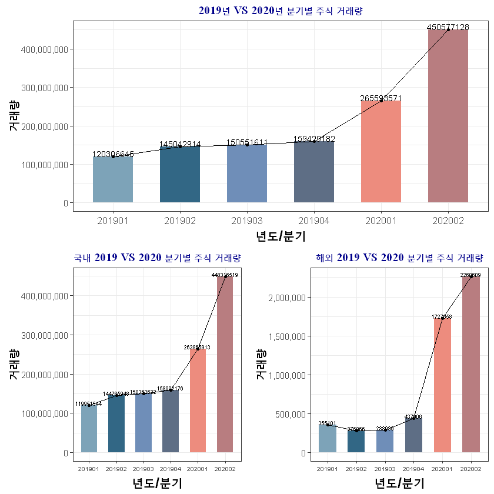

```r
# 분기별 주식 거래량 Graph
trd_qty_df <- trd_tot %>% group_by(trd_yQ) %>% summarise(sum_qty = sum(cns_qty))
c <- trd_qty_df%>%
  data.frame() %>%
    ggplot( aes(x= factor(trd_yQ), y = sum_qty)) +
    geom_bar(stat="identity",width=.6, fill = col_1) +
    geom_line(aes(group = TRUE)) +
    geom_point(size = 1) +
    ylab('거래량') + xlab('년도/분기') +
    theme_bw() +
    ggtitle('2019년 VS 2020년 분기별 주식 거래량') +
    geom_text(aes(label = sum_qty), vjust = 0, color = "black", size = 3) + theme_1 +
    scale_y_continuous(labels = scales::comma)+
  theme(axis.title.x = element_text(size  = 15, face  = "bold", angle = 0, vjust = 0.5),
        axis.title.y = element_text(size  = 15, face  = "bold", angle = 90, vjust = 0.5),
        plot.title = element_text(family = "serif", face = "bold", hjust = 0.5, size = 12, color = "darkblue"),
       axis.text.x = element_text(size=10))

trd_qty_df <- trd_tot %>% group_by(country,trd_yQ) %>% summarise(sum_qty = sum(cns_qty))

# 분기별 주식 거래량 Graph (국내 vs 해외 비교)
trd_qty_df <- trd_tot %>% group_by(country,trd_yQ) %>% summarise(sum_qty = sum(cns_qty))
c_kr <- trd_qty_df%>%
  data.frame() %>%
  filter(country=='kr') %>%
  ggplot( aes(x= factor(trd_yQ), y = sum_qty)) +
  geom_bar(stat="identity",width=.6, fill = col_1) +
  geom_line(aes(group = TRUE)) +
  geom_point(size = 1) +
  ylab('거래량') + xlab('년도/분기') +
  theme_bw() +
  ggtitle('국내 2019 VS 2020 분기별 주식 거래량') +
  geom_text(aes(label = sum_qty), vjust = 0, color = "black", size = 2) + theme_1 +
  scale_y_continuous(labels = scales::comma)+
  theme(axis.title.x = element_text(size  = 15, face  = "bold", angle = 0, vjust = 0.5),
        axis.title.y = element_text(size  = 15, face  = "bold", angle = 90, vjust = 0.5),
        plot.title = element_text(family = "serif", face = "bold", hjust = 0.5, size = 12, color = "darkblue"),
       axis.text.x = element_text(size=6))

c_oss <- trd_qty_df%>%
  data.frame() %>%
  filter(country=='oss') %>%
  ggplot( aes(x= factor(trd_yQ), y = sum_qty)) +
  geom_bar(stat="identity",width=.6, fill = col_1) +
  geom_line(aes(group = TRUE)) +
  geom_point(size = 1) +
  ylab('거래량') + xlab('년도/분기') +
  theme_bw() +
  ggtitle('해외 2019 VS 2020 분기별 주식 거래량') +
  geom_text(aes(label = sum_qty), vjust = 0, color = "black", size = 2) + theme_1 +
  scale_y_continuous(labels = scales::comma)+
  theme(axis.title.x = element_text(size  = 15, face  = "bold", angle = 0, vjust = 0.5),
        axis.title.y = element_text(size  = 15, face  = "bold", angle = 90, vjust = 0.5),
        plot.title = element_text(family = "serif", face = "bold", hjust = 0.5, size = 12, color = "darkblue"),
       axis.text.x = element_text(size=6))

grid.arrange(c_kr,c_oss,c,layout_matrix = lay)
```

- 분기별 거래횟수(=매수횟수+매도횟수)의 합 비교:

  실제 주식 거래에 있어 참여 정도가 어느 정도였는지를 파악가능하다. 2020년 상반기가 전년 대비 거래횟수의 증가량과 증가율에서 모두 월등하게 더 높은 수치임을 확인할 수 있다. 이는 국내 투자와 해외 투자 모든 사항에도 적용된다. 단, 2020년 1분기에 그 규모 자체는 국내 거래횟수가 더 많으나, 해외주식 거래횟수는 전 분기의 약 5배로 월등하게 높은 증가율을 확인할 수 있다.

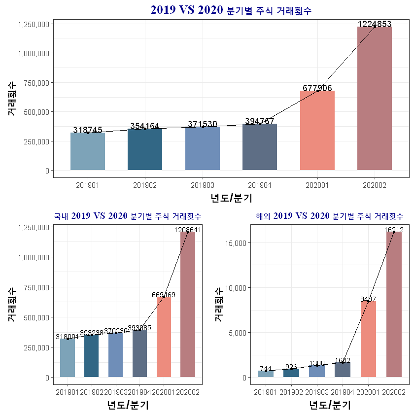

```r
# 분기별 주식 거래횟수 Graph
trd_freq_df <- trd_tot %>% group_by(trd_yQ) %>% summarise(sum_freq = n())
d <- trd_freq_df%>%
  data.frame() %>%
    ggplot( aes(x= factor(trd_yQ), y = sum_freq)) +
    geom_bar(stat="identity",width=.6, fill = col_1) +
    geom_line(aes(group = TRUE)) +
    geom_point(size = 1) +
    ylab('거래횟수') + xlab('년도/분기') +
    theme_bw() +
    ggtitle('2019 VS 2020 분기별 주식 거래횟수') +
    geom_text(aes(label = sum_freq), vjust = 0, color = "black") + theme_1 +
    scale_y_continuous(labels = scales::comma)+
theme(axis.title.x = element_text(size  = 15, face  = "bold", angle = 0, vjust = 0.5),
          axis.title.y = element_text(size  = 15, face  = "bold", angle = 90, vjust = 0.5),
          plot.title = element_text(family = "serif", face = "bold", hjust = 0.5, size = 15, color = "darkblue"))

# 분기별 주식 거래횟수 Graph (국내 vs 해외 비교)
trd_freq_df <- trd_tot %>% group_by(country,trd_yQ) %>% summarise(sum_freq = n())
d_kr <- trd_freq_df%>%
  data.frame() %>%
  filter(country == 'kr') %>%
  ggplot( aes(x= factor(trd_yQ), y = sum_freq)) +
  geom_bar(stat="identity",width=.6, fill = col_1) +
  geom_line(aes(group = TRUE)) +
  geom_point(size = 1) +
  ylab('거래횟수') + xlab('년도/분기') +
  theme_bw() +
  ggtitle('국내 2019 VS 2020 분기별 주식 거래횟수') +
  geom_text(aes(label = sum_freq), vjust = 0, color = "black",size = 3) + theme_1 +
  scale_y_continuous(labels = scales::comma) +
theme(axis.title.x = element_text(size  = 15, face  = "bold", angle = 0, vjust = 0.5),
          axis.title.y = element_text(size  = 15, face  = "bold", angle = 90, vjust = 0.5),
          plot.title = element_text(family = "serif", face = "bold", hjust = 0.5, size = 12, color = "darkblue"))


d_oss <- trd_freq_df%>%
  data.frame() %>%
  filter(country == 'oss') %>%
  ggplot( aes(x= factor(trd_yQ), y = sum_freq)) +
  geom_bar(stat="identity",width=.6, fill = col_1) +
  geom_line(aes(group = TRUE)) +
  geom_point(size = 1) +
  ylab('거래횟수') + xlab('년도/분기') +
  theme_bw() +
  ggtitle('해외 2019 VS 2020 분기별 주식 거래횟수') +
  geom_text(aes(label = sum_freq), vjust = 0, color = "black",size = 3) + theme_1 +
  scale_y_continuous(labels = scales::comma) +
theme(axis.title.x = element_text(size  = 15, face  = "bold", angle = 0, vjust = 0.5),
          axis.title.y = element_text(size  = 15, face  = "bold", angle = 90, vjust = 0.5),
          plot.title = element_text(family = "serif", face = "bold", hjust = 0.5, size = 12, color = "darkblue"))

grid.arrange(d_kr,d_oss,d,layout_matrix = lay)
```

- 분기별 거래총금액(=매수총금액+매도총금액)의 합 비교.

  실제 주식 거래에 있어 현금 흐름을 유추할 수 있다. 2020년 상반기가 전년 대비 거래총금액의 증가량과 증가율에서 모두 월등하게 더 높은 수치임을 확인할 수 있다. 이는 국내 투자와 해외 투자 모든 사항에도 적용된다.단, 2020년 1분기에 그 규모 자체는 국내 거래총금액이 더 크지만, 해외주식 거래총금액의 증가율이 더 높다는 것을 확인할 수 있다. 또한 2020년 1분기에 비해 2분기에 국내 투자의 증가율이 높다는 것을 통해, 2분기에서 국내 주식 시장의 현금 회전이 더 크다는 것을 파악할 수 있다.

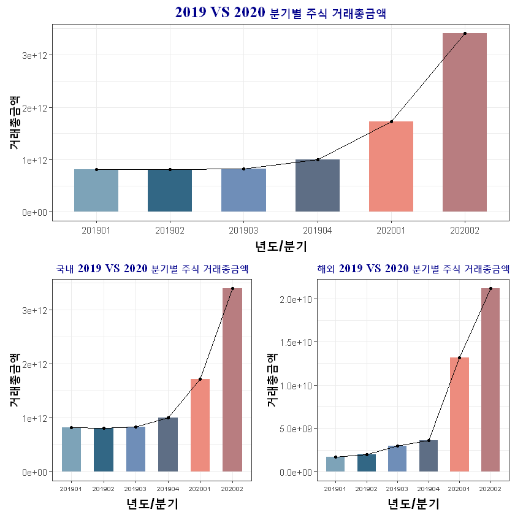

```r
# 분기별 주식 거래총금액 Graph
trd_totpr_df <- trd_tot %>% group_by(trd_yQ) %>% summarise(totpr = sum(tot_pr))
a <- trd_totpr_df%>%
  data.frame() %>%
    ggplot( aes(x= factor(trd_yQ), y = totpr)) +
    geom_bar(stat="identity",width=.6, fill = col_1) +
    geom_line(aes(group = TRUE)) +
    geom_point(size = 1) +
    ylab('거래총금액') + xlab('년도/분기') +
    theme_bw() +
    ggtitle('2019 VS 2020 분기별 주식 거래총금액') + theme_1+
    theme(axis.title.x = element_text(size  = 15, face  = "bold", angle = 0, vjust = 0.5),
          axis.title.y = element_text(size  = 15, face  = "bold", angle = 90, vjust = 0.5),
          plot.title = element_text(family = "serif", face = "bold", hjust = 0.5, size = 15, color = "darkblue"))

# 분기별 주식 거래총금액 Graph (국내 vs 해외 비교)
trd_totpr_df <- trd_tot %>% group_by(country,trd_yQ) %>% summarise(totpr = sum(tot_pr))
a_kr <- trd_totpr_df%>%
  data.frame() %>%
  filter(country == 'kr') %>%
  ggplot( aes(x= factor(trd_yQ), y = totpr)) +
  geom_bar(stat="identity",width=.6, fill = col_1) +
  geom_line(aes(group = TRUE)) +
  geom_point(size = 1) +
  ylab('거래총금액') + xlab('년도/분기') +
  theme_bw() +
  ggtitle('국내 2019 VS 2020 분기별 주식 거래총금액') + theme_1+
  theme(axis.title.x = element_text(size  = 15, face  = "bold", angle = 0, vjust = 0.5),
        axis.title.y = element_text(size  = 15, face  = "bold", angle = 90, vjust = 0.5),
        plot.title = element_text(family = "serif", face = "bold", hjust = 0.5, size = 12, color = "darkblue"),
       axis.text.x = element_text(size=6))



a_oss <- trd_totpr_df%>%
  data.frame() %>%
  filter(country == 'oss') %>%
  ggplot( aes(x= factor(trd_yQ), y = totpr)) +
  geom_bar(stat="identity",width=.6, fill = col_1) +
  geom_line(aes(group = TRUE)) +
  geom_point(size = 1) +
  ylab('거래총금액') + xlab('년도/분기') +
  theme_bw() +
  ggtitle('해외 2019 VS 2020 분기별 주식 거래총금액') + theme_1+
  theme(axis.title.x = element_text(size  = 15, face  = "bold", angle = 0, vjust = 0.5),
        axis.title.y = element_text(size  = 15, face  = "bold", angle = 90, vjust = 0.5),
        plot.title = element_text(family = "serif", face = "bold", hjust = 0.5, size = 12, color = "darkblue"),
       axis.text.x = element_text(size=6))

grid.arrange(a_kr,a_oss,a,layout_matrix = lay)
```

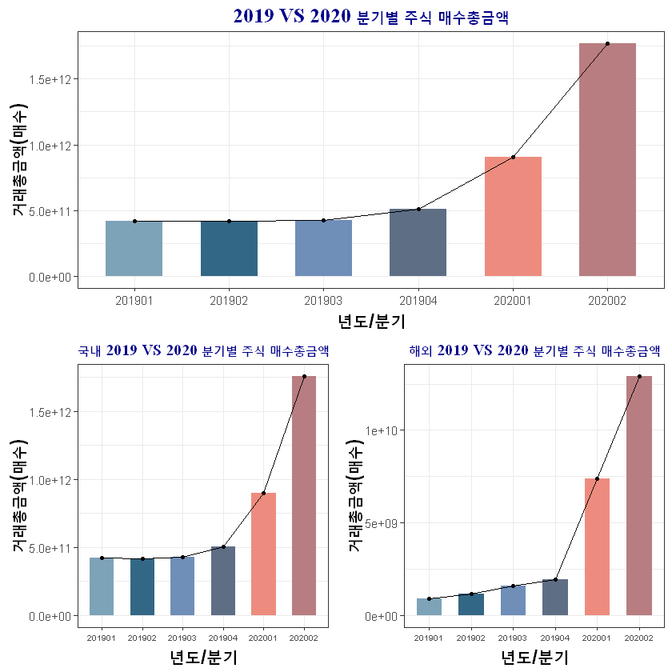

```r
# 분기별 주식 매수총금액 Graph
trd_totpr_sby_df <- trd_tot %>% group_by(sby_dit_cd,trd_yQ) %>% summarise(totpr = sum(tot_pr))
c <- trd_totpr_sby_df%>%
  data.frame() %>%
  filter(sby_dit_cd == 2) %>%
    ggplot( aes(x= factor(trd_yQ), y = totpr)) +
    geom_bar(stat="identity",width=.6, fill =col_1) +
  geom_line(aes(group = TRUE)) +
  geom_point(size = 1) +
    ylab('거래총금액(매수)') + xlab('년도/분기') +
    theme_bw() +
    ggtitle('2019 VS 2020 분기별 주식 매수총금액') + theme_1+
    theme(axis.title.x = element_text(size  = 15, face  = "bold", angle = 0, vjust = 0.5),
          axis.title.y = element_text(size  = 15, face  = "bold", angle = 90, vjust = 0.5),
          plot.title = element_text(family = "serif", face = "bold", hjust = 0.5, size = 15, color = "darkblue"))

# 분기별 주식 매수총금액 Graph (국내 vs 해외 비교)
trd_totpr_sby_df <- trd_tot %>% group_by(country,sby_dit_cd,trd_yQ) %>% summarise(totpr = sum(tot_pr))
c_kr <- trd_totpr_sby_df%>%
  data.frame() %>%
  filter(sby_dit_cd == 2 & country =='kr') %>%
  ggplot( aes(x= factor(trd_yQ), y = totpr)) +
  geom_bar(stat="identity",width=.6, fill = col_1) +
  geom_line(aes(group = TRUE)) +
  geom_point(size = 1) +
  ylab('거래총금액(매수)') + xlab('년도/분기') +
  theme_bw() +
  ggtitle('국내 2019 VS 2020 분기별 주식 매수총금액') + theme_1+
  theme(axis.title.x = element_text(size  = 15, face  = "bold", angle = 0, vjust = 0.5),
        axis.title.y = element_text(size  = 15, face  = "bold", angle = 90, vjust = 0.5),
        plot.title = element_text(family = "serif", face = "bold", hjust = 0.5, size = 12, color = "darkblue"),
       axis.text.x = element_text(size=6))

c_oss <- trd_totpr_sby_df%>%
  data.frame() %>%
  filter(sby_dit_cd == 2 & country =='oss') %>%
  ggplot( aes(x= factor(trd_yQ), y = totpr)) +
  geom_bar(stat="identity",width=.6, fill = col_1) +
  geom_line(aes(group = TRUE)) +
  geom_point(size = 1) +
  ylab('거래총금액(매수)') + xlab('년도/분기') +
  theme_bw() +
  ggtitle('해외 2019 VS 2020 분기별 주식 매수총금액') + theme_1+
  theme(axis.title.x = element_text(size  = 15, face  = "bold", angle = 0, vjust = 0.5),
        axis.title.y = element_text(size  = 15, face  = "bold", angle = 90, vjust = 0.5),
        plot.title = element_text(family = "serif", face = "bold", hjust = 0.5, size = 12, color = "darkblue"),
       axis.text.x = element_text(size=6))

grid.arrange(c_kr,c_oss,c,layout_matrix = lay)
```

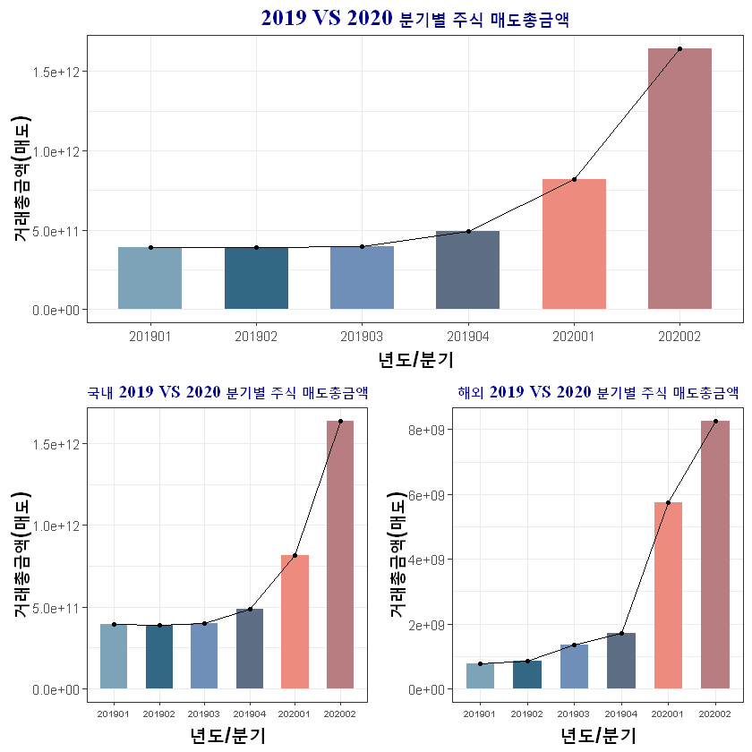

```r
# 분기별 주식 매도총금액 Graph
trd_totpr_sby_df <- trd_tot %>% group_by(sby_dit_cd,trd_yQ) %>% summarise(totpr = sum(tot_pr))
b <- trd_totpr_sby_df%>%
  data.frame() %>%
  filter(sby_dit_cd == 1) %>%
    ggplot( aes(x= factor(trd_yQ), y = totpr)) +
    geom_bar(stat="identity",width=.6, fill = col_1) +
   geom_line(aes(group = TRUE)) +
   geom_point(size = 1) +
    ylab('거래총금액(매도)') + xlab('년도/분기') +
    theme_bw() +
    ggtitle('2019 VS 2020 분기별 주식 매도총금액') + theme_1+
    theme(axis.title.x = element_text(size  = 15, face  = "bold", angle = 0, vjust = 0.5),
          axis.title.y = element_text(size  = 15, face  = "bold", angle = 90, vjust = 0.5),
          plot.title = element_text(family = "serif", face = "bold", hjust = 0.5, size = 15, color = "darkblue"))

# 분기별 주식 매도총금액 Graph (국내 vs 해외 비교)
trd_totpr_sby_df <- trd_tot %>% group_by(country,sby_dit_cd,trd_yQ) %>% summarise(totpr = sum(tot_pr))
b_kr <- trd_totpr_sby_df%>%
  data.frame() %>%
  filter(sby_dit_cd == 1 & country =='kr') %>%
  ggplot( aes(x= factor(trd_yQ), y = totpr)) +
  geom_bar(stat="identity",width=.6, fill = col_1) +
  geom_line(aes(group = TRUE)) +
  geom_point(size = 1) +
  ylab('거래총금액(매도)') + xlab('년도/분기') +
  theme_bw() +
  ggtitle('국내 2019 VS 2020 분기별 주식 매도총금액') + theme_1+
  theme(axis.title.x = element_text(size  = 15, face  = "bold", angle = 0, vjust = 0.5),
        axis.title.y = element_text(size  = 15, face  = "bold", angle = 90, vjust = 0.5),
        plot.title = element_text(family = "serif", face = "bold", hjust = 0.5, size = 12, color = "darkblue"),
       axis.text.x = element_text(size=6))

b_oss <- trd_totpr_sby_df%>%
  data.frame() %>%
  filter(sby_dit_cd == 1 & country =='oss') %>%
  ggplot( aes(x= factor(trd_yQ), y = totpr)) +
  geom_bar(stat="identity",width=.6, fill = col_1) +
  geom_line(aes(group = TRUE)) +
  geom_point(size = 1) +
  ylab('거래총금액(매도)') + xlab('년도/분기') +
  theme_bw() +
  ggtitle('해외 2019 VS 2020 분기별 주식 매도총금액') + theme_1 +
  theme(axis.title.x = element_text(size  = 15, face  = "bold", angle = 0, vjust = 0.5),
        axis.title.y = element_text(size  = 15, face  = "bold", angle = 90, vjust = 0.5),
        plot.title = element_text(family = "serif", face = "bold", hjust = 0.5, size = 12, color = "darkblue"),
       axis.text.x = element_text(size=6))

grid.arrange(b_kr,b_oss,b,layout_matrix = lay)
```

## ▶ Finding (a): 2019년에 비해 2020년에 주식에 대한 관심, 규모, 거래 모두 월등하게 증가.

### (b) 신규 투자자 진입

과거대비 2020년 {신규 계좌의 수, 신규 계좌 생성자 수, 첫거래 시행 투자자 수}면에서 모두 급격한 증가를 확인할 수 있다. 2020년 상반기에 신규고객의 규모가 어느 정도인지 살펴볼 수 있다.

- 분기별 신규 계좌의 수 비교:

```r
opn_act_df <- act_info %>% filter(opn_yQ %in% c(201901,201902,201903,201904,202001,202002)) %>%
  filter(act_tot_count < 15) %>%
  group_by(opn_yQ) %>% summarise(opn_act_n = n()) %>% data.frame()
a <- opn_act_df %>%
  ggplot(aes(x= factor(opn_yQ), y = opn_act_n)) +
    geom_bar(stat="identity",width=.6,fill = col_1) +
    geom_line(aes(group = TRUE)) +
    geom_point(size = 1) +
    ylab('신규계좌 수') + xlab('년도/분기') +
    theme_bw() + geom_text(aes(label = opn_act_n), vjust = 2, color = "black", size=3)+
    ggtitle('2019 VS 2020 분기별 신규 계좌 수') + theme_1 +
  theme(axis.title.x = element_text(size  = 15, face  = "bold", angle = 0, vjust = 0.5),
        axis.title.y = element_text(size  = 15, face  = "bold", angle = 90, vjust = 0.5),
        plot.title = element_text(family = "serif", face = "bold", hjust = 0.5, size = 12, color = "darkblue"),
       axis.text.x = element_text(size=6))
```

- 분기별 신규생성 계좌의 소유자 수 비교:

```r
opn_cus_df <- act_info %>% filter(opn_yQ %in% c(201901,201902,201903,201904,202001,202002)) %>%
  filter(act_tot_count < 15) %>%
  group_by(opn_yQ) %>% summarise(opn_cus_n = n_distinct(cus_id)) %>% data.frame()
b <- opn_cus_df %>%
  ggplot(aes(x= factor(opn_yQ), y = opn_cus_n)) +
    geom_bar(stat="identity",width=.6,fill = col_1) +
    geom_line(aes(group = TRUE)) +
    geom_point(size = 1) +
    ylab('신규계좌 생성자 수') + xlab('년도/분기') +
    theme_bw() + geom_text(aes(label = opn_cus_n), vjust = 2, color = "black", size=3)+
    ggtitle('2019 VS 2020 분기별 신규계좌 생성자 수') + theme_1+
  theme(axis.title.x = element_text(size  = 15, face  = "bold", angle = 0, vjust = 0.5),
        axis.title.y = element_text(size  = 15, face  = "bold", angle = 90, vjust = 0.5),
        plot.title = element_text(family = "serif", face = "bold", hjust = 0.5, size = 12, color = "darkblue"),
       axis.text.x = element_text(size=6))
```

- 분기별 첫거래시행 투자자 수:

```r
first_trd_cus <- trd_tot %>% filter(trd_yQ %in% c(201901,201902,201903,201904,202001,202002)) %>%
  group_by(trd_yQ) %>% summarise(first_trd_cus = n_distinct(cus_id))
c <- first_trd_cus %>%
  ggplot(aes(x= factor(trd_yQ), y = first_trd_cus)) +
    geom_bar(stat="identity",width=.6,fill = col_1) +
    geom_line(aes(group = TRUE)) +
    geom_point(size = 1) +
    ylab('첫거래시행 투자자 수') + xlab('년도/분기') +
    theme_bw() +
    geom_text(aes(label = first_trd_cus), vjust = 2, color = "black", size=3)+
    ggtitle('2019 VS 2020 분기별 첫거래시행 투자자 수') +
   theme_1 +
  theme(axis.title.x = element_text(size  = 15, face  = "bold", angle = 0, vjust = 0.5),
        axis.title.y = element_text(size  = 15, face  = "bold", angle = 90, vjust = 0.5),
        plot.title = element_text(family = "serif", face = "bold", hjust = 0.5, size = 12, color = "darkblue"),
       axis.text.x = element_text(size=6))
```

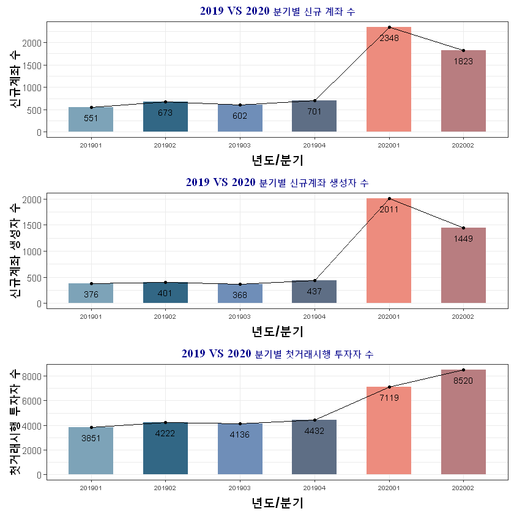

```r
grid.arrange(a,b,c,nrow=3,ncol=1)
```

## ▶ Finding (b):과거대비 2020년에 주식 신규 투자자가 월등하게 증가

### (YZ세대의 주식시장 등장)

## "2020년 주식의 규모와 성장에 큰 기여를 한 대상은 누구인가?"

인구통계학적 요소와 주문방식을 살펴보고, 2020년에 차지하는 비중이 커진 YZ세대집중해야 한다.

### (a) YZ세대 등장에 대한 분석: 이제 새로 떠오르는, 주요 고객이 될 YZ세대에 집중해야 한다.

과거대비 2020년 {성별, 연령(세대)}면에서 유의미한 차이가 발생하는지를 확인한다.

- 성별:

  기간에 따른 성별 비율에는 유의미한 차이는 존재하지 않았다.

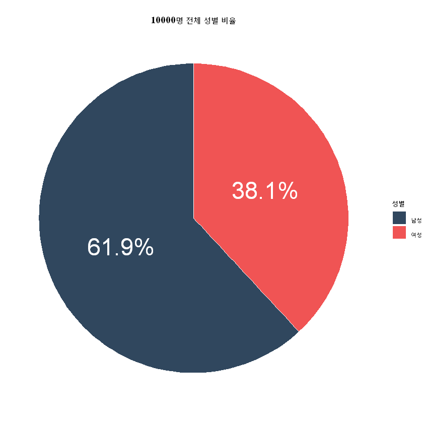

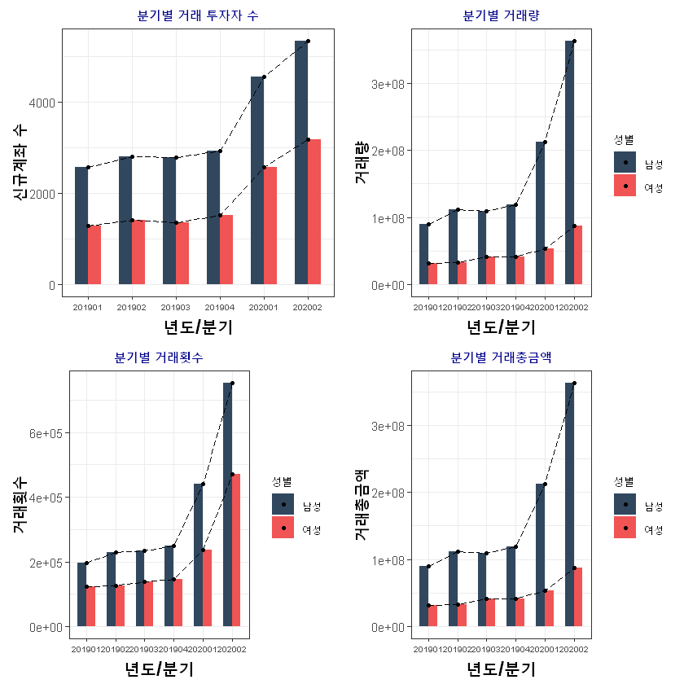

```r
sex_table <- table(cus_info$sex_dit_cd) %>%
  data.frame() %>%
  rename(c(Sex = "Var1", count = "Freq")) %>%
  arrange(desc('Sex')) %>%
  mutate(per = round(100*(count/sum(count)),1)) %>%
  mutate(ypos = cumsum(per) - 0.5*per)

ggplot(sex_table, aes(x="", y=per, fill = Sex )) +
    geom_bar(width = 1, stat='identity', color = 'white') +
    coord_polar("y", start = 0) +
    geom_text(aes(label = paste0(per,'%')),position = position_stack(vjust = 0.5),color = "white",size = 10) +
    scale_fill_manual(values = c('#30475E','#F05454'), name="성별",breaks=c(1, 2),labels=c("남성", "여성")) + theme_void() +
    ggtitle('10000명 전체 성별 비율') +
    theme(plot.title = element_text(family = "serif", face = "bold", hjust = 0.5, size = 12, color = "black"),
          text =element_text(face = "bold"))

sex_trd_df <- trd_tot %>% group_by(sex_dit_cd, trd_yQ) %>% summarise(cus_count = n_distinct(cus_id))
a <- sex_trd_df %>%
  ggplot(aes(x= factor(trd_yQ), y = cus_count, fill = factor(sex_dit_cd))) +
    geom_bar(stat="identity",width=.6, position = 'dodge') +
    geom_line(aes(group = factor(sex_dit_cd)),size = 0.4, linetype="longdash") +
    geom_point(size = 1) +    ylab('거래횟수') + xlab('년도/분기') +
    ylab('신규계좌 수') + xlab('년도/분기') +
    theme_bw() +
    ggtitle('분기별 거래 투자자 수') + theme_1 +
  scale_fill_manual(values = c('#30475E','#F05454'),
                    name="성별",breaks=c(1, 2),labels=c("남성", "여성")) +
  theme(axis.title.x = element_text(size  = 15, face  = "bold", angle = 0, vjust = 0.5),
        axis.title.y = element_text(size  = 15, face  = "bold", angle = 90, vjust = 0.5),
        plot.title = element_text(family = "serif", face = "bold", hjust = 0.5, size = 12, color = "darkblue"),
       axis.text.x = element_text(size=6))

sex_qty_df <- trd_tot %>% group_by(sex_dit_cd, trd_yQ) %>% summarise(sum_qty = sum(cns_qty))
b <- sex_qty_df %>%
  ggplot(aes(x= factor(trd_yQ), y = sum_qty, fill = factor(sex_dit_cd))) +
    geom_bar(stat="identity",width=.6, position = 'dodge') +
  geom_line(aes(group = factor(sex_dit_cd)),size = 0.4, linetype="longdash") +
  geom_point(size = 1) +    ylab('거래횟수') + xlab('년도/분기') +
    ylab('거래량') + xlab('년도/분기') +
    theme_bw() +
    ggtitle('분기별 거래량') +
  theme(axis.title.x = element_text(size  = 15, face  = "bold", angle = 0, vjust = 0.5),
        axis.title.y = element_text(size  = 15, face  = "bold", angle = 90, vjust = 0.5),
        plot.title = element_text(family = "serif", face = "bold", hjust = 0.5, size = 12, color = "darkblue"),
        axis.text.x = element_text(size=6)) +
  scale_fill_manual(values = c('#30475E','#F05454'),
                    name="성별",breaks=c(1, 2),labels=c("남성", "여성"))

sex_freq_df <- trd_tot %>% group_by(sex_dit_cd, trd_yQ) %>% summarise(freq_count = n())
c <- sex_freq_df %>%
  ggplot(aes(x= factor(trd_yQ), y = freq_count, fill = factor(sex_dit_cd) )) +
    geom_bar(stat="identity",width=.6, position = 'dodge')  +
  scale_fill_manual(values = c('#30475E','#F05454'),
                    name="성별",breaks=c(1, 2),labels=c("남성", "여성")) +
  geom_line(aes(group = factor(sex_dit_cd)),size = 0.4, linetype="longdash") +
  geom_point(size = 1) +    ylab('거래횟수') + xlab('년도/분기') +
    theme_bw() +
  theme(axis.title.x = element_text(size  = 15, face  = "bold", angle = 0, vjust = 0.5),
       axis.title.y = element_text(size  = 15, face  = "bold", angle = 90, vjust = 0.5),
       plot.title = element_text(family = "serif", face = "bold", hjust = 0.5, size = 12, color = "darkblue"),
        axis.text.x = element_text(size=6)) +
    ggtitle('분기별 거래횟수')

sex_totpr_df <- trd_tot %>% group_by(sex_dit_cd, trd_yQ) %>% summarise(totpr = sum(tot_pr))
d <- sex_qty_df %>%
  ggplot(aes(x= factor(trd_yQ), y = sum_qty, fill = factor(sex_dit_cd))) +
    geom_bar(stat="identity",width=.6, position = 'dodge') +
  geom_line(aes(group = factor(sex_dit_cd)),size = 0.4, linetype="longdash") +
  geom_point(size = 1) +    ylab('거래횟수') + xlab('년도/분기') +
  scale_fill_manual(values = c('#30475E','#F05454'),
                    name="성별",breaks=c(1, 2),labels=c("남성", "여성")) +
    ylab('거래총금액') + xlab('년도/분기') +
    theme_bw() +
    ggtitle('분기별 거래총금액') +
    theme(axis.title.x = element_text(size  = 15, face  = "bold", angle = 0, vjust = 0.5),
          axis.title.y = element_text(size  = 15, face  = "bold", angle = 90, vjust = 0.5),
          plot.title = element_text(family = "serif", face = "bold", hjust = 0.5, size = 12, color = "darkblue"),
          axis.text.x = element_text(size=6))

grid.arrange(a,b,c,d,nrow = 2,ncol = 2)
```

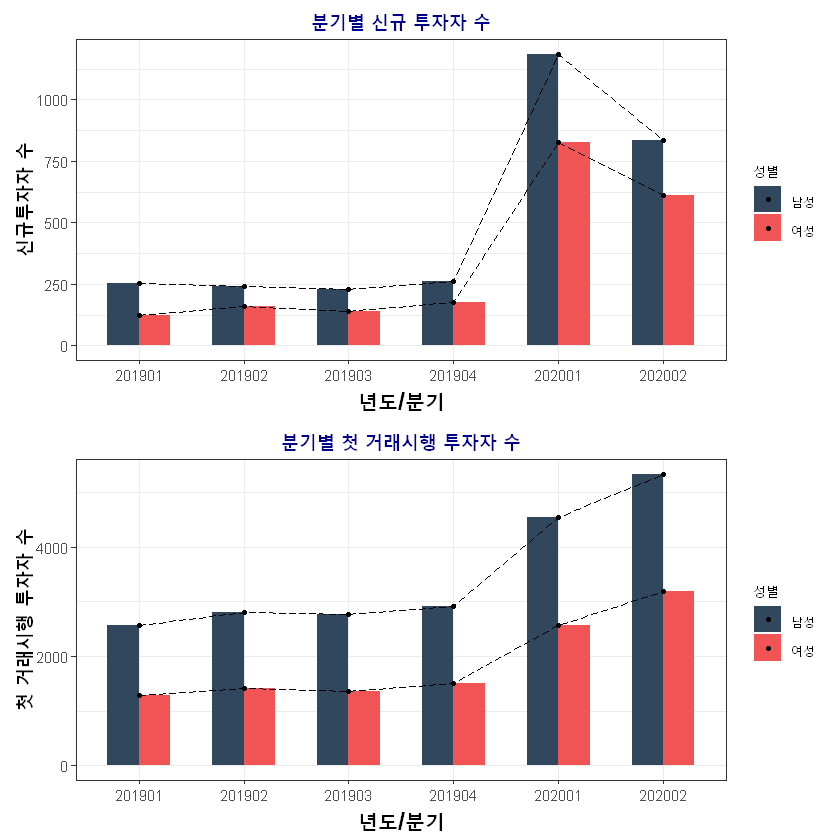

```r
opn_cus_df <- act_info %>% filter(opn_yQ %in% c(201901,201902,201903,201904,202001,202002)) %>%
  filter(act_tot_count < 15) %>%
  group_by(sex_dit_cd,opn_yQ) %>% summarise(opn_cus_n = n_distinct(cus_id)) %>% data.frame()
a <- opn_cus_df %>%
  ggplot(aes(x= factor(opn_yQ), y = opn_cus_n, fill = factor(sex_dit_cd))) +
    geom_bar(stat="identity",width=.6,position = 'dodge') +
  geom_line(aes(group = factor(sex_dit_cd)),size = 0.4, linetype="longdash") +
  geom_point(size = 1) +    ylab('거래횟수') + xlab('년도/분기') +
  scale_fill_manual(values = c('#30475E','#F05454'),
                    name="성별",breaks=c(1, 2),labels=c("남성", "여성")) +
    ylab('신규투자자 수') + xlab('년도/분기') +
    theme_bw() +
    ggtitle('분기별 신규 투자자 수') +
    theme(axis.title.x = element_text(size  = 15, face  = "bold", angle = 0, vjust = 0.5),
          axis.title.y = element_text(size  = 15, face  = "bold", angle = 90, vjust = 0.5),
          plot.title = element_text(family = "serif", face = "bold", hjust = 0.5, size = 15, color = "darkblue"))


first_cus_df <- trd_tot %>% filter(trd_yQ %in% c(201901,201902,201903,201904,202001,202002)) %>%
  group_by(sex_dit_cd,trd_yQ) %>% summarise(first_cus_n = n_distinct(cus_id)) %>% data.frame()
b <- first_cus_df %>%
  ggplot(aes(x= factor(trd_yQ), y = first_cus_n, fill = factor(sex_dit_cd))) +
    geom_bar(stat="identity",width=.6,position = 'dodge') +
  geom_line(aes(group = factor(sex_dit_cd)),size = 0.4, linetype="longdash") +
  geom_point(size = 1) +    ylab('거래횟수') + xlab('년도/분기') +
  scale_fill_manual(values = c('#30475E','#F05454'),
                    name="성별",breaks=c(1, 2),labels=c("남성", "여성")) +
    ylab('첫 거래시행 투자자 수') + xlab('년도/분기') +
    theme_bw() +
    ggtitle('분기별 첫 거래시행 투자자 수') +
    theme(axis.title.x = element_text(size  = 15, face  = "bold", angle = 0, vjust = 0.5),
          axis.title.y = element_text(size  = 15, face  = "bold", angle = 90, vjust = 0.5),
          plot.title = element_text(family = "serif", face = "bold", hjust = 0.5, size = 15, color = "darkblue"))


grid.arrange(a,b,nrow = 2,ncol = 1)
```

- 세대:

  2019년대비 2020년 상반기의 {신규 투자자 수}의 증가율은 X, Y, Z세대가 모두 유사하였으나, {거래시행 투자자수, 거래횟수, 거래량, 총거래금액} 증가율이 YZ세대는 X세대에 비해 월등하게 높았다. 따라서 YZ세대가 2020년 상반기의 주식시장의 규모 성장을 견인하는 데에 중추적인 역할을 했다고 볼 수 있다.

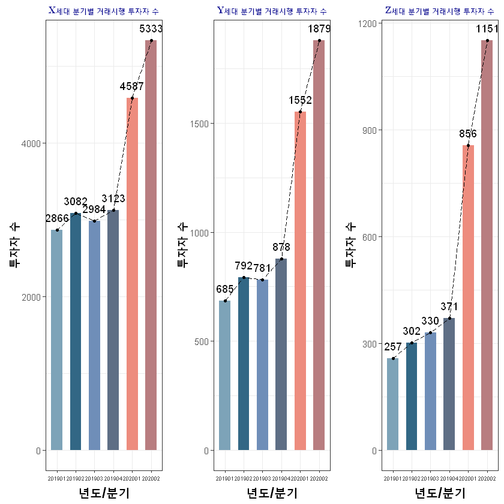

```r
## 분기별 주식 거래시행한 투자자 수

trd_cus_df <- trd_tot %>% filter(trd_yQ %in% c(201901,201902,201903,201904,202001,202002)) %>%
  group_by(age_group,trd_yQ) %>% summarise(trd_cus_n = n_distinct(cus_id)) %>% data.frame()

a <- trd_cus_df %>%
  filter(age_group =='X') %>%
  ggplot(aes(x= factor(trd_yQ), y = trd_cus_n)) +
    geom_bar(stat="identity",width=.6,fill = col_1) +
    ylab('투자자 수') + xlab('년도/분기') +
    theme_bw() +
    geom_text(aes(label = trd_cus_n), vjust = -1, color = "black") +
  geom_line(group = TRUE, linetype="longdash") +
  geom_point(size = 1) +
    ggtitle('X세대 분기별 거래시행 투자자 수') +
    theme(axis.title.x = element_text(size  = 15, face  = "bold", angle = 0, vjust = 0.5),
          axis.title.y = element_text(size  = 15, face  = "bold", angle = 90, vjust = 0.5),
          plot.title = element_text(family = "serif", face = "bold", hjust = 0.5, size = 10, color = "darkblue"),
         axis.text.x = element_text(size=5.5))

b <- trd_cus_df %>%
  filter(age_group =='Y') %>%
  ggplot(aes(x= factor(trd_yQ), y = trd_cus_n)) +
    geom_bar(stat="identity",width=.6,fill = col_1) +
    ylab('투자자 수') + xlab('년도/분기') +
    theme_bw() +
  geom_text(aes(label = trd_cus_n), vjust = -1, color = "black") +
  geom_line(group = TRUE, linetype="longdash") +
  geom_point(size = 1) +
    ggtitle('Y세대 분기별 거래시행 투자자 수') + theme_1+
    theme(axis.title.x = element_text(size  = 15, face  = "bold", angle = 0, vjust = 0.5),
          axis.title.y = element_text(size  = 15, face  = "bold", angle = 90, vjust = 0.5),
          plot.title = element_text(family = "serif", face = "bold", hjust = 0.5, size = 10, color = "darkblue"),
         axis.text.x = element_text(size=5.5))


c <- trd_cus_df %>%
  filter(age_group =='Z') %>%
  ggplot(aes(x= factor(trd_yQ), y = trd_cus_n)) +
    geom_bar(stat="identity",width=.6,fill = col_1) +
    ylab('투자자 수') + xlab('년도/분기') +
  geom_text(aes(label = trd_cus_n), vjust = -1, color = "black") +
  geom_line(group = TRUE, linetype="longdash") +
  geom_point(size = 1) +
    theme_bw() +
    ggtitle('Z세대 분기별 거래시행 투자자 수') + theme_1+
    theme(axis.title.x = element_text(size  = 15, face  = "bold", angle = 0, vjust = 0.5),
          axis.title.y = element_text(size  = 15, face  = "bold", angle = 90, vjust = 0.5),
          plot.title = element_text(family = "serif", face = "bold", hjust = 0.5, size = 10, color = "darkblue"),
         axis.text.x = element_text(size=5.5))

grid.arrange(a,b,c,nrow = 1,ncol = 3)
```

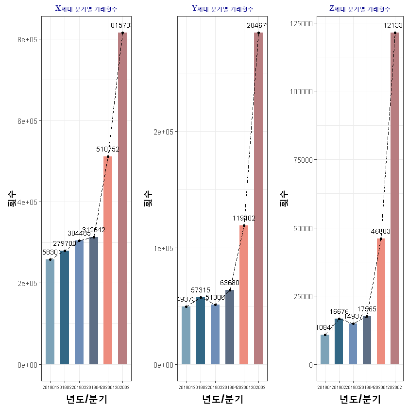

```r
### 분기별 주식 거래 횟수

freq_cus_df <- trd_tot %>% filter(trd_yQ %in% c(201901,201902,201903,201904,202001,202002)) %>%
  group_by(age_group,trd_yQ) %>% summarise(freq_cus_n = n()) %>% data.frame()

a <- freq_cus_df %>%
  filter(age_group =='X') %>%
  ggplot(aes(x= factor(trd_yQ), y = freq_cus_n)) +
    geom_bar(stat="identity",width=.6,fill = col_1) +
  geom_text(aes(label = freq_cus_n), vjust = -1, color = "black", size=3) +
  geom_line(group = TRUE, linetype="longdash") +
  geom_point(size = 1) +
    ylab('횟수') + xlab('년도/분기') +
    theme_bw() +
    ggtitle('X세대 분기별 거래횟수') + theme_1+
    theme(axis.title.x = element_text(size  = 15, face  = "bold", angle = 0, vjust = 0.5),
          axis.title.y = element_text(size  = 15, face  = "bold", angle = 90, vjust = 0.5),
          plot.title = element_text(family = "serif", face = "bold", hjust = 0.5, size = 10, color = "darkblue"),
         axis.text.x = element_text(size=5.5))


b <- freq_cus_df %>%
  filter(age_group =='Y') %>%
  ggplot(aes(x= factor(trd_yQ), y = freq_cus_n)) +
    geom_bar(stat="identity",width=.6,fill = col_1) +
  geom_text(aes(label = freq_cus_n), vjust = -1, color = "black", size=3) +
  geom_line(group = TRUE, linetype="longdash") +
  geom_point(size = 1) +
   ylab('횟수') + xlab('년도/분기') +
    theme_bw() +
    ggtitle('Y세대 분기별 거래횟수') + theme_1+
    theme(axis.title.x = element_text(size  = 15, face  = "bold", angle = 0, vjust = 0.5),
          axis.title.y = element_text(size  = 15, face  = "bold", angle = 90, vjust = 0.5),
          plot.title = element_text(family = "serif", face = "bold", hjust = 0.5, size = 10, color = "darkblue"),
         axis.text.x = element_text(size=5.5))

c <- freq_cus_df %>%
  filter(age_group =='Z') %>%
  ggplot(aes(x= factor(trd_yQ), y = freq_cus_n)) +
    geom_bar(stat="identity",width=.6,fill = col_1) +
  geom_text(aes(label = freq_cus_n), vjust = -1, color = "black", size=3) +
  geom_line(group = TRUE, linetype="longdash") +
  geom_point(size = 1) +
    ylab('횟수') + xlab('년도/분기') +
    theme_bw() +
    ggtitle('Z세대 분기별 거래횟수') + theme_1+
    theme(axis.title.x = element_text(size  = 15, face  = "bold", angle = 0, vjust = 0.5),
          axis.title.y = element_text(size  = 15, face  = "bold", angle = 90, vjust = 0.5),
          plot.title = element_text(family = "serif", face = "bold", hjust = 0.5, size = 10, color = "darkblue"),
         axis.text.x = element_text(size=5.5))

grid.arrange(a,b,c,nrow = 1,ncol = 3)
```

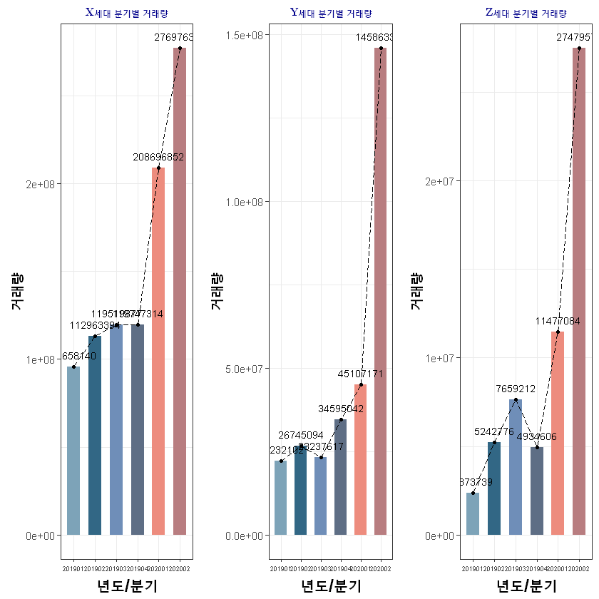

```r
## 분기별 주식 거래량

qty_cus_df <- trd_tot %>% filter(trd_yQ %in% c(201901,201902,201903,201904,202001,202002)) %>%
  group_by(age_group,trd_yQ) %>% summarise(sum_qty = sum(cns_qty)) %>% data.frame()

a <- qty_cus_df %>%
  filter(age_group =='X') %>%
  ggplot(aes(x= factor(trd_yQ), y = sum_qty)) +
  geom_bar(stat="identity",width=.6,fill = col_1) +
  geom_text(aes(label = sum_qty), vjust = -1, color = "black",size=3) +
  geom_line(group = TRUE, linetype="longdash") +
  geom_point(size = 1) +
  ylab('거래량') + xlab('년도/분기') +
  theme_bw() +
  ggtitle('X세대 분기별 거래량') + theme_1+
    theme(axis.title.x = element_text(size  = 15, face  = "bold", angle = 0, vjust = 0.5),
          axis.title.y = element_text(size  = 15, face  = "bold", angle = 90, vjust = 0.5),
          plot.title = element_text(family = "serif", face = "bold", hjust = 0.5, size = 10, color = "darkblue"),
         axis.text.x = element_text(size=5.5))

b <- qty_cus_df %>%
  filter(age_group =='Y') %>%
  ggplot(aes(x= factor(trd_yQ), y = sum_qty)) +
  geom_bar(stat="identity",width=.6,fill = col_1) +
  geom_text(aes(label = sum_qty), vjust = -1, color = "black",size=3) +
  geom_line(group = TRUE, linetype="longdash") +
  geom_point(size = 1) +
  ylab('거래량') + xlab('년도/분기') +
  theme_bw() +
  ggtitle('Y세대 분기별 거래량') + theme_1+
    theme(axis.title.x = element_text(size  = 15, face  = "bold", angle = 0, vjust = 0.5),
          axis.title.y = element_text(size  = 15, face  = "bold", angle = 90, vjust = 0.5),
          plot.title = element_text(family = "serif", face = "bold", hjust = 0.5, size = 10, color = "darkblue"),
         axis.text.x = element_text(size=5.5))



c <- qty_cus_df %>%
  filter(age_group =='Z') %>%
  ggplot(aes(x= factor(trd_yQ), y = sum_qty)) +
  geom_bar(stat="identity",width=.6,fill = col_1) +
  geom_text(aes(label = sum_qty), vjust = -1, color = "black",size=3) +
  geom_line(group = TRUE, linetype="longdash") +
  geom_point(size = 1) +
  ylab('거래량') + xlab('년도/분기') +
  theme_bw() +
  ggtitle('Z세대 분기별 거래량') + theme_1+
    theme(axis.title.x = element_text(size  = 15, face  = "bold", angle = 0, vjust = 0.5),
          axis.title.y = element_text(size  = 15, face  = "bold", angle = 90, vjust = 0.5),
          plot.title = element_text(family = "serif", face = "bold", hjust = 0.5, size = 10, color = "darkblue"),
         axis.text.x = element_text(size=5.5))


grid.arrange(a,b,c,nrow = 1,ncol = 3)
```

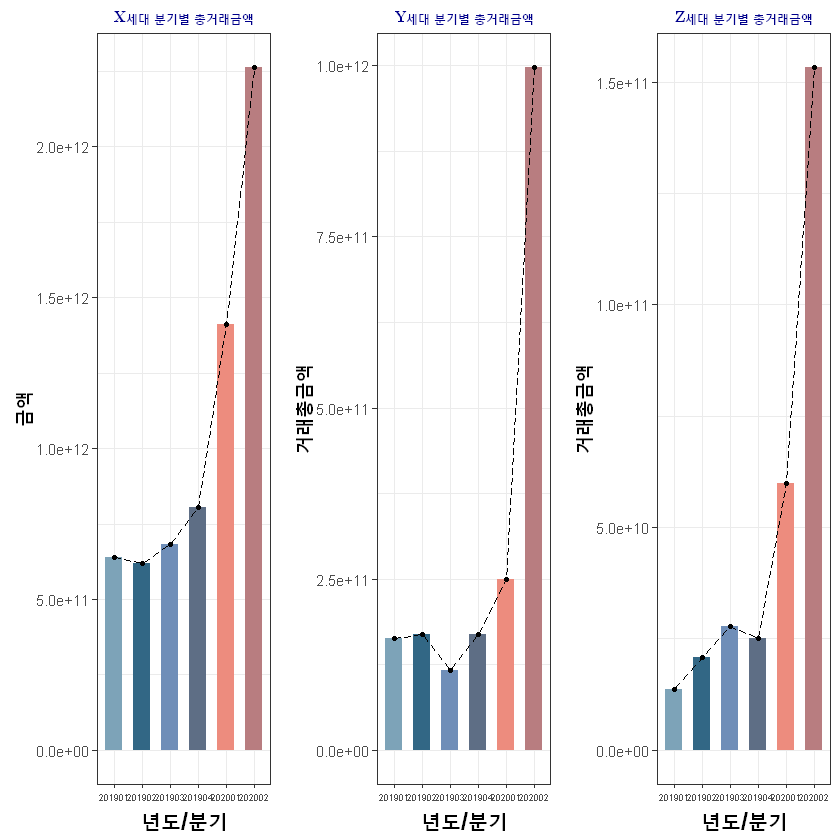

```r
## 분기별 주식 거래 총금액

totpr_cus_df <- trd_tot %>% filter(trd_yQ %in% c(201901,201902,201903,201904,202001,202002)) %>%
  group_by(age_group,trd_yQ) %>% summarise(sum_totpr = sum(tot_pr)) %>% data.frame()

a <- totpr_cus_df %>%
  filter(age_group =='X') %>%
  ggplot(aes(x= factor(trd_yQ), y = sum_totpr)) +
  geom_bar(stat="identity",width=.6,fill = col_1) +
  geom_line(group = TRUE, linetype="longdash") +
  geom_point(size = 1) +
  ylab('금액') + xlab('년도/분기') +
  theme_bw() +
  ggtitle('X세대 분기별 총거래금액') + theme_1+
    theme(axis.title.x = element_text(size  = 15, face  = "bold", angle = 0, vjust = 0.5),
          axis.title.y = element_text(size  = 15, face  = "bold", angle = 90, vjust = 0.5),
          plot.title = element_text(family = "serif", face = "bold", hjust = 0.5, size = 10, color = "darkblue"),
         axis.text.x = element_text(size=5.5))


b <- totpr_cus_df %>%
  filter(age_group =='Y') %>%
  ggplot(aes(x= factor(trd_yQ), y = sum_totpr)) +
  geom_bar(stat="identity",width=.6,fill = col_1) +
  geom_line(group = TRUE, linetype="longdash") +
  geom_point(size = 1) +
  ylab('거래총금액') + xlab('년도/분기') +
  theme_bw() +
  ggtitle('Y세대 분기별 총거래금액') + theme_1+
    theme(axis.title.x = element_text(size  = 15, face  = "bold", angle = 0, vjust = 0.5),
          axis.title.y = element_text(size  = 15, face  = "bold", angle = 90, vjust = 0.5),
          plot.title = element_text(family = "serif", face = "bold", hjust = 0.5, size = 10, color = "darkblue"),
         axis.text.x = element_text(size=5.5))


c <- totpr_cus_df %>%
  filter(age_group =='Z') %>%
  ggplot(aes(x= factor(trd_yQ), y = sum_totpr)) +
  geom_bar(stat="identity",width=.6,fill = col_1) +
  geom_line(group = TRUE, linetype="longdash") +
  geom_point(size = 1) +
  ylab('거래총금액') + xlab('년도/분기') +
  theme_bw() +
  ggtitle('Z세대 분기별 총거래금액') + theme_1+
    theme(axis.title.x = element_text(size  = 15, face  = "bold", angle = 0, vjust = 0.5),
          axis.title.y = element_text(size  = 15, face  = "bold", angle = 90, vjust = 0.5),
          plot.title = element_text(family = "serif", face = "bold", hjust = 0.5, size = 10, color = "darkblue"),
         axis.text.x = element_text(size=5.5))


grid.arrange(a,b,c,nrow = 1,ncol = 3)
```

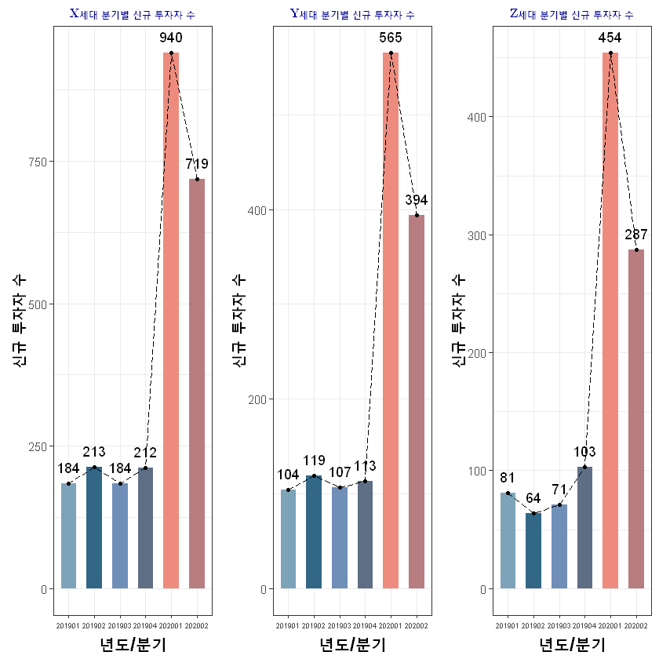

```r
# 신규 고객 수

opn_cus_df <- act_info %>% filter(opn_yQ %in% c(201901,201902,201903,201904,202001,202002)) %>%
  filter(act_tot_count < 15) %>%
  group_by(age_group,opn_yQ) %>% summarise(opn_cus_n = n_distinct(cus_id)) %>% data.frame()

a <- opn_cus_df %>%
  filter(age_group =='X') %>%
  ggplot(aes(x= factor(opn_yQ), y = opn_cus_n)) +
    geom_bar(stat="identity",width=.6,fill = col_1) +
  geom_text(aes(label = opn_cus_n), vjust = -1, color = "black") +
  geom_line(group = TRUE, linetype="longdash") +
  geom_point(size = 1) +
    ylab('신규 투자자 수') + xlab('년도/분기') +
    theme_bw() +
    ggtitle('X세대 분기별 신규 투자자 수') + theme_1+
    theme(axis.title.x = element_text(size  = 15, face  = "bold", angle = 0, vjust = 0.5),
          axis.title.y = element_text(size  = 15, face  = "bold", angle = 90, vjust = 0.5),
          plot.title = element_text(family = "serif", face = "bold", hjust = 0.5, size = 10, color = "darkblue"),
         axis.text.x = element_text(size=5.5))


b <- opn_cus_df %>%
  filter(age_group =='Y') %>%
  ggplot(aes(x= factor(opn_yQ), y = opn_cus_n)) +
    geom_bar(stat="identity",width=.6,fill = col_1) +
  geom_text(aes(label = opn_cus_n), vjust = -1, color = "black") +
  geom_line(group = TRUE, linetype="longdash") +
  geom_point(size = 1) +
    ylab('신규 투자자 수') + xlab('년도/분기') +
    theme_bw() +
    ggtitle('Y세대 분기별 신규 투자자 수') + theme_1+
    theme(axis.title.x = element_text(size  = 15, face  = "bold", angle = 0, vjust = 0.5),
          axis.title.y = element_text(size  = 15, face  = "bold", angle = 90, vjust = 0.5),
          plot.title = element_text(family = "serif", face = "bold", hjust = 0.5, size = 10, color = "darkblue"),
         axis.text.x = element_text(size=5.5))


c <- opn_cus_df %>%
  filter(age_group =='Z') %>%
  ggplot(aes(x= factor(opn_yQ), y = opn_cus_n)) +
    geom_bar(stat="identity",width=.6,fill = col_1) +
  geom_text(aes(label = opn_cus_n), vjust = -1, color = "black") +
  geom_line(group = TRUE, linetype="longdash") +
  geom_point(size = 1) +
    ylab('신규 투자자 수') + xlab('년도/분기') +
    theme_bw() +
    ggtitle('Z세대 분기별 신규 투자자 수') + theme_1+
    theme(axis.title.x = element_text(size  = 15, face  = "bold", angle = 0, vjust = 0.5),
          axis.title.y = element_text(size  = 15, face  = "bold", angle = 90, vjust = 0.5),
          plot.title = element_text(family = "serif", face = "bold", hjust = 0.5, size = 10, color = "darkblue"),
         axis.text.x = element_text(size=5.5))


grid.arrange(a,b,c,nrow = 1,ncol = 3)
```

- 실제 거래를 시행한 투자자 수에 대해 2019년과 2020년의 X, Y, Z 각 세대의 비율을 살펴본 결과, YZ세대의 비중이 이전에 비해 약 8% 가량 증가함을 알 수 있다. 이를 통해 2019년에 비해 2020년에 YZ세대가 주식 투자에 참여하는 비중이 커졌음을 알 수 있다.

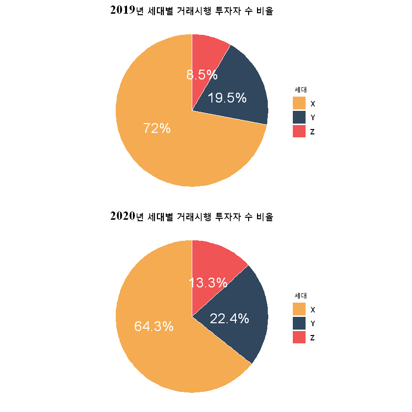

```r
## 2019년 2020년 세대별 거래 비율 확인

trd_age_table <- trd_tot %>% filter(age_group != 'B' & trd_year == 2019) %>%
  group_by(age_group) %>%
  summarise(cus_n = n_distinct(cus_id)) %>% data.frame() %>%
  arrange(desc('age_group')) %>%
  mutate(per = round(100*(cus_n/sum(cus_n)),1)) %>%
  mutate(ypos = cumsum(per) - 0.5*per)

a <- ggplot(trd_age_table, aes(x="", y=per, fill = age_group )) +
  geom_bar(width = 1, stat='identity', color = 'white') +
  coord_polar("y", start = 0) +
  geom_text(aes(label = paste0(per,'%')),position = position_stack(vjust = 0.55),color = "white",size = 6) +
  scale_fill_manual(values = c('#F5AB52','#30475E','#F05454'), name=" 세대") + theme_void() +
  ggtitle('2019년 세대별 거래시행 투자자 수 비율') +
  theme(plot.title = element_text(family = "serif", face = "bold", hjust = 0.5, size = 15, color = "black"),
        text =element_text(face = "bold"))

trd_age_table <- trd_tot %>% filter(age_group != 'B' & trd_year == 2020) %>%
  group_by(age_group) %>%
  summarise(cus_n = n_distinct(cus_id)) %>% data.frame() %>%
  arrange(desc('age_group')) %>%
  mutate(per = round(100*(cus_n/sum(cus_n)),1)) %>%
  mutate(ypos = cumsum(per) - 0.5*per)

b <- ggplot(trd_age_table, aes(x="", y=per, fill = age_group )) +
  geom_bar(width = 1, stat='identity', color = 'white') +
  coord_polar("y", start = 0) +
  geom_text(aes(label = paste0(per,'%')),position = position_stack(vjust = 0.55),color = "white",size = 6) +
  scale_fill_manual(values = c('#F5AB52','#30475E','#F05454'), name=" 세대") + theme_void() +
  ggtitle('2020년 세대별 거래시행 투자자 수 비율') +
  theme(plot.title = element_text(family = "serif", face = "bold", hjust = 0.5, size = 15, color = "black"),
        text =element_text(face = "bold"))

grid.arrange(a,b,nrow = 2,ncol = 1)
```

## ▶ Finding (a): YZ세대는 2020년 주식시장에서 차지하는 비중이 커지면서 시장의 규모 성장을 견인하였다.

### (b) 주문방식 비교

실제로, 스마트폰이 우리 생활의 필수품으로 정착하면서 모바일 중심의 생활 방식은 MTS가 가장 높은 비중의 간편한 주식 거래 방식으로 자리잡게 하였다. 2019년 주식거래량을 기준으로 모바일트레이딩시스템(MTS)의 비중이 40.66%로 기존의 대세였던 PC기반의 홈트레이딩시스템(HTS)의 38.89%를 제치고 1위의 자리에 올랐다. 또한, Y&Z세대는 2019년에 MTS 사용시간이 3시간에서 2020년에는 5시간으로 모든 연령대 중 가장 많은 상승을 한 것으로 알려졌다.

- 주문매체코드(ex; MTS, HTS,...):

  MTS의 비중이 2020년에 더 커졌음을 통해 YZ세대의 비중이 실제로 커졌음을 다시금 재확인할 수 있다.

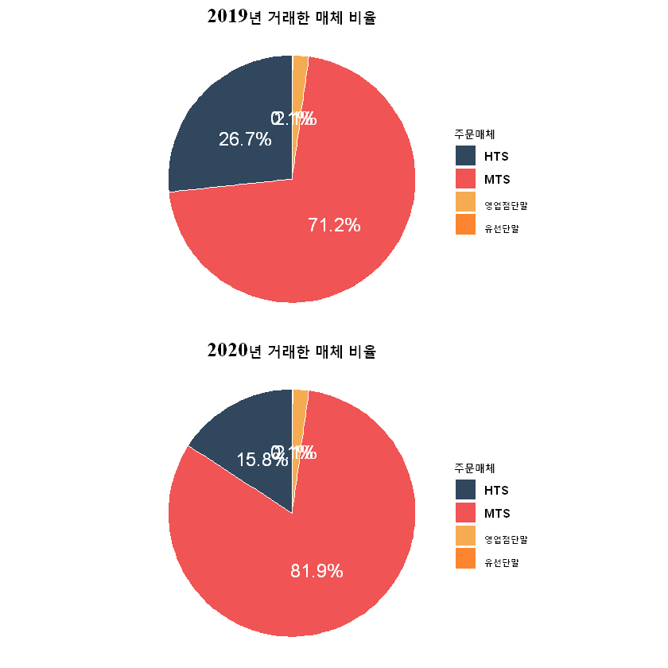

```r
########주문 매체 분포 시각화 #################

## 2019 년 / 2020년 따로 파이차트 비교하기

orr_table <- trd_tot %>% filter(trd_year == 2019) %>%
  group_by(orr_mdi_dit_cd) %>%
  summarise(count = n()) %>% data.frame() %>%
  mutate(orr_name = ifelse(orr_mdi_dit_cd == 1,'영업점단말',
                           ifelse(orr_mdi_dit_cd ==2,'유선단말',
                                  ifelse(orr_mdi_dit_cd ==3, 'MTS','HTS')))) %>%
  arrange(desc('orr_name')) %>%
  mutate(per = round(100*(count/sum(count)),1)) %>%
  mutate(ypos = cumsum(per) - 0.5*per)

a <- ggplot(orr_table, aes(x="", y=per, fill = orr_name )) +
  geom_bar(width = 1, stat='identity', color = 'white') +
  coord_polar("y", start = 0) +
  geom_text(aes(label = paste0(per,'%')),position = position_stack(vjust = 0.5),color = "white",size = 5) +
  scale_fill_manual(values = c('#30475E','#F05454','#F5AB52','#FC8530'), name="주문매체") + theme_void() +
  ggtitle('2019년 거래한 매체 비율') +
  theme(plot.title = element_text(family = "serif", face = "bold", hjust = 0.5, size = 15, color = "black"),
        text =element_text(face = "bold"))

orr_table <- trd_tot %>% filter(trd_year == 2020) %>%
  group_by(orr_mdi_dit_cd) %>%
  summarise(count = n()) %>% data.frame() %>%
  mutate(orr_name = ifelse(orr_mdi_dit_cd == 1,'영업점단말',
                           ifelse(orr_mdi_dit_cd ==2,'유선단말',
                                  ifelse(orr_mdi_dit_cd ==3, 'MTS','HTS')))) %>%
  arrange(desc('orr_name')) %>%
  mutate(per = round(100*(count/sum(count)),1)) %>%
  mutate(ypos = cumsum(per) - 0.5*per)

b <- ggplot(orr_table, aes(x="", y=per, fill = orr_name )) +
  geom_bar(width = 1, stat='identity', color = 'white') +
  coord_polar("y", start = 0) +
  geom_text(aes(label = paste0(per,'%')),position = position_stack(vjust = 0.5),color = "white",size = 5) +
  scale_fill_manual(values = c('#30475E','#F05454','#F5AB52','#FC8530'), name="주문매체") + theme_void() +
  ggtitle('2020년 거래한 매체 비율') +
  theme(plot.title = element_text(family = "serif", face = "bold", hjust = 0.5, size = 15, color = "black"),
        text =element_text(face = "bold"))


grid.arrange(a,b,nrow = 2, ncol = 1)
```

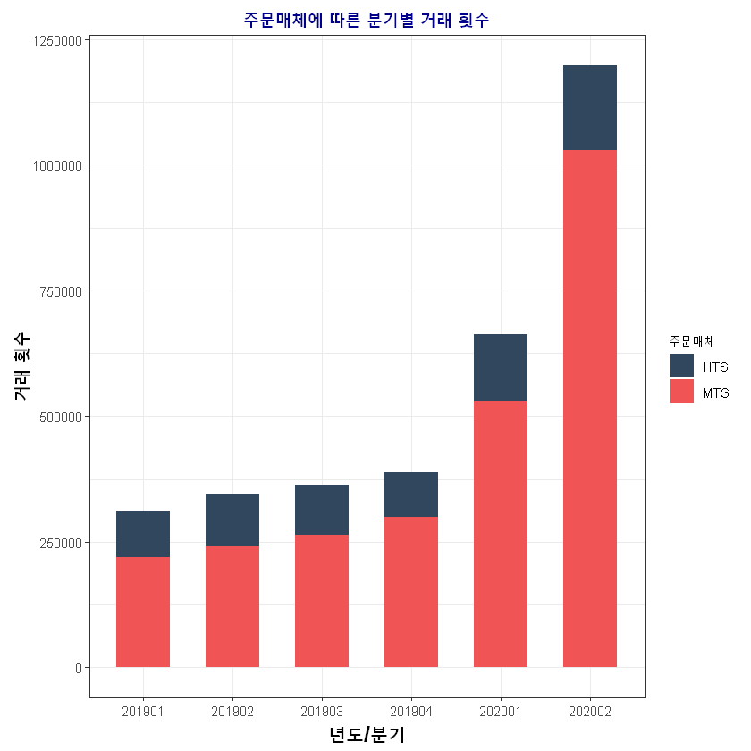

```r
###### 주문 매체 파이차트 ==> MTS랑 HTS의 비중이 압도적인것을 확인
###### 나머지 두개 매체는 비중 없으니 시각화 과정에서 제외
orr_mdi_df %>%
  filter(orr_mdi_dit_cd %in% c('MTS','HTS')) %>%
  ggplot(aes(x= factor(trd_yQ), y = count, fill = orr_mdi_dit_cd)) +
  geom_bar(stat="identity",width=.6) +
  ylab('거래 횟수') + xlab('년도/분기') +
  theme_bw() +
  ggtitle('주문매체에 따른 분기별 거래 횟수') +
  theme(axis.title.x = element_text(size  = 15, face  = "bold", angle = 0, vjust = 0.5),
        axis.title.y = element_text(size  = 15, face  = "bold", angle = 90, vjust = 0.5),
        plot.title = element_text(family = "serif", face = "bold", hjust = 0.5, size = 15, color = "darkblue")) +
  scale_fill_manual('주문매체',values = c('#30475E','#F05454'))
```

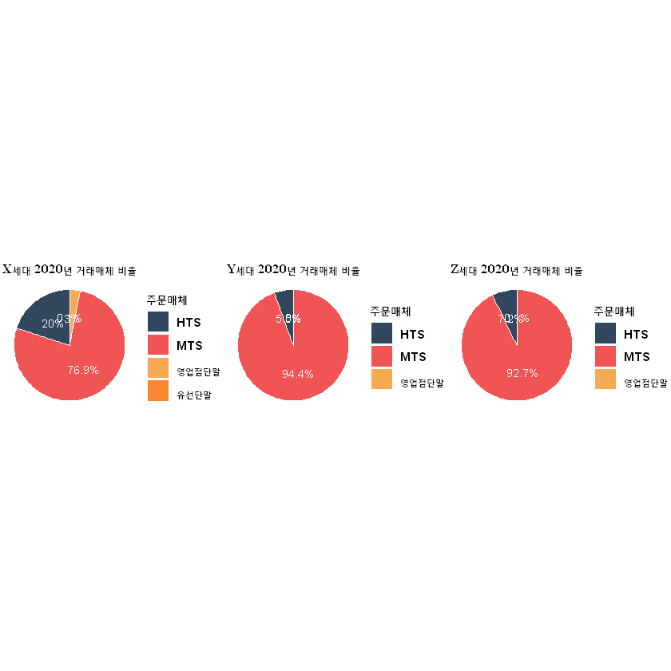

```r
## 세대별 거래매체 파이차트

orr_table <- trd_tot %>% filter(trd_year == 2020 & age_group == 'X') %>%
  group_by(orr_mdi_dit_cd) %>%
  summarise(count = n()) %>% data.frame() %>%
  mutate(orr_name = ifelse(orr_mdi_dit_cd == 1,'영업점단말',
                           ifelse(orr_mdi_dit_cd ==2,'유선단말',
                                  ifelse(orr_mdi_dit_cd ==3, 'MTS','HTS')))) %>%
  arrange(desc('orr_name')) %>%
  mutate(per = round(100*(count/sum(count)),1)) %>%
  mutate(ypos = cumsum(per) - 0.5*per)
b <- ggplot(orr_table, aes(x="", y=per, fill = orr_name )) +
  geom_bar(width = 1, stat='identity', color = 'white') +
  coord_polar("y", start = 0) +
  geom_text(aes(label = paste0(per,'%')),position = position_stack(vjust = 0.5),color = "white",size = 3) +
  scale_fill_manual(values = c('#30475E','#F05454','#F5AB52','#FC8530'), name="주문매체") + theme_void() +
  ggtitle('X세대 2020년 거래매체 비율') +
  theme(plot.title = element_text(family = "serif", face = "bold", hjust = 0.5, size = 10, color = "black"),
        text =element_text(face = "bold"))

orr_table <- trd_tot %>% filter(trd_year == 2020 & age_group == 'Y') %>%
  group_by(orr_mdi_dit_cd) %>%
  summarise(count = n()) %>% data.frame() %>%
  mutate(orr_name = ifelse(orr_mdi_dit_cd == 1,'영업점단말',
                           ifelse(orr_mdi_dit_cd ==2,'유선단말',
                                  ifelse(orr_mdi_dit_cd ==3, 'MTS','HTS')))) %>%
  arrange(desc('orr_name')) %>%
  mutate(per = round(100*(count/sum(count)),1)) %>%
  mutate(ypos = cumsum(per) - 0.5*per)
d <- ggplot(orr_table, aes(x="", y=per, fill = orr_name )) +
  geom_bar(width = 1, stat='identity', color = 'white') +
  coord_polar("y", start = 0) +
  geom_text(aes(label = paste0(per,'%')),position = position_stack(vjust = 0.5),color = "white",size = 3) +
  scale_fill_manual(values = c('#30475E','#F05454','#F5AB52','#FC8530'), name="주문매체") + theme_void() +
  ggtitle('Y세대 2020년 거래매체 비율') +
  theme(plot.title = element_text(family = "serif", face = "bold", hjust = 0.5, size = 10, color = "black"),
        text =element_text(face = "bold"))

orr_table <- trd_tot %>% filter(trd_year == 2020 & age_group == 'Z') %>%
  group_by(orr_mdi_dit_cd) %>%
  summarise(count = n()) %>% data.frame() %>%
  mutate(orr_name = ifelse(orr_mdi_dit_cd == 1,'영업점단말',
                           ifelse(orr_mdi_dit_cd ==2,'유선단말',
                                  ifelse(orr_mdi_dit_cd ==3, 'MTS','HTS')))) %>%
  arrange(desc('orr_name')) %>%
  mutate(per = round(100*(count/sum(count)),1)) %>%
  mutate(ypos = cumsum(per) - 0.5*per)
f <- ggplot(orr_table, aes(x="", y=per, fill = orr_name )) +
  geom_bar(width = 1, stat='identity', color = 'white') +
  coord_polar("y", start = 0) +
  geom_text(aes(label = paste0(per,'%')),position = position_stack(vjust = 0.5),color = "white",size = 3) +
  scale_fill_manual(values = c('#30475E','#F05454','#F5AB52','#FC8530'), name="주문매체") + theme_void() +
  ggtitle('Z세대 2020년 거래매체 비율') +
  theme(plot.title = element_text(family = "serif", face = "bold", hjust = 0.5, size = 10, color = "black"),
        text =element_text(face = "bold"))


grid.arrange(b,d,f,nrow = 1 , ncol = 3)
```

## ▶ Finding (b): MTS가 거래에서 차지하는 비중을 통해 YZ세대가 2020년 주식시장에서 차지하는 비중이 커진 것을 재확인.

### (YZ세대가 가지는 특징)

## "YZ세대가 주식 투자에 있어 X세대와 차이가 나는 요인에 주목해야 한다!"

고객등급과 고객성향을 기반으로, X세대와 차이가 나는지를 확인해 그들이 가진 고유한 성질을 찾아야 한다. YZ세대는 X세대와는 다르다.

### (a) 고객 등급의 비교

```
 X세대와 YZ세대간의 고객 등급에서 발생하는 차이를 확인하였다. X세대는 4-5등급의 분포에 몰려있다면, YZ세대는 5-9등급에 그 분포가 몰려있었다.
```

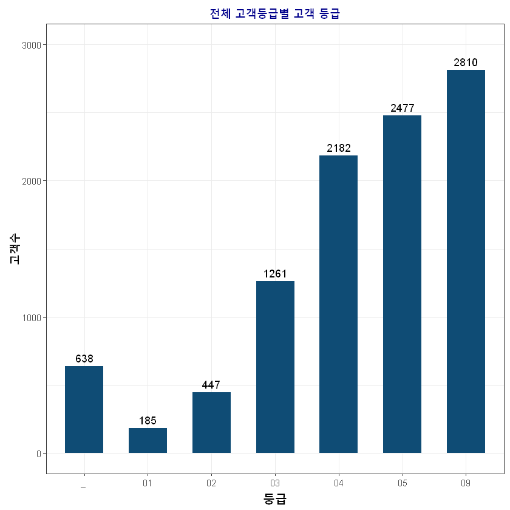

```r
barplot_fun <- function(df,x,y,fill,ylab_text,xlab_text,title,label,limit=0){
  df%>%
    ggplot( aes(x= {{x}}, y = {{y}})) +
    geom_bar(stat="identity", fill= fill , width=.6) +
    ylab(ylab_text) + xlab(xlab_text) +
    theme_bw() +
    ggtitle(title) +
    geom_text(aes(label = {{label}}), vjust = -0.5, color = "black") +
    theme(axis.title.x = element_text(size  = 15, face  = "bold", angle = 0, vjust = 0.5),
          axis.title.y = element_text(size  = 15, face  = "bold", angle = 90, vjust = 0.5),
          plot.title = element_text(family = "serif", face = "bold", hjust = 0.5, size = 15, color = "darkblue"))+
    scale_y_continuous(limits = limit)
}

grade_table <- table(cus_info$tco_cus_grd_cd) %>%
  data.frame() %>%
  rename(c('grade'=Var1,  'count'=Freq))

barplot_fun(grade_table, grade, count,"#0F4C75",'고객수','등급',
            '전체 고객등급별 고객 등급',count, c(0,3000))
```

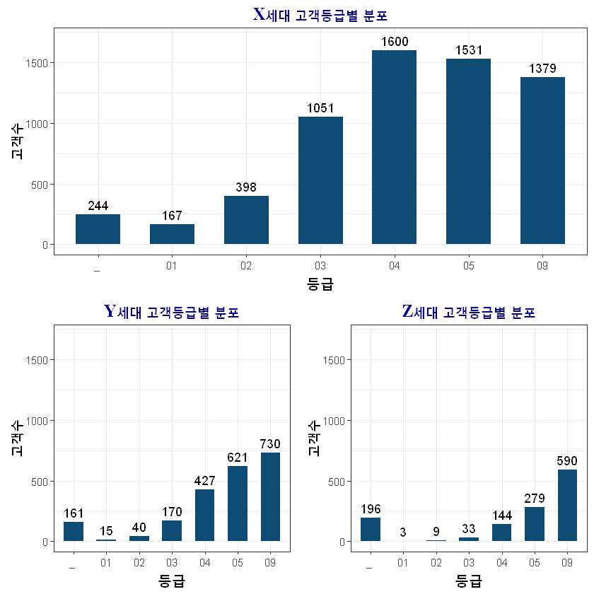

```r
grade_table_x <- table(cus_info_x$tco_cus_grd_cd) %>%
  data.frame() %>%
  rename(c('grade'=Var1,  'count'=Freq))

x <- barplot_fun(grade_table_x, grade, count,"#0F4C75",'고객수','등급',
                 'X세대 고객등급별 분포',count, c(0,1700))

grade_table_y <- table(cus_info_y$tco_cus_grd_cd) %>%
  data.frame() %>%
  rename(c('grade'=Var1,  'count'=Freq))

y <-  barplot_fun(grade_table_y, grade, count,"#0F4C75",'고객수','등급',
                  'Y세대 고객등급별 분포',count, c(0,1700))

grade_table_z <- table(cus_info_z$tco_cus_grd_cd) %>%
  data.frame() %>%
  rename(c('grade'=Var1,  'count'=Freq))

z <- barplot_fun(grade_table_z, grade, count,"#0F4C75",'고객수','등급',
                 'Z세대 고객등급별 분포',count, c(0,1700))

lay <- rbind(c(3,3),
             c(1,2))

grid.arrange(y,z,x,layout_matrix = lay)
```

NH투자증권은 매분기 실적을 통해 고객의 등급을 부여한다. 이때, 본 데이터에서는 결측치로 여겨지는 "*"등급이 존재한다. "*"등급과 "9"등급은 서로 구분을 해야 하는데, "*" 등급은 아직 등급을 부여받지못한 신규고객 (2020년 1분기 실적 없음), "9"등급은 기존 고객이지만 5등급보다 낮은 등급을 가진 고객임을 발견하였다. 이에 대한 근거는, 2020년 각 등급별로 첫 주식 거래일자를 추출한 결과, "*"등급을 가진 모든 고객들은 반드시 4월부터 거래를 한 것으로 밝혀졌다. 따라서 본 데이터에서 주어진 등급은 2020년 1분기 실적을 기준으로 부여된 등급인 것을 알 수 있다.

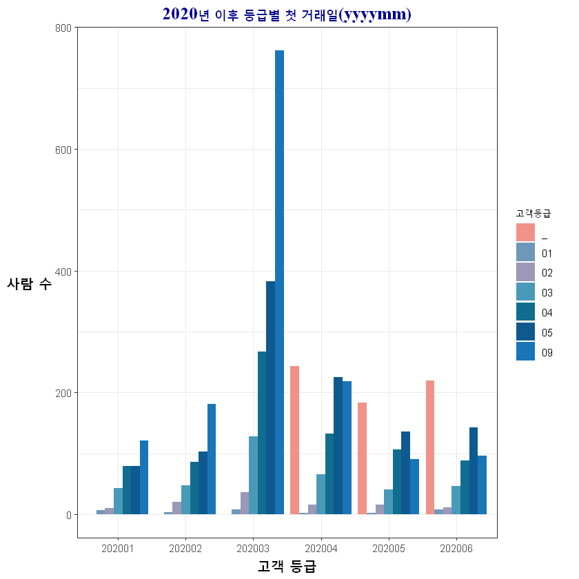

```r
# 등급 부여하는 과정 서술
### -등급은 2020년 2분기에 거래한 사람들임을 확인
first_trd <- trd_tot %>% group_by(act_id) %>%
  summarise(first_trd = min(trd_ym))   # 각 계좌별 첫 거래날짜 (우리데이터 기준)

first <- left_join(first_trd, act_info, by = 'act_id')

first_tb <- with(first,table(first_trd, tco_cus_grd_cd)) %>% data.frame()

ggplot(data=first_tb %>%
         filter(substr(first_trd,1,4) == '2020'),
       aes(x=first_trd, y = Freq,
           fill=tco_cus_grd_cd))+
  geom_bar(stat="identity",
           position="dodge") +
  ylab('사람 수') + xlab('고객 등급') +
  theme_bw() +
  ggtitle("2020년 이후 등급별 첫 거래일(yyyymm)") +
  theme(axis.title.x = element_text(size  = 15, face  = "bold", angle = 0, vjust = 0.5),
        axis.title.y = element_text(size  = 15, face  = "bold", angle = 0, vjust = 0.5),
        plot.title = element_text(family = "serif", face = "bold", hjust = 0.5, size = 15, color = "darkblue")) +
  scale_fill_manual('고객등급',values = c('#F09289', "#6E98B8","#9B98B8","#499AB8","#106D8F","#0E598F","#1975B8"))
```

"_"등급을 가진 고객들의 2020년 2분기 실적을 기준으로 등급을 예측하여 이들에게 실제 가질 확률이 높은 등급을 부여하기로 하였다. 이를 진행하기 위해, 각 등급별 고객을 100명을 Random Sampling한 뒤, 이들이 가진 총거래금액의 평균을 각 등급마다 계산하였다. 이를 1000번 반복하였고, 각 등급마다의 총거래금액의 평균 분포를 BOX PLOT에 나타내니 등급마다의 차이를 발견할 수 있었다.

이후 "_"등급을 가진 고객의 실제 예상 등급을 지정해주었다. 이는 해당 고객의 총거래금액을 기준으로 주어진 각 등급마다의 총거래금액의 평균 분포들 중 가장 확률이 높은 값을 구하여 거기에 해당하는 등급을 부여하였다. 해당 결과는 프로파일링이 완성된 후, 프로파일링간의 특징을 비교하는데 사용하였다.

[figure not shown]

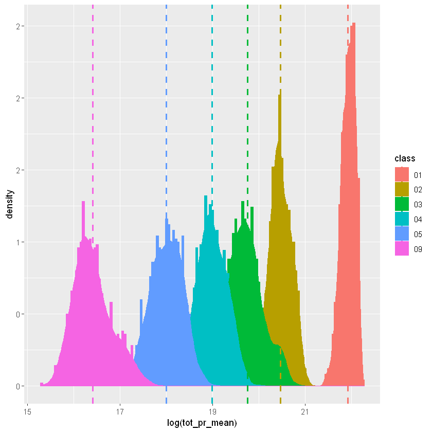

```r
#### 고객등급 결측치 채우는 코드

## CLT ==> 해석 필요

grade <- c('01','02','03','04','05','09')

N <- 1000

mean_df_final <- data.frame()

for (i in grade){
  for (j in 1:N){

    cus <- trd_tot %>%
      filter(tco_cus_grd_cd == i & trd_yQ == 202001)

    unique_id <- unique(cus$cus_id)
    sample_id <- sample(unique_id, 100)
    sample_df <- cus %>% filter(cus_id %in% sample_id)
    sample_sum <- aggregate(tot_pr~cus_id, sample_df, sum)
    sample_mean <- mean(sample_sum$tot_pr)
    mean_df <- data.frame(tot_pr_mean = sample_mean , class = i)
    mean_df_final <- rbind(mean_df_final, mean_df)
  }
}

mean_df_final$class <- as.factor(mean_df_final$class)

mean_df_final %>%
  ggplot(mapping = aes(y=tot_pr_mean, x=class,group = class, fill = class)) +
  geom_boxplot() +
  theme_classic() +
  xlab('고객등급') + ylab('총거래금액 합계') +
  scale_y_continuous(labels = scales::comma)   # 색상 조합 보류

mu <- plyr::ddply(mean_df_final, 'class', summarise, grp.mean = mean(log(tot_pr_mean)))

ggplot(mean_df_final, aes(x=log(tot_pr_mean), fill = class, color = class))+
  geom_histogram(aes(y=..density..), position = 'identity', binwidth = 0.05)+
  geom_density()+
  geom_vline(data = mu, aes(xintercept = grp.mean, color = class),
             linetype = 'dashed', size = 1)+
  scale_y_continuous(labels = scales::comma)

final_mean <- aggregate(tot_pr_mean ~ class,mean_df_final,mean)
final_sd <- aggregate(tot_pr_mean~class,mean_df_final, sd)

cus_new <- trd_tot %>% filter(tco_cus_grd_cd == '_ ')
#length(unique(cus_new$cus_id))  => 638명 => 누락없음
cus_new_total <- aggregate(tot_pr~cus_id, cus_new, sum)
cus_new_total$tco_cus_grd_cd <- sapply(cus_new_total$tot_pr, function(x) which.min(abs((x-final_mean$tot_pr_mean)/final_sd$tot_pr_mean)))

cus_new_total <- cus_new_total[,c(1,3)]

trd_tot_new <- trd_tot %>% filter(tco_cus_grd_cd == '_ ')
trd_tot_ori <- trd_tot %>% filter(tco_cus_grd_cd != '_ ')

for (i in 1:nrow(trd_tot_new)){
  new_grade <- paste0('0',cus_new_total[which(cus_new_total$cus_id == trd_tot_new$cus_id[i]),2])
  if (new_grade == '06') {
    new_grade <-  '09'
  }
  trd_tot_new$tco_cus_grd_cd[i] <- new_grade
}

trd_tot <- rbind(trd_tot_new, trd_tot_ori)
cus_info <- trd_tot[!duplicated(trd_tot[,cus_id]),][,c(20,27,28,29,30,31,32)]
```

```r
table(trd_tot_new$tco_cus_grd_cd)
```

```
   _     01    02    03    04    05    09
    0     0   325  3164  4290 10162 11993
```

## ▶ Finding (a): 등급을 결정하는 요소는 수수료와 체결가격이므로, {얼마나 자주 투자하는지, 어느 정도의 금액이 투자에 이용되는지, 가진 자본이 어느 정도인지}에 주목.

### (b) 고객 성향의 비교

```
 연령에 따라 고객 성향에서도 차이가 발생함을 확인하였다. Z세대와 같이 20대의 경우, 안전추구형이 대부분이었으나, 나이대가 올라갈수록 적극투자형에 그 분포가 모이는 것을 발견하였다.즉, 연령의 증가에 따라 투자성향이 안전형에서 적극투자형으로 이동하는 경향을 발견하여, 성향에 있어서 X세대와 YZ세대를 구분하여 분석할 필요가 있음을 알 수 있다.
```

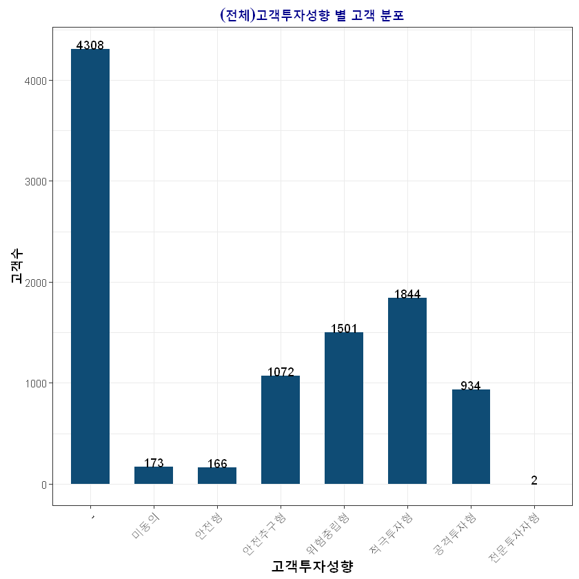

```r
barplot_fun_dis <- function(df, x,y,ylab_text,xlab_text,title,label_1,angle,hjust,label_2){
  df%>%
    ggplot( aes(x= {{x}}, y = {{y}})) +
    geom_bar(stat="identity", fill="#0F4C75",width=.6) +
    ylab(ylab_text) + xlab(xlab_text) +
    theme_bw() +
    ggtitle(title) +
    geom_text(aes(label = {{label_1}}), vjust = 0, color = "black") +
    theme(axis.title.x = element_text(size  = 15, face  = "bold", angle = 0, vjust = 0.5),
          axis.title.y = element_text(size  = 15, face  = "bold", angle = 90, vjust = 0.5),
          plot.title = element_text(family = "serif", face = "bold", hjust = 0.5, size = 15, color = "darkblue"),
          axis.text.x = element_text(angle = angle, hjust=hjust)) +
    scale_x_discrete(labels = label_2)
}

icn_label <-  c('-','미동의','안전형','안전추구형','위험중립형','적극투자형','공격투자형','전문투자자형')

icn_table <- table(cus_info$ivs_icn_cd) %>%
  data.frame() %>%
  rename(c('icn' = Var1, 'count' = Freq))

barplot_fun_dis(icn_table, icn, count,'고객수','고객투자성향',
                '(전체)고객투자성향 별 고객 분포',count,45,1,icn_label)
```

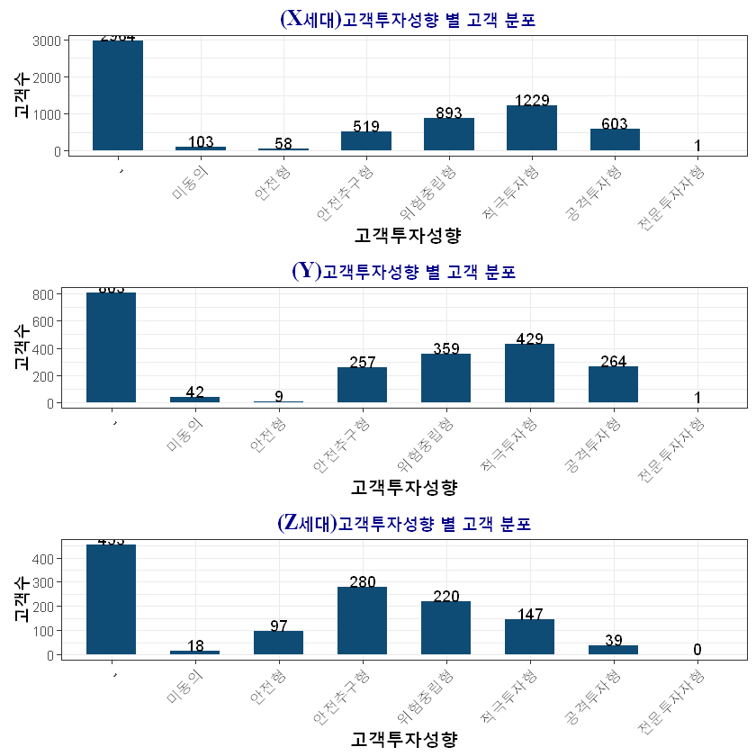

```r
icn_table_y <- table(cus_info_y$ivs_icn_cd) %>%
  data.frame() %>%
  rename(c('icn' = Var1, 'count' = Freq))

y <- barplot_fun_dis(icn_table_y,icn,count,'고객수','고객투자성향','(Y)고객투자성향 별 고객 분포',
                     count,45,1,icn_label)

icn_table_z <- table(cus_info_z$ivs_icn_cd) %>%
  data.frame() %>%
  rename(c('icn' = Var1, 'count' = Freq))

z <- barplot_fun_dis(icn_table_z,icn,count,'고객수','고객투자성향','(Z세대)고객투자성향 별 고객 분포',
                     count,45,1,icn_label)


icn_table_x <- table(cus_info_x$ivs_icn_cd) %>%
  data.frame() %>%
  rename(c('icn' = Var1, 'count' = Freq))

x <- barplot_fun_dis(icn_table_x,icn,count,'고객수','고객투자성향','(X세대)고객투자성향 별 고객 분포',
                     count,45,1,icn_label)

grid.arrange(x,y,z,ncol = 1, nrow = 3)
```

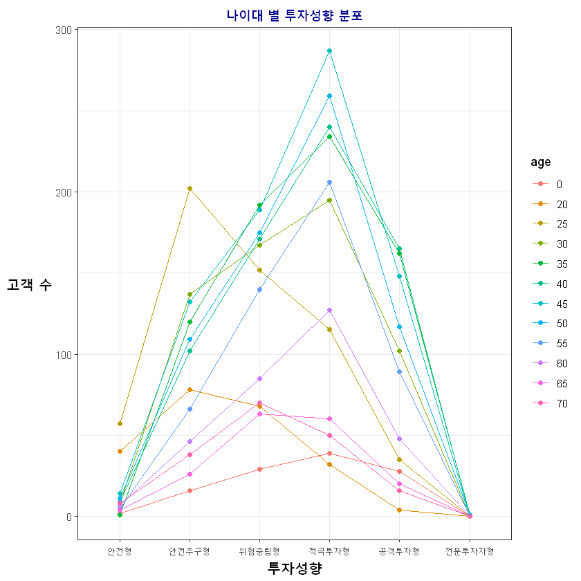

```r
icn_table <- table(cus_info$ivs_icn_cd, cus_info$cus_age) %>%
  data.frame() %>%
  rename(c('icn'=Var1, 'age'=Var2,'count'=Freq))

icn_table %>%
  filter(icn != '-' & icn!= '00') %>%
  ggplot(aes(x=icn, y=count, group=age, col=age)) +
  geom_line() +
  geom_point() +
  xlab("투자성향") + ylab("고객 수")  +
  theme_bw() +
  ggtitle("나이대 별 투자성향 분포") +
  theme(axis.title.x = element_text(size  = 15, face  = "bold", angle = 0, vjust = 0.5),
        axis.title.y = element_text(size  = 15, face  = "bold", angle = 0, vjust = 0.5),
        plot.title = element_text(family = "serif", face = "bold", hjust = 0.5, size = 15, color = "darkblue")) +
  scale_x_discrete(labels = c('안전형','안전추구형','위험중립형','적극투자형','공격투자형','전문투자자형'))
```

## ▶ Finding (b): 고객의 성향은 연령에 대한 영향을 받으므로 X와 YZ세대를 구분할 필요가 있다. 이들의 투자 방식 혹은 투자 경향성이 다르다는 것에 주목.

## Findings 기반으로 YZ세대 프로파일링을 위해 이들을 구별하는 요인(Factor)은 다음과 같다.

- 빈도(F; Frequency): 얼마나 자주 거래하는가? 거래하는 날의 빈도가 어느 정도인가?
- 적극성(A;Attention): 하루에 보통 얼마나 거래를 여러번 많이 하는가? / 집중적으로 거래횟수를 많이 하는가?
- 최근성(R; Recency): 얼마나 최근에 거래하였는가?
- 규모(M; Monetary): 거래금액의 규모가 어느 정도인가?

## 1.3 Framework & Contribution (프레임워크 & 기여)

### 요인분석(Factor Analysis) → 잠재프로파일분석(LPA)

- 요인분석:

  공통된 성질의 변수들을 조합하여 추상적 개념을 하나의 요인으로 형성하는 기법

  기존에는 관찰되지 않았으나 의미 있는 소수의 요인들을 추출

  하나의 변수가 하나의 성질을 나타낸다는 가정하에 발생하는 고전적인 측정오차 문제를 극복
- 잠재프로파일분석:

  변수들간의 통계적 분포를 고려하여 개인마다의 경향성을 반영하는 고객 분류 기법

  기존의 수 많은 클러스터링 기법이 통계적 추론없이 거리에 주로 의존하여 고객 분류를 하는 한계점을 극복

  기존의 클러스터링 기법이 군집의 수 (프로파일의 수)를 주관적으로 결정한다는 한계점을 적합도를 이용해 정량적 판단을 하여 극복

# 2. Methodology (방법론)

## 2.1 Factor Analysis (요인 분석)

```r
# YZ세대만 한정시킨 Dataframe
trd_tot_yz20 <- trd_tot %>% filter(age_group %in% c('Y','Z') & trd_yQ %in% c(202001,202002))
```

```r
# 빈도 변수 3개
# 집중 변수 3개

cus_final_freq <- data.frame()

for (i in unique(trd_tot_yz20$cus_id)){   # 3276

  df <- trd_tot_yz20 %>% filter(cus_id == i)  # 특정 고객 거래데이터 filter

  min_month <- min(df$trd_month)  # 첫 거래 포함  달 mm
  min_day <- min(as.Date(df$orr_dt))  # 첫 거래 일자 yyyy-mm-dd
  day_diff <- unclass(as.Date('2020-07-01') - min_day )[[1]] # 첫 거래일 ~ 2020-07-01 차이


  k=0

  for (j in 1:6){

    df_j <- df %>% filter(trd_month == j)  # 각 달
    if (nrow(df_j) != 0){
      k = k+1
    }
  }     # 매수+매도 데이터가 있는 달은 몇개니? ==> k

  trd_freq <- nrow(df)  # 총 빈도수 ==> 거래를 얼마나 했니?
  sell_freq <- nrow(df[df$sby_dit_cd == 1,])  # 총 매도 빈도수 ===> 매도는 얼마나 했니?
  buy_freq <- nrow(df[df$sby_dit_cd == 2,])  # 총 매수 빈도수 ===> 매수는 얼마나 했니?

  unique_day <- n_distinct(df$orr_dt)  # 거래한 날짜 수 ==> 거래를 총 며칠해봤니?


  dfdf <- data.frame(cus_id = i ,
                     freq_mean_month = trd_freq / k ,  # 월 평균 거래 빈도수 (매수+매도)
                     freq_mean_day = trd_freq / unique_day, # 일 평균 거래 빈도수 (매수+매도)
                     freq_max_mean_day = (max(sell_freq,buy_freq,na.rm = T)) / unique_day, # max(매수빈도수,매도빈도수) / 활동일
                     freq_day_month_ratio = unique_day / k, # 월 평균 거래일수
                     freq_day_minmonth_ratio = unique_day / (7-min_month),
                     freq_day_ratio = unique_day / day_diff)  # (첫거래~2020-07-01)동안 며칠을 거래했니?

  cus_final_freq <- rbind(cus_final_freq, dfdf)

}

cus_final_active <- cus_final_freq[,c(1,2,3,4)]
cus_final_freq <- cus_final_freq[,c(1,5,6,7)]

head(cus_final_freq)
```

| cus_id | freq_day_month_ratio | freq_day_minmonth_ratio | freq_day_ratio |
| --- | --- | --- | --- |
| f4545a81bb4691e5d74b45a4ba04298e9d770e2587189607e85d9b395b7a6ace | 8.000000 | 8.0000000 | 0.26666667 |
| c132df3ee4822b5dea7d41d429ccdd63cd692e29c6b80e140afaaf9defd53e08 | 1.500000 | 1.0000000 | 0.03797468 |
| 6a7d429d51dc365a1760a527cfbb071ce528df084b88347b29f9a948512725f1 | 1.000000 | 0.3333333 | 0.01408451 |
| ca8373143fb9cf6d3ed8b476bb3a49cb098261d7a8ec3a75202948c43f5b8f2a | 11.000000 | 11.0000000 | 0.46478873 |
| 5c2de509fc03c550c7975048dfc124d4f98c7b94379604453148270bb83bc0cc | 2.666667 | 2.6666667 | 0.11764706 |
| 649ddc796ac94a7700b98d4bfbc9fe9050edf372be7d8178fc61207e948dbe37 | 15.000000 | 15.0000000 | 0.50000000 |

```r
# 규모 변수 4개

cus_final_scale <- data.frame()

suppressMessages(for (i in unique(trd_tot_yz20$cus_id)){   # 3276

  df <- trd_tot_yz20 %>% filter(cus_id == i)
  df_sell <- trd_tot_yz20 %>% filter(cus_id == i & sby_dit_cd ==1)
  df_buy <- trd_tot_yz20 %>% filter(cus_id == i & sby_dit_cd ==2)

  k=0  # 매도
  kk=0  # 매수

  for (j in 1:6){

    # j달에 거래한 주식데이터를 뽑음 (매도/매수별)

    df_j_sell <- df_sell %>% filter(trd_month == j)
    df_j_buy <- df_buy %>% filter(trd_month == j)

    if (nrow(df_j_sell) != 0){
      k = k+1  }    ## k값 의미 ==> 6개월 중 매도활동이 있었던 달 개수

    if (nrow(df_j_buy) != 0) {
      kk = kk+1   ## kk값 의미 ==> 6개월 중 매수활동이 있었던 달 개수
    }
  }


  ### 1번 변수 ###
  # 1회 거래시 가장 많이 사용한 금액
  max_totpr <- max(df$tot_pr)

  ### 2번 변수 ###
  # 거래 1회당 쓴 평균금액 매수/매도별 구해서 max
  mean_1freq_totpr <- df %>% group_by(sby_dit_cd) %>% summarise(mean2 = mean(tot_pr)) %>%
    select(mean2) %>% max()


  ### 3번 변수 ###
  # (활동한)월 평균 매수/매도별 거래금액을 구해서 max
  mean_month_totpr <- max( sum(df_buy$tot_pr)/kk , sum(df_sell$tot_pr)/k , na.rm = T )


  ### 4번 변수 ###
  # 종목당 매수/매도별 거래금액 평균 ==> 한번더 평균 ==> 평균적으로 한 종목에 쓰는 금액 구해서 max
  mean_sby_iem_totpr <- df %>% group_by(sby_dit_cd,iem_cd) %>% summarise(mean1 = mean(tot_pr))

  mean_iem_totpr_df <-  aggregate(mean1~sby_dit_cd,mean_sby_iem_totpr,mean)
  mean_iem_totpr <- max(mean_iem_totpr_df$mean1)  ## max(매수,매도)

  cus_scale_df <- data.frame(cus_id = i,
                             max_totpr = max_totpr,
                             mean_1freq_totpr = mean_1freq_totpr,
                             mean_month_totpr = mean_month_totpr,
                             mean_iem_totpr = mean_iem_totpr)

  cus_final_scale <- rbind(cus_final_scale, cus_scale_df)

})

head(cus_final_scale)
```

| cus_id | max_totpr | mean_1freq_totpr | mean_month_totpr | mean_iem_totpr |
| --- | --- | --- | --- | --- |
| f4545a81bb4691e5d74b45a4ba04298e9d770e2587189607e85d9b395b7a6ace | 2463000 | 257822.3 | 4683361 | 187501.4 |
| c132df3ee4822b5dea7d41d429ccdd63cd692e29c6b80e140afaaf9defd53e08 | 1498500 | 936250.0 | 936250 | 936250.0 |
| 6a7d429d51dc365a1760a527cfbb071ce528df084b88347b29f9a948512725f1 | 2625000 | 2625000.0 | 2625000 | 2625000.0 |
| ca8373143fb9cf6d3ed8b476bb3a49cb098261d7a8ec3a75202948c43f5b8f2a | 6174500 | 794169.8 | 18477653 | 771010.9 |
| 5c2de509fc03c550c7975048dfc124d4f98c7b94379604453148270bb83bc0cc | 1250000 | 527192.3 | 2284500 | 411046.9 |
| 649ddc796ac94a7700b98d4bfbc9fe9050edf372be7d8178fc61207e948dbe37 | 2134000 | 511463.0 | 10715395 | 522706.6 |

```r
# 최근성 변수 3개

cus_final_lately <- data.frame()

k=1

for (i in unique(trd_tot_yz20$cus_id)){   # 3276


  df_sell <- trd_tot_yz20 %>% filter(cus_id == i & sby_dit_cd == 1)  # 매도
  df_buy <- trd_tot_yz20 %>% filter(cus_id == i & sby_dit_cd == 2)  # 매수


  if (nrow(df_sell) != 0){
    sell_final_day <-  unclass(as.Date('2020-07-01') - max(as.Date(df_sell$orr_dt)))[[1]]  # 마지막 매도일자
  } else {
    sell_final_day <- 180
  }


  if (nrow(df_buy) != 0){
    buy_final_day <- unclass(as.Date('2020-07-01') - max(as.Date(df_buy$orr_dt)))[[1]]   # 마지막 매수일자
  } else {
    buy_final_day <- 180
  }

  final_trd_day <- min(sell_final_day,buy_final_day)  # 마지막 거래일자

  cus_lately_df <- data.frame(cus_id = i,
                              sell_final_day = sell_final_day,
                              buy_final_day = buy_final_day,
                              final_trd_day = final_trd_day)

  cus_final_lately <- rbind(cus_final_lately, cus_lately_df)
}

head(cus_final_lately)
```

| cus_id | sell_final_day | buy_final_day | final_trd_day |
| --- | --- | --- | --- |
| f4545a81bb4691e5d74b45a4ba04298e9d770e2587189607e85d9b395b7a6ace | 1 | 9 | 1 |
| c132df3ee4822b5dea7d41d429ccdd63cd692e29c6b80e140afaaf9defd53e08 | 26 | 23 | 23 |
| 6a7d429d51dc365a1760a527cfbb071ce528df084b88347b29f9a948512725f1 | 180 | 71 | 71 |
| ca8373143fb9cf6d3ed8b476bb3a49cb098261d7a8ec3a75202948c43f5b8f2a | 5 | 5 | 5 |
| 5c2de509fc03c550c7975048dfc124d4f98c7b94379604453148270bb83bc0cc | 22 | 15 | 15 |
| 649ddc796ac94a7700b98d4bfbc9fe9050edf372be7d8178fc61207e948dbe37 | 5 | 1 | 1 |

```r
total_df <- left_join(cus_final_freq,cus_final_lately,by='cus_id')
total_df <- left_join(total_df,cus_final_scale, by='cus_id')
total_df <- left_join(total_df, cus_final_active, by = 'cus_id')

head(total_df)  # {스케일링, 아웃라이어 제거} 전 원본 데이터
```

| cus_id | freq_day_month_ratio | freq_day_minmonth_ratio | freq_day_ratio | sell_final_day | buy_final_day | final_trd_day | max_totpr | mean_1freq_totpr | mean_month_totpr | mean_iem_totpr | freq_mean_month | freq_mean_day | freq_max_mean_day |
| --- | --- | --- | --- | --- | --- | --- | --- | --- | --- | --- | --- | --- | --- |
| f4545a81bb4691e5d74b45a4ba04298e9d770e2587189607e85d9b395b7a6ace | 8.000000 | 8.0000000 | 0.26666667 | 1 | 9 | 1 | 2463000 | 257822.3 | 4683361 | 187501.4 | 30.00000 | 3.750000 | 2.4583333 |
| c132df3ee4822b5dea7d41d429ccdd63cd692e29c6b80e140afaaf9defd53e08 | 1.500000 | 1.0000000 | 0.03797468 | 26 | 23 | 23 | 1498500 | 936250.0 | 936250 | 936250.0 | 1.50000 | 1.000000 | 0.6666667 |
| 6a7d429d51dc365a1760a527cfbb071ce528df084b88347b29f9a948512725f1 | 1.000000 | 0.3333333 | 0.01408451 | 180 | 71 | 71 | 2625000 | 2625000.0 | 2625000 | 2625000.0 | 1.00000 | 1.000000 | 1.0000000 |
| ca8373143fb9cf6d3ed8b476bb3a49cb098261d7a8ec3a75202948c43f5b8f2a | 11.000000 | 11.0000000 | 0.46478873 | 5 | 5 | 5 | 6174500 | 794169.8 | 18477653 | 771010.9 | 45.66667 | 4.151515 | 2.3030303 |
| 5c2de509fc03c550c7975048dfc124d4f98c7b94379604453148270bb83bc0cc | 2.666667 | 2.6666667 | 0.11764706 | 22 | 15 | 15 | 1250000 | 527192.3 | 2284500 | 411046.9 | 6.00000 | 2.250000 | 1.6250000 |
| 649ddc796ac94a7700b98d4bfbc9fe9050edf372be7d8178fc61207e948dbe37 | 15.000000 | 15.0000000 | 0.50000000 | 5 | 1 | 1 | 2134000 | 511463.0 | 10715395 | 522706.6 | 52.66667 | 3.511111 | 2.4666667 |

```r
#스케일링 후 데이터
scale_total_df <- cbind(total_df[1], scale(total_df[-1]))
head(scale_total_df)
```

| cus_id | freq_day_month_ratio | freq_day_minmonth_ratio | freq_day_ratio | sell_final_day | buy_final_day | final_trd_day | max_totpr | mean_1freq_totpr | mean_month_totpr | mean_iem_totpr | freq_mean_month | freq_mean_day | freq_max_mean_day |
| --- | --- | --- | --- | --- | --- | --- | --- | --- | --- | --- | --- | --- | --- |
| f4545a81bb4691e5d74b45a4ba04298e9d770e2587189607e85d9b395b7a6ace | 0.4398474 | 0.5091607 | 0.2830820 | -0.7332146 | -0.43590849 | -0.61228809 | -0.05691302 | -0.20341260 | -0.06200300 | -0.13373679 | -0.08993236 | -0.03588079 | -0.06418519 |
| c132df3ee4822b5dea7d41d429ccdd63cd692e29c6b80e140afaaf9defd53e08 | -0.9793679 | -0.9508351 | -0.9714779 | -0.3391296 | -0.08578315 | 0.03809993 | -0.06229276 | -0.15640979 | -0.06684353 | -0.10176990 | -0.37382718 | -0.50600214 | -0.52262751 |
| 6a7d429d51dc365a1760a527cfbb071ce528df084b88347b29f9a948512725f1 | -1.0885383 | -1.0898823 | -1.1025347 | 2.0884338 | 1.11464658 | 1.45712833 | -0.05600943 | -0.03940987 | -0.06466200 | -0.02967082 | -0.37880779 | -0.50600214 | -0.43733591 |
| ca8373143fb9cf6d3ed8b476bb3a49cb098261d7a8ec3a75202948c43f5b8f2a | 1.0948699 | 1.1348732 | 1.3699412 | -0.6701610 | -0.53594430 | -0.49403572 | -0.03621122 | -0.16625338 | -0.04418346 | -0.10882458 | 0.06612678 | 0.03275952 | -0.10392332 |
| 5c2de509fc03c550c7975048dfc124d4f98c7b94379604453148270bb83bc0cc | -0.7246369 | -0.6032170 | -0.5344107 | -0.4021832 | -0.28585477 | -0.19840480 | -0.06367883 | -0.18475011 | -0.06510185 | -0.12419279 | -0.32900168 | -0.29231062 | -0.27741418 |
| 649ddc796ac94a7700b98d4bfbc9fe9050edf372be7d8178fc61207e948dbe37 | 1.9682332 | 1.9691564 | 1.5631034 | -0.6701610 | -0.63598011 | -0.61228809 | -0.05874810 | -0.18583987 | -0.05421079 | -0.11942562 | 0.13585533 | -0.07671962 | -0.06205290 |

```r
summary(scale_total_df)
```

```
                                                              cus_id
 f4545a81bb4691e5d74b45a4ba04298e9d770e2587189607e85d9b395b7a6ace:   1
 c132df3ee4822b5dea7d41d429ccdd63cd692e29c6b80e140afaaf9defd53e08:   1
 6a7d429d51dc365a1760a527cfbb071ce528df084b88347b29f9a948512725f1:   1
 ca8373143fb9cf6d3ed8b476bb3a49cb098261d7a8ec3a75202948c43f5b8f2a:   1
 5c2de509fc03c550c7975048dfc124d4f98c7b94379604453148270bb83bc0cc:   1
 649ddc796ac94a7700b98d4bfbc9fe9050edf372be7d8178fc61207e948dbe37:   1
 (Other)                                                         :3270
 freq_day_month_ratio freq_day_minmonth_ratio freq_day_ratio
 Min.   :-1.0885      Min.   :-1.1246         Min.   :-1.1495
 1st Qu.:-0.7974      1st Qu.:-0.8118         1st Qu.:-0.8189
 Median :-0.3243      Median :-0.3251         Median :-0.2982
 Mean   : 0.0000      Mean   : 0.0000         Mean   : 0.0000
 3rd Qu.: 0.5854      3rd Qu.: 0.6134         3rd Qu.: 0.6136
 Max.   : 3.1691      Max.   : 3.1163         Max.   : 4.3060

 sell_final_day    buy_final_day      final_trd_day         max_totpr
 Min.   :-0.7332   Min.   :-0.63598   Min.   :-0.612288   Min.   :-0.07064
 1st Qu.:-0.6702   1st Qu.:-0.61097   1st Qu.:-0.612288   1st Qu.:-0.06448
 Median :-0.4968   Median :-0.46092   Median :-0.434910   Median :-0.05359
 Mean   : 0.0000   Mean   : 0.00000   Mean   : 0.000000   Mean   : 0.00000
 3rd Qu.: 0.2441   3rd Qu.: 0.03926   3rd Qu.: 0.008537   3rd Qu.:-0.01908
 Max.   : 2.1042   Max.   : 3.86563   Max.   : 4.679505   Max.   :56.64106

 mean_1freq_totpr   mean_month_totpr   mean_iem_totpr     freq_mean_month
 Min.   :-0.22108   Min.   :-0.06805   Min.   :-0.14162   Min.   :-0.37881
 1st Qu.:-0.19234   1st Qu.:-0.06529   1st Qu.:-0.12417   1st Qu.:-0.35092
 Median :-0.14629   Median :-0.05981   Median :-0.09659   Median :-0.29082
 Mean   : 0.00000   Mean   : 0.00000   Mean   : 0.00000   Mean   : 0.00000
 3rd Qu.:-0.02384   3rd Qu.:-0.03912   3rd Qu.:-0.02229   3rd Qu.:-0.07001
 Max.   :50.61277   Max.   :55.85403   Max.   :54.96466   Max.   :19.44070

 freq_mean_day      freq_max_mean_day
 Min.   :-0.50600   Min.   :-0.565273
 1st Qu.:-0.42053   1st Qu.:-0.425832
 Median :-0.29545   Median :-0.288076
 Mean   : 0.00000   Mean   : 0.000000
 3rd Qu.: 0.02038   3rd Qu.:-0.005547
 Max.   :16.05964   Max.   :14.823494
```

```r
# 스케일 이후, summary 확인 결과 max에서 눈에 띄는 이상치들이 발견
# 정규화 후, 6시그마를 기준으로 각 변수별 이상치 제거

col <- colnames(scale_total_df)
Z_data <- c()

for ( i in 2:length(col)){   # 1은 cus_id로 제외

  Z_df <- total_df %>% select(col[i])
  Z <- scores(Z_df, type = 'z')
  Z_which1 <- which(Z[[1]] %in% Z[Z > 6])
  Z_which2 <- which(Z[[1]] %in% Z[Z < -6])
  Z_data <- c(Z_data,Z_which1,Z_which2)

}

n_distinct(Z_data)  # 28명 제거
```

28

```r
outlier_which <- unique(Z_data)  # 28명의 위치 저장

out_scale_total_df <- scale_total_df[-outlier_which,]  # 3248obs: outlier제거 + 스케일링 된 데이터
out_total_df <- total_df[-outlier_which,]  # 3248obs: outlier제거 + 스케일링 전 데이터

##### 우리가 사용할 데이터 ==> out_scale_total_df ==> 이상치,스케일 완료된 데이터
##### 군집화 후, 우리가 시각화 및 분석할 데이터 ==> out_total_df ===> 이상치만 제거, 스케일 되기 전 데이터
```

### 동질성 검정

#### 각 Factor을 구성하는 변수들간에 하나의 성향을 제대로 나타내고 있는지 판단하기 위해 Cronbach's alpha를 이용

```
그 값이 대체로 0.7 이상이면 적절하다고 알려져 있음
```

```r
# 모든 Factor의 Cronhach's alpha 값이 높은 수치를 보임 (동질성)
cronbach(out_scale_total_df[,c(2,3,4)])  # Freq 0.98
cronbach(out_scale_total_df[,c(5,6,7)])   # Recency 0.86
cronbach(out_scale_total_df[,c(8,9,10,11)])  # Scale 0.82
cronbach(out_scale_total_df[,c(12,13,14)])  # Active 0.97
```

**$sample.size**

3248

**$number.of.items**

3

**$alpha**

0.980035271413479

**$sample.size**

3248

**$number.of.items**

3

**$alpha**

0.863341311367198

**$sample.size**

3248

**$number.of.items**

4

**$alpha**

0.828614486955001

**$sample.size**

3248

**$number.of.items**

3

**$alpha**

0.974964232464782

### Factor의 수를 Scree Plot을 이용해 적합한지를 판단

#### 그 결과, 4개의 Factor가 최적임을 발견. (F, A, R, M)

```
Parallel analysis suggests that the number of factors =  4  and the number of components =  3
```

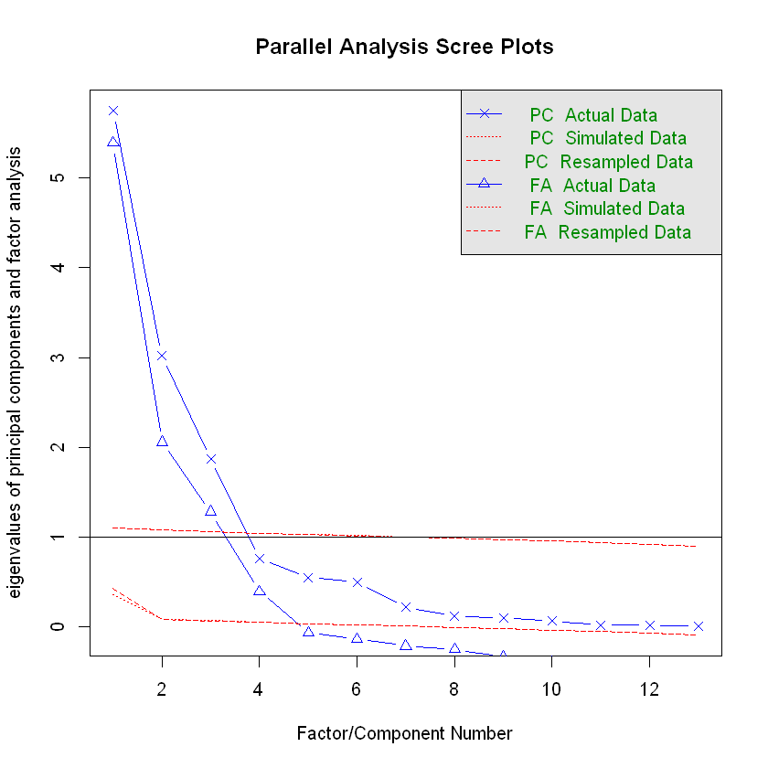

```r
# Scree Plot을 통해 Factor가 4개가 적합함을 확인
fa.parallel(out_scale_total_df[-1])
```

```r
df_fit <- factanal(out_scale_total_df[-1],4,rotation = 'promax')  # 요인 4개로 설정
print(df_fit)
```

```
Call:
factanal(x = out_scale_total_df[-1], factors = 4, rotation = "promax")

Uniquenesses:
   freq_day_month_ratio freq_day_minmonth_ratio          freq_day_ratio
                  0.015                   0.005                   0.130
         sell_final_day           buy_final_day           final_trd_day
                  0.506                   0.228                   0.005
              max_totpr        mean_1freq_totpr        mean_month_totpr
                  0.376                   0.005                   0.611
         mean_iem_totpr         freq_mean_month           freq_mean_day
                  0.038                   0.091                   0.005
      freq_max_mean_day
                  0.058

Loadings:
                        Factor1 Factor2 Factor3 Factor4
freq_day_month_ratio     1.057                   0.101
freq_day_minmonth_ratio  1.021
freq_day_ratio           0.866
sell_final_day          -0.274                   0.521
buy_final_day                                    0.879
final_trd_day            0.126                   1.059
max_totpr                0.110   0.768
mean_1freq_totpr                 1.003
mean_month_totpr         0.164   0.495   0.208
mean_iem_totpr                   0.986
freq_mean_month          0.248           0.796
freq_mean_day                            1.017
freq_max_mean_day       -0.117           1.040

               Factor1 Factor2 Factor3 Factor4
SS loadings      3.132   2.825   2.800   2.186
Proportion Var   0.241   0.217   0.215   0.168
Cumulative Var   0.241   0.458   0.674   0.842

Factor Correlations:
        Factor1 Factor2 Factor3 Factor4
Factor1   1.000 -0.1025  -0.568 -0.6600
Factor2  -0.103  1.0000   0.041  0.0988
Factor3  -0.568  0.0410   1.000  0.2675
Factor4  -0.660  0.0988   0.267  1.0000

Test of the hypothesis that 4 factors are sufficient.
The chi square statistic is 2154.14 on 32 degrees of freedom.
The p-value is 0
```

## 2.2 Latent Profile Anaylsis (LPA; 잠재 프로파일 분석)

#### 이에 따라, k=6

```r
## Factor1 => Frequency가 강하게 묶임
## Factor2 => Scale ==> mean_month_totpr 유의성 떨어짐
## Factor3 => Active
## Factor4 => Recency
## 전체 누적 설명력 84%

set.seed(20201231)
df_score <- factanal(out_scale_total_df[-1],4,scores = 'regression')$scores %>% data.frame()
m4 <- df_score %>% estimate_profiles(2:8)
get_fit(m4)
```

| Model | Classes | LogLik | AIC | AWE | BIC | CAIC | CLC | KIC | SABIC | ICL | Entropy | prob_min | prob_max | n_min | n_max | BLRT_val | BLRT_p |
| --- | --- | --- | --- | --- | --- | --- | --- | --- | --- | --- | --- | --- | --- | --- | --- | --- | --- |
| 1 | 2 | -17008.96 | 34043.91 | 34265.18 | 34123.03 | 34136.03 | 34019.87 | 34059.91 | 34081.72 | -34163.82 | 0.9813860 | 0.9769119 | 0.9969462 | 0.11453202 | 0.8854680 | 2763.2032835 | 0.00990099 |
| 1 | 3 | -16564.59 | 33165.19 | 33472.48 | 33274.73 | 33292.73 | 33130.98 | 33186.19 | 33217.54 | -33646.92 | 0.8956723 | 0.8839763 | 0.9786726 | 0.11514778 | 0.6751847 | 888.6603134 | 0.00990099 |
| 1 | 4 | -16449.51 | 32945.02 | 33338.25 | 33085.00 | 33108.00 | 32900.74 | 32971.02 | 33011.91 | -33711.29 | 0.8571119 | 0.8196430 | 0.9799169 | 0.11299261 | 0.5548030 | 2332.1723737 | 0.00990099 |
| 1 | 5 | -15354.15 | 30764.30 | 31243.40 | 30934.70 | 30962.70 | 30710.01 | 30795.30 | 30845.73 | -31681.57 | 0.8551544 | 0.7291174 | 0.9846324 | 0.03294335 | 0.5828202 | -0.1712972 | 1.00000000 |
| 1 | 6 | -13888.86 | 27843.71 | 28408.51 | 28044.54 | 28077.54 | 27779.57 | 27879.71 | 27939.69 | -28440.81 | 0.9313964 | 0.8569914 | 0.9901940 | 0.01600985 | 0.6400862 | 2080.1048283 | 0.00990099 |
| 1 | 7 | -13888.83 | 27853.66 | 28504.58 | 28084.92 | 28122.92 | 27779.25 | 27894.66 | 27964.18 | -29166.84 | 0.7976008 | 0.0000000 | 0.9905200 | 0.00000000 | 0.6330049 | 1015.6095411 | 0.00990099 |
| 1 | 8 | -13508.12 | 27102.24 | 27838.96 | 27363.93 | 27406.93 | 27017.91 | 27148.24 | 27227.30 | -28282.69 | 0.8305088 | 0.0000000 | 0.9888431 | 0.00000000 | 0.6185345 | -76.1896163 | 0.32673267 |

```r
head(df_score)
```

[output not shown]

```r
set.seed(20201231)
m4 <- m4$model_1_class_6
```

```r
m4
```

```
tidyProfile estimated using Mclust:

    Model   Classes    LogLik       AIC       AWE       BIC      CAIC       CLC
        1         6 -13888.86  27843.71  28408.51  28044.54  28077.54  27779.57
      KIC     SABIC       ICL   Entropy  prob_min  prob_max     n_min     n_max
 27879.71  27939.69 -28440.81      0.93      0.86      0.99      0.02      0.64
 BLRT_val    BLRT_p
  2080.10      0.01
```

### LPA를 통해 만들어진 6개 각각의 고객 프로파일링이 Factor마다 가지는 값을 나타낸 Plot

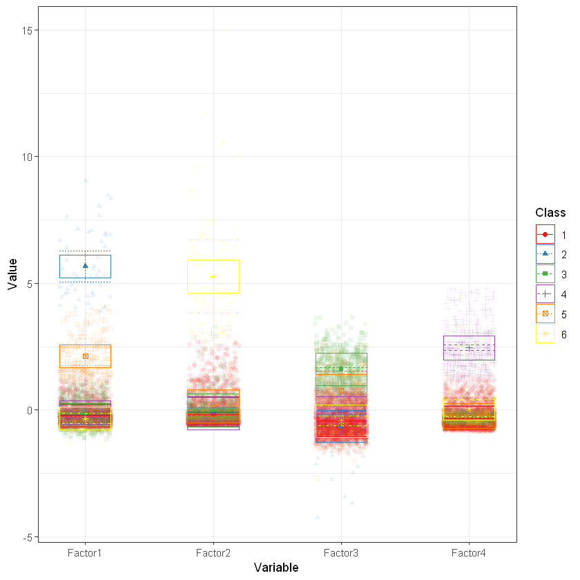

```r
plot_profiles(m4)
```

```r
class <- get_data(m4) %>% data.frame() # 각 관측값(고객)마다의 요인들 값이랑 클러스터 결과
head(class)  # 3248개의 관측치들의 각 팩터별 값과 군집 존재하는 데이터프레임
```

| model_number | classes_number | Factor1 | Factor2 | Factor3 | Factor4 | CPROB1 | CPROB2 | CPROB3 | CPROB4 | CPROB5 | CPROB6 | Class |
| --- | --- | --- | --- | --- | --- | --- | --- | --- | --- | --- | --- | --- |
| 1 | 6 | -0.1574704 | -0.4291192 | 0.4683624 | -0.5697607 | 0.8809343218 | 5.953685e-38 | 1.190652e-01 | 9.167167e-10 | 5.138477e-07 | 1.482841e-19 | 1 |
| 1 | 6 | -0.3911298 | -0.4541385 | -0.9618237 | -0.1494376 | 0.9999033209 | 2.311080e-40 | 9.663435e-05 | 4.399248e-08 | 7.152585e-10 | 2.856457e-19 | 1 |
| 1 | 6 | -0.3022930 | -0.1568773 | -0.6361723 | 1.3471582 | 0.2168572628 | 1.139890e-39 | 1.280937e-04 | 7.830146e-01 | 2.450761e-09 | 3.725710e-17 | 4 |
| 1 | 6 | -0.3008817 | -0.2693178 | 1.3601557 | -0.3307559 | 0.0734115403 | 6.435851e-41 | 9.265883e-01 | 2.499790e-09 | 1.472266e-07 | 1.591329e-19 | 3 |
| 1 | 6 | -0.1520937 | -0.4916247 | -0.7516159 | -0.3407829 | 0.9997159307 | 1.601864e-37 | 2.840456e-04 | 6.092175e-09 | 1.758345e-08 | 1.116421e-19 | 1 |
| 1 | 6 | -0.7913672 | -0.2544346 | 2.5397812 | -0.3073979 | 0.0002211692 | 1.034354e-49 | 9.997788e-01 | 1.886783e-11 | 6.029752e-11 | 7.642683e-22 | 3 |

### 각각의 프로파일에 속한 투자자의 수

```r
df_score$cluster <- class$Class   # 우리 데이터에 클러스터 변수 추가
df_score$cus_id <- out_scale_total_df$cus_id  # id도 부여

table(df_score$cluster) # 각 군집별 인원수
```

```
   1    2    3    4    5    6
2079   52  524  364  164   65
```

### 프로파일끼리 4개의 Factor (F, A, R, M)간의 차이가 서로 유의한지 검정

#### Krusckal test를 통해 유의하다는 것을 확인

```r
# 각 군집별 FARM의 유의한 차이가 있는지 재확인

col_name <- colnames(df_score)[1:4]
aov_result_df <- data.frame()

for (i in col_name){

  bar_data <- bartlett.test(eval(parse(text=i)) ~ cluster, data = df_score)
  bar_pvalue <- bar_data$p.value

  if(bar_pvalue < 0.05){

    krus_data <- kruskal.test(eval(parse(text=i)) ~ cluster, data = df_score)
    krus_pvalue <- krus_data$p.value

    krus_result <- ifelse(krus_pvalue < 0.05 , '기각','채택')
    aov_result <- '해당없음'

    p_value <- krus_pvalue
  } else {

    aov_data <- aov(eval(parse(text=i)) ~ cluster, data = df_score)
    aov_result <- summary(aov_data)
    aov_pvalue <- unlist(aov_result)[[9]]

    aov_result <- ifelse(aov_pvalue < 0.05 , '기각','채택')
    krus_result <- '해당없음'

    p_value <- aov_pvalue
  }

  aov_df <- data.frame(colname = i,
                       p_value = p_value,
                       aov_result = aov_result,
                       krus_result = krus_result)

  aov_result_df <- rbind(aov_result_df, aov_df)

}

aov_result_df ## 각 factor간의 차이가 군집간에 유의하다는 것을 재확인
```

| colname | p_value | aov_result | krus_result |
| --- | --- | --- | --- |
| Factor1 | 2.386091e-147 | 해당없음 | 기각 |
| Factor2 | 2.528560e-98 | 해당없음 | 기각 |
| Factor3 | 4.940656e-324 | 해당없음 | 기각 |
| Factor4 | 5.610054e-230 | 해당없음 | 기각 |

```r
cluster_df <- left_join(out_scale_total_df, df_score[,c(5,6)], by='cus_id')
```

```r
head(cluster_df)
```

| cus_id | freq_day_month_ratio | freq_day_minmonth_ratio | freq_day_ratio | sell_final_day | buy_final_day | final_trd_day | max_totpr | mean_1freq_totpr | mean_month_totpr | mean_iem_totpr | freq_mean_month | freq_mean_day | freq_max_mean_day | cluster |
| --- | --- | --- | --- | --- | --- | --- | --- | --- | --- | --- | --- | --- | --- | --- |
| f4545a81bb4691e5d74b45a4ba04298e9d770e2587189607e85d9b395b7a6ace | 0.4398474 | 0.5091607 | 0.2830820 | -0.7332146 | -0.43590849 | -0.61228809 | -0.05691302 | -0.20341260 | -0.06200300 | -0.13373679 | -0.08993236 | -0.03588079 | -0.06418519 | 1 |
| c132df3ee4822b5dea7d41d429ccdd63cd692e29c6b80e140afaaf9defd53e08 | -0.9793679 | -0.9508351 | -0.9714779 | -0.3391296 | -0.08578315 | 0.03809993 | -0.06229276 | -0.15640979 | -0.06684353 | -0.10176990 | -0.37382718 | -0.50600214 | -0.52262751 | 1 |
| 6a7d429d51dc365a1760a527cfbb071ce528df084b88347b29f9a948512725f1 | -1.0885383 | -1.0898823 | -1.1025347 | 2.0884338 | 1.11464658 | 1.45712833 | -0.05600943 | -0.03940987 | -0.06466200 | -0.02967082 | -0.37880779 | -0.50600214 | -0.43733591 | 4 |
| ca8373143fb9cf6d3ed8b476bb3a49cb098261d7a8ec3a75202948c43f5b8f2a | 1.0948699 | 1.1348732 | 1.3699412 | -0.6701610 | -0.53594430 | -0.49403572 | -0.03621122 | -0.16625338 | -0.04418346 | -0.10882458 | 0.06612678 | 0.03275952 | -0.10392332 | 3 |
| 5c2de509fc03c550c7975048dfc124d4f98c7b94379604453148270bb83bc0cc | -0.7246369 | -0.6032170 | -0.5344107 | -0.4021832 | -0.28585477 | -0.19840480 | -0.06367883 | -0.18475011 | -0.06510185 | -0.12419279 | -0.32900168 | -0.29231062 | -0.27741418 | 1 |
| 649ddc796ac94a7700b98d4bfbc9fe9050edf372be7d8178fc61207e948dbe37 | 1.9682332 | 1.9691564 | 1.5631034 | -0.6701610 | -0.63598011 | -0.61228809 | -0.05874810 | -0.18583987 | -0.05421079 | -0.11942562 | 0.13585533 | -0.07671962 | -0.06205290 | 3 |

## 2.3 Posterior Comparison Features (사후 비교 특성)

### 고객 프로파일을 완성한 뒤, 고객군마다의 차이와 특징을 발견하기 위해 사후비교특성 변수를 생성

#### 생성 변수 (사후 변수):

```
코스피 상위200종목 거래 비율, 코스닥 상위200종목 거래 비율, 추정 수익, 매수 비중, 투자금액 변동, 투자중심성(국내투자비중), 투자종목수
```

```r
kospi_top <- read.csv('kospi_Top.csv')   # 917 obs
kosdaq_top <- read.csv('kosdaq_Top.csv') # 1463 obs

colnames(kospi_top) <- c('iem_cd','iem_name','value')
colnames(kosdaq_top) <- c('iem_cd','iem_name','value')

# 시가총액을 기준으로 큰 변동이 없는 상위랭크 추출
kospi200 <- kospi_top[1:200,]
kosdaq200 <- kosdaq_top[1:200,]
```

```r
final_df <- data.frame()

suppressMessages(for (i in unique(trd_tot_yz20$cus_id)){
  cus_i_df <- trd_tot_yz20 %>% filter(cus_id == i)   # i 고객 주식 데이터만 filter

  ############### 코스피 / 코스닥 ####################################
  unique_trd_iem <- unique(cus_i_df$iem_cd)   # i고객 2020년 동안 거래한 주식 종목들(유니크)
  iem_tot_num <- n_distinct(cus_i_df$iem_cd) ##### i고객 2020년 동안 거래한 주식 종목 개수 (유니크)

  kospi_num <-  sum(substr(unique_trd_iem,2,7) %in%  kospi_top$iem_cd)  # i고객 거래한 종목 중 코스피 개수
  kosdaq_num <-  sum(substr(unique_trd_iem,2,7) %in%  kosdaq_top$iem_cd)  # i고객 거래한 종목 중 코스닥 개수

  kospi_ratio <- kospi_num / iem_tot_num ##### 2020년 투자종목 중 코스피 비율
  kosdaq_ratio <- kosdaq_num / iem_tot_num ##### 2020년 투자종목 중 코스닥 비율

  kospi200_num <-  sum(substr(unique_trd_iem,2,7) %in%  kospi200$iem_cd)  # i고객 거래한 종목 중 코스피200 개수
  kosdaq200_num <-  sum(substr(unique_trd_iem,2,7) %in%  kosdaq200$iem_cd)  # i고객 거래한 종목 중 코스닥200 개수

  kospi200_ratio <- kospi200_num / iem_tot_num ##### 2020년 투자종목 중 코스피200 비율
  kosdaq200_ratio <- kosdaq200_num / iem_tot_num ##### 2020년 투자종목 중 코스닥200 비율

  kospi200_kospi_ratio <- kospi200_num / kospi_num ##### 2020년 투자한 코스피주식 중 코스피200 비율
  kosdaq200_kosdaq_ratio <- kosdaq200_num / kosdaq_num ###### 2020년 투자한 코스닥주식 중 코스닥200 비율

  max_orrpr <- max(cus_i_df[, orr_pr])  ##### 2020년 거래한 종목 중 최대가격 (1주당)
  min_orrpr <- min(cus_i_df[, orr_pr])  ##### 2020년 거래한 종목 중 최소가격 (1주당)

  mean_orrpr_1 <- cus_i_df %>% group_by(iem_cd) %>% summarise(mean_orrpr = mean(orr_pr))
  mean_orrpr <- mean(mean_orrpr_1$mean_orrpr) ###### 2020년 투자종목 단가 평균 (iem 그룹별)


  ############################# 투자 중심성 ##################################
  cus_i_df_oss <- cus_i_df %>% filter(country == 'oss')  # i 고객 해외데이터만 filter
  cus_i_df_kr <- cus_i_df %>% filter(country == 'kr')  # i 고객 국내데이터만 filter

  oss_num <- n_distinct(cus_i_df_oss$iem_cd)  # i 고객 2020년동안 거래한 해외주식 수
  kr_num <- n_distinct(cus_i_df_kr$iem_cd)  # i 고객 2020년동안 거래한 국내주식 수

  if (oss_num == 0){
    oss_trd <- 0
  } else {
    oss_trd <- 1   # 해외 주식 경험 있으면 1, 없으면 0 범주화
  }

  kr_oss_iem_ratio <- kr_num / (oss_num + kr_num)  # 2020년 투자주식 중 국내주식 비율
  kr_oss_freq_ratio <- nrow(cus_i_df_kr) / nrow(cus_i_df)  # 전체 거래빈도 대비 국내 거래 빈도 비율
  kr_oss_totpr_ratio <- sum(cus_i_df_kr$tot_pr) / sum(cus_i_df$tot_pr) # 전체 금액 대비 국내 금액 비율


  ####################### 추정 수익 (+매도-매수) ###############################
   # 전체 쓴 금액 대비 매도금액 비율
  income_ratio <- sum(cus_i_df[cus_i_df$sby_dit_cd==1,tot_pr]) / sum(cus_i_df$tot_pr)
   # 매도금액 총합 - 매수금액 총합
  income_totpr <- sum(cus_i_df[cus_i_df$sby_dit_cd==1,tot_pr]) - sum(cus_i_df[cus_i_df$sby_dit_cd==2,tot_pr])


  ##################### 계좌 수 관련 변수들 ####################################
  cus_act_id <- act_info %>% filter(cus_id == i) %>% select(act_id) # 보유 계좌
  act_num <- nrow(cus_act_id)  ####### 보유 계좌 수
  act_trd_num <-  n_distinct(cus_i_df$act_id)  # 거래중인 계좌
  trd_act_ratio <- act_trd_num / act_num  ###### 전체 계좌 수 대비 거래중인 계좌 비율


  ####################### 매수 비중 #############################################
  buy_qty_ratio <- sum(cus_i_df[cus_i_df$sby_dit_cd==2,cns_qty]) / sum(cus_i_df$cns_qty)

  qty_sum <- aggregate(cns_qty ~ iem_cd, cus_i_df, sum)  # 종목별 (매수,매도) 수량 합계

  if (nrow(cus_i_df[sby_dit_cd == 2,]) != 0){
  qty_buy_sum <- aggregate(cns_qty ~ iem_cd, cus_i_df[sby_dit_cd == 2,] , sum)  # 종목별 (매수) 수량 합계
  colnames(qty_buy_sum) <- c('iem_cd', 'buy_cns_qty')

  qty_df <- left_join(qty_sum, qty_buy_sum,by = 'iem_cd') %>% mutate(iem_buy_qty_ratio = buy_cns_qty /cns_qty)
  qty_df$iem_buy_qty_ratio[which(is.na(qty_df$iem_buy_qty_ratio))] <- 0

  iem_buy_qty_ratio_mean <- mean(qty_df$iem_buy_qty_ratio)   # 종목당 (매수/(매수+매도)) 주식량의 평균

  } else {
    iem_buy_qty_ratio_mean <- 0
  }# 종목당 (매수하는 횟수 /(매수+매도)횟수) 의 평균

  freq_sum <- cus_i_df %>% group_by(iem_cd) %>% summarise(freq = n())  # 종목별 전체 빈도수 합 (매수+매도)
  freq_buy_sum <- cus_i_df %>% filter(sby_dit_cd == 2) %>% group_by(iem_cd) %>% summarise(buy_freq = n())  # 종목별 매수 빈도수 합
  freq_sum_df <- left_join(freq_sum, freq_buy_sum, by='iem_cd') %>% mutate(iem_buy_freq_ratio = buy_freq / freq)
  freq_sum_df$iem_buy_freq_ratio[which(is.na(freq_sum_df$iem_buy_freq_ratio))] <- 0

  iem_buy_freq_ratio_mean <- mean(freq_sum_df$iem_buy_freq_ratio) # 종목당 (매수/(매도+매수)) 빈도수의 평균


  ####################### 투자 금액 변동(폭) #############################################
  buy_iem_mean_df <- cus_i_df %>% filter(sby_dit_cd == 2 ) %>% group_by(iem_cd) %>% summarise(buy_mean_totpr = mean(tot_pr))

  iem_buy_mean_totpr_range <- with(buy_iem_mean_df, max(buy_mean_totpr) - min(buy_mean_totpr))
  iem_buy_totpr_CV <- sd(buy_iem_mean_df$buy_mean_totpr) / mean(buy_iem_mean_df$buy_mean_totpr)

  if (sum(unique_trd_iem %in% 'A005930') == 0){
    samsung <- 0
  } else {
    samsung <- 1
  }  # 삼성 주식 경험이 있으면 1, 없으면 0 범주화

  cus_yq_df <- data.frame(cus_id = i,
                          iem_tot_num = iem_tot_num,
                          kospi_ratio = kospi_ratio,
                          kosdaq_ratio = kosdaq_ratio,
                          kospi200_ratio = kospi200_ratio,
                          kosdaq200_ratio = kosdaq200_ratio,
                          kospi200_kospi_ratio = kospi200_kospi_ratio,
                          kosdaq200_kosdaq_ratio = kosdaq200_kosdaq_ratio,
                          max_orrpr = max_orrpr,
                          min_orrpr = min_orrpr,
                          mean_orrpr = mean_orrpr,

                          oss_trd = oss_trd,
                          kr_oss_iem_ratio = kr_oss_iem_ratio,
                          kr_oss_freq_ratio = kr_oss_freq_ratio,
                          kr_oss_totpr_ratio = kr_oss_totpr_ratio,

                          income_ratio = income_ratio,
                          income_totpr = income_totpr,

                          act_num = act_num,
                          trd_act_ratio = trd_act_ratio,

                          buy_qty_ratio = buy_qty_ratio,
                          iem_buy_qty_ratio_mean = iem_buy_qty_ratio_mean,
                          iem_buy_freq_ratio_mean = iem_buy_freq_ratio_mean,

                          iem_buy_mean_totpr_range = iem_buy_mean_totpr_range,
                          iem_buy_totpr_CV = iem_buy_totpr_CV,

                          samsung = samsung
                          )

  final_df <- rbind(final_df, cus_yq_df)

}
)
```

```r
## NA,-Inf: 0 처리
final_df$kospi200_kospi_ratio[which(is.na(final_df$kospi200_kospi_ratio))] <- 0
final_df$kosdaq200_kosdaq_ratio[which(is.na(final_df$kosdaq200_kosdaq_ratio))] <- 0
final_df$iem_buy_totpr_CV[which(is.na(final_df$iem_buy_totpr_CV))] <- 0
final_df$iem_buy_mean_totpr_range[which(final_df$iem_buy_mean_totpr_range < 0)] <- 0
```

```r
final_df <- left_join(final_df,cluster_df, by='cus_id')

final_df$kospi200_kospi_ratio[which(is.na(final_df$kospi200_kospi_ratio))] <- 0  ###
final_df$kosdaq200_kosdaq_ratio[which(is.na(final_df$kosdaq200_kosdaq_ratio))] <- 0 ###
final_df$iem_buy_totpr_CV[which(is.na(final_df$iem_buy_totpr_CV))] <- 0 ###
final_df$iem_buy_mean_totpr_range[which(final_df$iem_buy_mean_totpr_range < 0)] <- 0 ###

final_df <- na.omit(final_df)   # final_df는 기존에 cluster_df에서 이상치로서 제거된 사람이 포함되므로 이들을 제거
head(final_df)
```

| cus_id | iem_tot_num | kospi_ratio | kosdaq_ratio | kospi200_ratio | kosdaq200_ratio | kospi200_kospi_ratio | kosdaq200_kosdaq_ratio | max_orrpr | min_orrpr | ... | buy_final_day | final_trd_day | max_totpr | mean_1freq_totpr | mean_month_totpr | mean_iem_totpr | freq_mean_month | freq_mean_day | freq_max_mean_day | cluster |
| --- | --- | --- | --- | --- | --- | --- | --- | --- | --- | --- | --- | --- | --- | --- | --- | --- | --- | --- | --- | --- |
| f4545a81bb4691e5d74b45a4ba04298e9d770e2587189607e85d9b395b7a6ace | 17 | 0.7058824 | 0.2941176 | 0.52941176 | 0.05882353 | 0.7500000 | 0.2000000 | 232000 | 951 | ... | -0.43590849 | -0.61228809 | -0.05691302 | -0.20341260 | -0.06200300 | -0.13373679 | -0.08993236 | -0.03588079 | -0.06418519 | 1 |
| c132df3ee4822b5dea7d41d429ccdd63cd692e29c6b80e140afaaf9defd53e08 | 2 | 1.0000000 | 0.0000000 | 1.00000000 | 0.00000000 | 1.0000000 | 0.0000000 | 111000 | 37400 | ... | -0.08578315 | 0.03809993 | -0.06229276 | -0.15640979 | -0.06684353 | -0.10176990 | -0.37382718 | -0.50600214 | -0.52262751 | 1 |
| 6a7d429d51dc365a1760a527cfbb071ce528df084b88347b29f9a948512725f1 | 1 | 1.0000000 | 0.0000000 | 0.00000000 | 0.00000000 | 0.0000000 | 0.0000000 | 2625 | 2625 | ... | 1.11464658 | 1.45712833 | -0.05600943 | -0.03940987 | -0.06466200 | -0.02967082 | -0.37880779 | -0.50600214 | -0.43733591 | 4 |
| ca8373143fb9cf6d3ed8b476bb3a49cb098261d7a8ec3a75202948c43f5b8f2a | 56 | 0.3392857 | 0.6607143 | 0.08928571 | 0.08928571 | 0.2631579 | 0.1351351 | 44400 | 83 | ... | -0.53594430 | -0.49403572 | -0.03621122 | -0.16625338 | -0.04418346 | -0.10882458 | 0.06612678 | 0.03275952 | -0.10392332 | 3 |
| 5c2de509fc03c550c7975048dfc124d4f98c7b94379604453148270bb83bc0cc | 8 | 0.6250000 | 0.2500000 | 0.37500000 | 0.12500000 | 0.6000000 | 0.5000000 | 250000 | 280 | ... | -0.28585477 | -0.19840480 | -0.06367883 | -0.18475011 | -0.06510185 | -0.12419279 | -0.32900168 | -0.29231062 | -0.27741418 | 1 |
| 649ddc796ac94a7700b98d4bfbc9fe9050edf372be7d8178fc61207e948dbe37 | 24 | 0.7083333 | 0.2916667 | 0.66666667 | 0.16666667 | 0.9411765 | 0.5714286 | 386500 | 1375 | ... | -0.63598011 | -0.61228809 | -0.05874810 | -0.18583987 | -0.05421079 | -0.11942562 | 0.13585533 | -0.07671962 | -0.06205290 | 3 |

# 3. Results (결과)

## 3.1 Profile Interpretation (프로파일 해석)

### 각 프로파일별 투자자 수

```r
table(df_score$cluster) # 각 군집별 인원수
Profile_data= class %>% group_by(Class) %>% summarize(Median_Factor1=median(Factor1),
                                                      SD_Factor1=sd(Factor1),
                                                      Median_Factor2=median(Factor2),
                                                      SD_Factor2=sd(Factor2),
                                                      Median_Factor3=median(Factor3),
                                                      SD_Factor3=sd(Factor3),
                                                      Median_Factor4=median(Factor4),
                                                      SD_Factor4=sd(Factor4))
colnames(Profile_data)[1] <- "Profile"
Profile_data
```

```
   1    2    3    4    5    6
2079   52  524  364  164   65
```

| Profile | Median_Factor1 | SD_Factor1 | Median_Factor2 | SD_Factor2 | Median_Factor3 | SD_Factor3 | Median_Factor4 | SD_Factor4 |
| --- | --- | --- | --- | --- | --- | --- | --- | --- |
| 1 | -0.3240868 | 0.3507884 | -0.36209926 | 0.5599290 | -0.5367295 | 0.5658500 | -0.4796673 | 0.4199211 |
| 2 | 5.3466656 | 1.2959774 | -0.06096112 | 0.2484184 | -0.2777737 | 1.2951866 | -0.1756432 | 0.2559791 |
| 3 | -0.2961543 | 0.5387150 | -0.19909262 | 0.4838433 | 1.5779450 | 0.6020076 | -0.3448442 | 0.1711713 |
| 4 | -0.2405421 | 0.3593685 | -0.38231033 | 0.6488147 | -0.1734202 | 0.3680063 | 2.3032241 | 0.8649095 |
| 5 | 1.9054539 | 0.7756876 | -0.07849686 | 0.6776760 | 0.7753854 | 1.0676262 | -0.2729416 | 0.2709262 |
| 6 | -0.4823700 | 0.6760118 | 4.64996335 | 2.3109633 | -0.5080179 | 0.7224977 | -0.3474861 | 1.0871357 |

### 각 프로파일별 Factor값

- 빈도(F; Frequency): 얼마나 자주 거래하는가? 거래하는 날의 빈도가 어느 정도인가?
- 적극성(A;Attention): 하루에 보통 얼마나 거래를 여러번 많이 하는가? / 집중적으로 거래횟수를 많이 하는가?
- 최근성(R; Recency): 얼마나 최근에 거래하였는가?
- 규모(M; Monetary): 거래금액의 규모가 어느 정도인가?

```r
# Profile 기준:  +-1시그마: 중앙값으로부터 +-34.13%범위(68.26%), +-0.13시그마: 중앙값으로부터 +-5.17%범위(10.34%)
Profile_data$Frequency <- ifelse(Profile_data$Median_Factor1 > median(class$Factor1)+sd(class$Factor1),"VeryHigh",
                                  ifelse(Profile_data$Median_Factor1 > median(class$Factor1)+0.13*sd(class$Factor1), "High",
                                        ifelse(Profile_data$Median_Factor1 > median(class$Factor1)-0.13*sd(class$Factor1), "Mid",
                                               ifelse(Profile_data$Median_Factor1 > median(class$Factor1)-sd(class$Factor1),"Low","VeryLow"))))
Profile_data$Monetary <- ifelse(Profile_data$Median_Factor2 > median(class$Factor2)+sd(class$Factor2),"VeryHigh",
                                  ifelse(Profile_data$Median_Factor2 > median(class$Factor2)+0.13*sd(class$Factor2), "High",
                                        ifelse(Profile_data$Median_Factor2 > median(class$Factor2)-0.13*sd(class$Factor2), "Mid",
                                               ifelse(Profile_data$Median_Factor2 > median(class$Factor2)-sd(class$Factor2),"Low","VeryLow"))))
Profile_data$Attention <- ifelse(Profile_data$Median_Factor3 > median(class$Factor3)+sd(class$Factor3),"VeryHigh",
                                  ifelse(Profile_data$Median_Factor3 > median(class$Factor3)+0.13*sd(class$Factor3), "High",
                                        ifelse(Profile_data$Median_Factor3 > median(class$Factor3)-0.13*sd(class$Factor3), "Mid",
                                               ifelse(Profile_data$Median_Factor3 > median(class$Factor3)-sd(class$Factor3),"Low","VeryLow"))))
Profile_data$Recency <- ifelse(Profile_data$Median_Factor4 > median(class$Factor4)+sd(class$Factor4),"VeryHigh",
                                  ifelse(Profile_data$Median_Factor4 > median(class$Factor4)+0.13*sd(class$Factor4), "High",
                                        ifelse(Profile_data$Median_Factor4 > median(class$Factor4)-0.13*sd(class$Factor4), "Mid",
                                               ifelse(Profile_data$Median_Factor4 > median(class$Factor4)-sd(class$Factor4),"Low","VeryLow"))))
Profile_data[,c("Profile","Frequency","Attention","Recency","Monetary")]
```

| Profile | Frequency | Attention | Recency | Monetary |
| --- | --- | --- | --- | --- |
| 1 | Mid | Low | Mid | Mid |
| 2 | VeryHigh | Mid | High | High |
| 3 | Mid | VeryHigh | Mid | Mid |
| 4 | Mid | Mid | VeryHigh | Mid |
| 5 | VeryHigh | VeryHigh | Mid | High |
| 6 | Low | Low | Mid | VeryHigh |

## FARM 분석 결과: 고객 프로파일링 이미지

### (F, A, R을 축으로 3차원 모델)

```
 (M값이 Mid인 경우 검정색이고, High 또는 VeryHigh인 경우 빨간색)
```

[figure not shown]

## 3.2 Character Extraction (특징 추출)

### 앞서 설정한 사후변수가 각 고객 프로파일별로 유의한 차이가 존재하는지 검정

```
결과: 유의하지 않다고 나온 변수인 {전체 소유 계좌 대비 거래하는 계좌 비율, 계좌 수} 제거
```

```r
# 정규성은 N>>30이므로 확보

# "등분산"으로 Bartlett 검정으로 판단.
## 등분산 이면--> ANOVA
## 등분산 아니면-->Kruskal


### 동질성 bartlett 검정
## H0 : 동질적이다.
## H1 : 이질적이다.
## p-value < 0.05 이면 H0기각 ===> kruskal 검정 시행

## ANOVA or Kruskal 검정 가설
## H0 : 집단간 평균의 차이가 없다
## H1 : 집단간 평균의 차이가 있다.
## p-value < 0.05 이면 H0기각 ===> 차이 있다.

col_name <- colnames(final_df)[c(2:11,13:24)]

aov_result_df <- data.frame()

for (i in col_name){

  bar_data <- bartlett.test(eval(parse(text=i)) ~ cluster, data = final_df)
  bar_pvalue <- bar_data$p.value

  if(bar_pvalue < 0.05){

  krus_data <- kruskal.test(eval(parse(text=i)) ~ cluster, data = final_df)
  krus_pvalue <- krus_data$p.value

  krus_result <- ifelse(krus_pvalue < 0.05 , '기각','채택')
  aov_result <- '해당없음'

  p_value <- krus_pvalue
  } else {

  aov_data <- aov(eval(parse(text=i)) ~ cluster, data = final_df)
  aov_result <- summary(aov_data)
  aov_pvalue <- unlist(aov_result)[[9]]

  aov_result <- ifelse(aov_pvalue < 0.05 , '기각','채택')
  krus_result <- '해당없음'

  p_value <- aov_pvalue
  }

  aov_df <- data.frame(colname = i,
                       p_value = p_value,
                       ANOVA_result = aov_result,
                       Kruskal_test_result = krus_result)

  aov_result_df <- rbind(aov_result_df, aov_df)

}

aov_result_df %>%
  arrange(p_value)  ## 각 사후 변수들에 대해서 집단 별 차이가 유의하다!! 보여주기
```

| colname | p_value | ANOVA_result | Kruskal_test_result |
| --- | --- | --- | --- |
| iem_tot_num | 0.000000e+00 | 해당없음 | 기각 |
| min_orrpr | 1.013551e-164 | 해당없음 | 기각 |
| iem_buy_mean_totpr_range | 3.139927e-105 | 해당없음 | 기각 |
| max_orrpr | 1.318353e-100 | 해당없음 | 기각 |
| iem_buy_totpr_CV | 2.101918e-93 | 해당없음 | 기각 |
| income_ratio | 1.925890e-75 | 해당없음 | 기각 |
| iem_buy_qty_ratio_mean | 7.118160e-70 | 해당없음 | 기각 |
| kosdaq_ratio | 3.306209e-69 | 해당없음 | 기각 |
| buy_qty_ratio | 3.028419e-65 | 해당없음 | 기각 |
| kosdaq200_ratio | 3.764759e-58 | 해당없음 | 기각 |
| income_totpr | 2.068513e-51 | 해당없음 | 기각 |
| iem_buy_freq_ratio_mean | 3.693609e-50 | 해당없음 | 기각 |
| kosdaq200_kosdaq_ratio | 1.005436e-43 | 해당없음 | 기각 |
| kospi200_ratio | 3.228192e-41 | 해당없음 | 기각 |
| kospi200_kospi_ratio | 2.689683e-36 | 해당없음 | 기각 |
| kospi_ratio | 1.205206e-34 | 해당없음 | 기각 |
| mean_orrpr | 2.403943e-13 | 해당없음 | 기각 |
| kr_oss_totpr_ratio | 1.058534e-05 | 해당없음 | 기각 |
| kr_oss_freq_ratio | 1.096408e-05 | 해당없음 | 기각 |
| kr_oss_iem_ratio | 1.223155e-05 | 해당없음 | 기각 |
| trd_act_ratio | 1.578750e-01 | 채택 | 해당없음 |
| act_num | 1.609446e-01 | 채택 | 해당없음 |

```r
final_df$cluster <- as.factor(final_df$cluster)
col_2 <- c('#FA6368','#FACC2A', '#62B578','#3C50FA','#8b00ff','#999999')
```

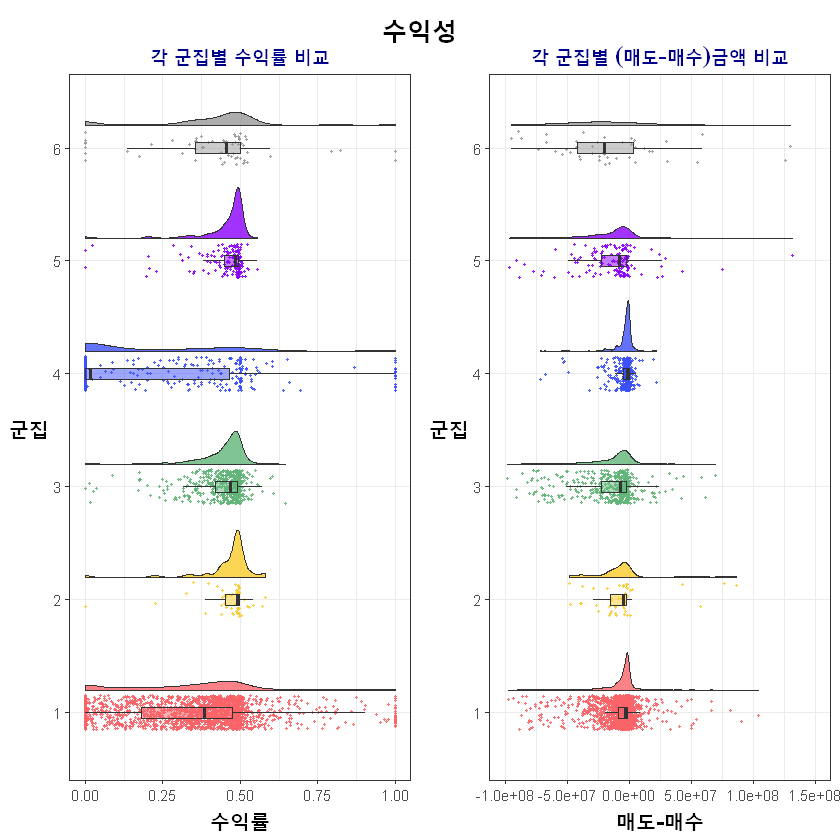

```r
########### 1. 추정 수익 :: income_ratio / income_totpr ###############

### income_ratio ==> 매도금액 / (매수+매도)금액

theme_1 <- theme(axis.title.x = element_text(size  = 15, face  = "bold", angle = 0, vjust = 0.5),
                 axis.title.y = element_text(size  = 15, face  = "bold", angle = 0, vjust = 0.5),
                 legend.position="none",
                 plot.title = element_text(family = "serif", face = "bold", hjust = 0.5, size = 15, color = "darkblue"))


### income_ratio ==> 매도금액 / (매수+매도)금액

a <- final_df %>%
  ggplot(aes(cluster,income_ratio, fill=cluster))+
  geom_flat_violin(position = position_nudge(x = .2, y = 0), alpha = .8) +
  geom_point(aes(y = income_ratio, color = cluster), position = position_jitter(width = .15), size = .5, alpha = 0.8) +
  geom_boxplot(width = .1, outlier.shape = NA, alpha = 0.5) +
  expand_limits(x = 5.25) +
  scale_color_manual(values =col_2) + scale_fill_manual(values =col_2) +
  coord_flip() +
  theme_bw() +
  theme_1 +  xlab('군집') + ylab('수익률') +
  ggtitle("각 군집별 수익률 비교")

### income_totpr ==> 매도금액 - 매수금액

b <- final_df %>%
  ggplot(aes(cluster,income_totpr, fill=cluster))+
  geom_flat_violin(position = position_nudge(x = .2, y = 0), alpha = .8) +
  geom_point(aes(y = income_totpr, color = cluster), position = position_jitter(width = .15), size = .5, alpha = 0.8) +
  geom_boxplot(width = .1, outlier.shape = NA, alpha = 0.5) +
  expand_limits(x = 5.25) +
  scale_color_manual(values =col_2) + scale_fill_manual(values =col_2) +
  coord_flip() +
  theme_bw() +xlab('군집') + ylab('매도-매수') +
  ggtitle("각 군집별 (매도-매수)금액 비교") + theme_1 +
  scale_y_continuous(limits = c(-100000000,150000000)) # 시각적 위해 81 제거됨


grid.arrange(a,b,nrow= 1,ncol=2,
             top = textGrob("수익성", vjust = 1, gp = gpar(fontface = "bold", cex = 1.5)))
```

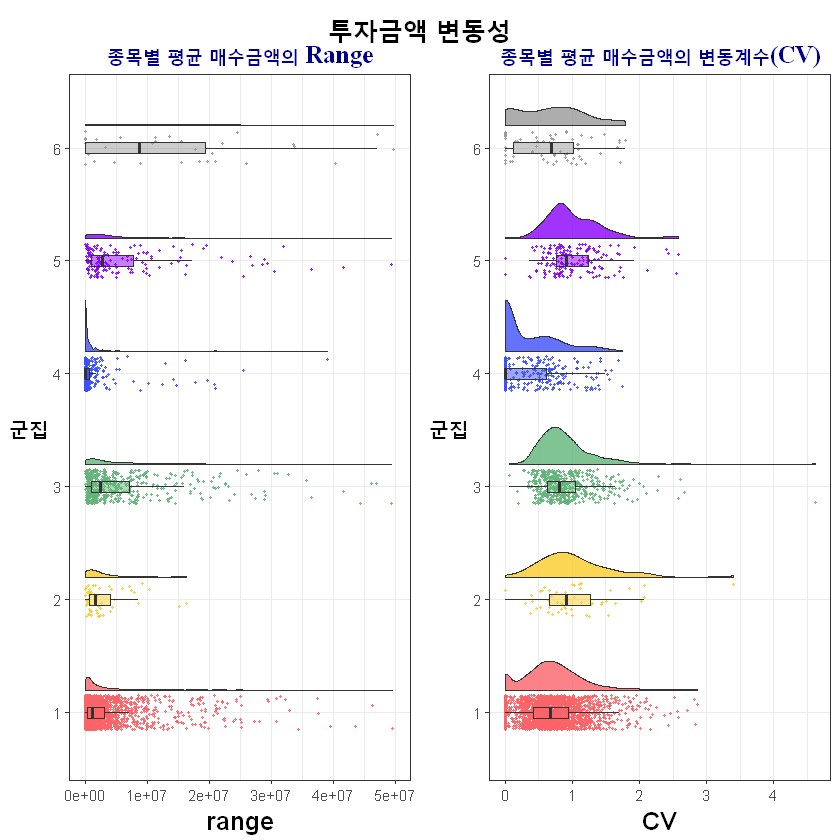

```r
############# 2. 투자금액 변동 :: iem_buy_mean_totpr_range / iem_buy_totpr_CV ############

### iem_buy_mean_totpr_range ==> 종목당 평균 매수금액의 (최댓값 - 최소값)

### iem_buy_mean_totpr_range ==> 종목당 평균 매수금액의 (최댓값 - 최소값)

a <- final_df %>%
  ggplot(aes(cluster,iem_buy_mean_totpr_range, fill=cluster))+
  geom_flat_violin(position = position_nudge(x = .2, y = 0), alpha = .8) +
  geom_point(aes(y = iem_buy_mean_totpr_range, color = cluster), position = position_jitter(width = .15), size = .5, alpha = 0.8) +
  geom_boxplot(width = .1, outlier.shape = NA, alpha = 0.5) +
  expand_limits(x = 5.25) +
  scale_color_manual(values =col_2) + scale_fill_manual(values =col_2) +
  coord_flip() + theme_bw() + xlab('군집') + ylab('range') +
  ggtitle("종목별 평균 매수금액의 Range") + theme_1 +
  scale_y_continuous(limits = c(0,50000000))


### iem_buy_totpr_CV ==> 종목당 평균 매수금액의 변동계수 ########################

b <- final_df %>%
  ggplot(aes(cluster,iem_buy_totpr_CV, fill=cluster))+
  geom_flat_violin(position = position_nudge(x = .2, y = 0), alpha = .8) +
  geom_point(aes(y = iem_buy_totpr_CV, color = cluster), position = position_jitter(width = .15), size = .5, alpha = 0.8) +
  geom_boxplot(width = .1, outlier.shape = NA, alpha = 0.5) +
  expand_limits(x = 5.25) +
  scale_color_manual(values =col_2) + scale_fill_manual(values =col_2) +
  coord_flip() +
  theme_bw() + xlab('군집') + ylab('CV') +
  ggtitle("종목별 평균 매수금액의 변동계수(CV)") + theme_1


grid.arrange(a,b,nrow= 1,ncol=2,
             top = textGrob("투자금액 변동성", vjust = 1, gp = gpar(fontface = "bold", cex = 1.5)))
```

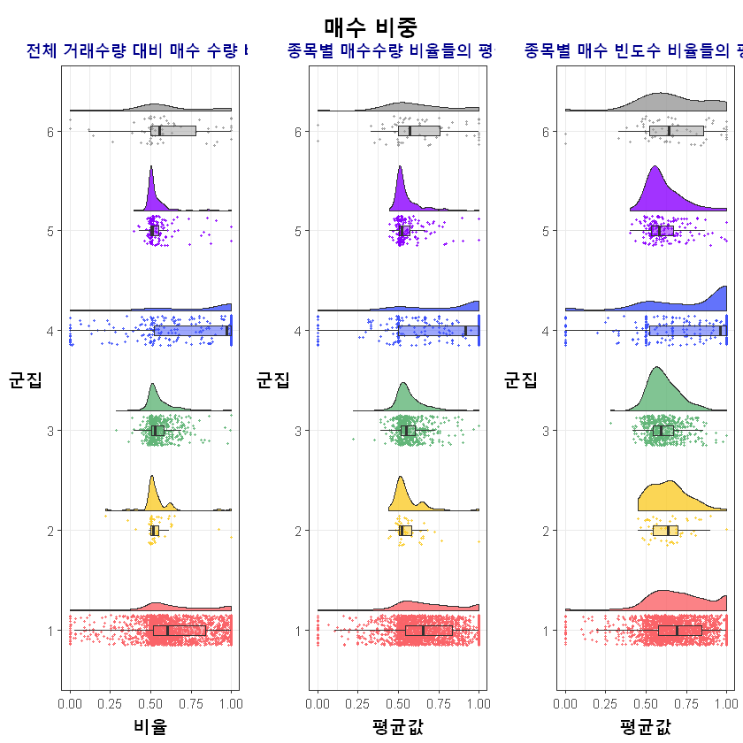

```r
############### 3. 매수비중 :: buy_qty_ratio / iem_buy_qty_ratio_mean / iem_buy_freq_ratio_mean  ######

### buy_qty_ratio ==> 전체 수량 대비 매수 수량 비율

a <- final_df %>%
  ggplot(aes(cluster,buy_qty_ratio, fill=cluster))+
  geom_flat_violin(position = position_nudge(x = .2, y = 0), alpha = .8) +
  geom_point(aes(y = buy_qty_ratio, color = cluster), position = position_jitter(width = .15), size = .5, alpha = 0.8) +
  geom_boxplot(width = .1, outlier.shape = NA, alpha = 0.5) +
  expand_limits(x = 5.25) +
  scale_color_manual(values =col_2) + scale_fill_manual(values =col_2) +
  coord_flip() + theme_bw() + xlab('군집') + ylab('비율') +
  ggtitle("전체 거래수량 대비 매수 수량 비율") + theme_1


### iem_buy_qty_ratio_mean ==> 종목당 {매수수량/(매수+매도)수량}를 구한 비율들의 평균값

b <- final_df %>%
  ggplot(aes(cluster,iem_buy_qty_ratio_mean, fill=cluster))+
  geom_flat_violin(position = position_nudge(x = .2, y = 0), alpha = .8) +
  geom_point(aes(y = iem_buy_qty_ratio_mean, color = cluster), position = position_jitter(width = .15), size = .5, alpha = 0.8) +
  geom_boxplot(width = .1, outlier.shape = NA, alpha = 0.5) +
  expand_limits(x = 5.25) +
  scale_color_manual(values =col_2) + scale_fill_manual(values =col_2) +
  coord_flip() + theme_bw()+ xlab('군집') + ylab('평균값') +
  ggtitle("종목별 매수수량 비율들의 평균") + theme_1


### iem_buy_freq_ratio_mean ==> 종목당 (매수횟수/총횟수) 을 구한 비율들의 평균값

c <- final_df %>%
  ggplot(aes(cluster,iem_buy_freq_ratio_mean, fill=cluster))+
  geom_flat_violin(position = position_nudge(x = .2, y = 0), alpha = .8) +
  geom_point(aes(y = iem_buy_freq_ratio_mean, color = cluster), position = position_jitter(width = .15), size = .5, alpha = 0.8) +
  geom_boxplot(width = .1, outlier.shape = NA, alpha = 0.5) +
  expand_limits(x = 5.25) +
  scale_color_manual(values =col_2) + scale_fill_manual(values =col_2) +
  coord_flip() + theme_bw() + xlab('군집') + ylab('평균값') +
  ggtitle("종목별 매수 빈도수 비율들의 평균") + theme_1


grid.arrange(a,b,c,nrow=1,ncol=3,
             top = textGrob("매수 비중", vjust = 1, gp = gpar(fontface = "bold", cex = 1.5)))
```

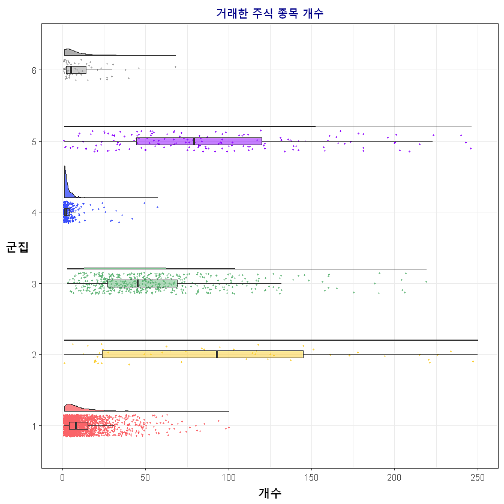

```r
############### 4. 종목수 / 코스피  ################

### iem_tot_num ==> 2020년 동안 거래한 주식 종목 개수 (유니크)

final_df %>%
  ggplot(aes(cluster,iem_tot_num, fill=cluster))+
  geom_flat_violin(position = position_nudge(x = .2, y = 0), alpha = .8) +
  geom_point(aes(y = iem_tot_num, color = cluster), position = position_jitter(width = .15), size = .5, alpha = 0.8) +
  geom_boxplot(width = .1, outlier.shape = NA, alpha = 0.5) +
  expand_limits(x = 5.25) +
  scale_color_manual(values =col_2) + scale_fill_manual(values =col_2) +
  coord_flip() + theme_bw() +  xlab('군집') + ylab('개수') +
  ggtitle("거래한 주식 종목 개수") + theme_1 +
  scale_y_continuous(limits = c(0,250))
```

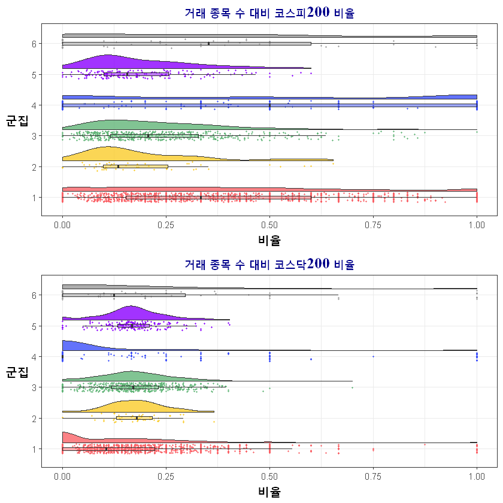

```r
### kospi200_ratio & kosdaq200_ratio ==> 전체 종목 수 대비 코스피200 & 코스닥200 비율

a <- final_df %>%
  ggplot(aes(cluster,kospi200_ratio, fill=cluster))+
  geom_flat_violin(position = position_nudge(x = .2, y = 0), alpha = .8) +
  geom_point(aes(y = kospi200_ratio, color = cluster), position = position_jitter(width = .15), size = .5, alpha = 0.8) +
  geom_boxplot(width = .1, outlier.shape = NA, alpha = 0.5) +
  expand_limits(x = 5.25) +
  scale_color_manual(values =col_2) + scale_fill_manual(values =col_2) +
  coord_flip() +theme_bw()+ xlab('군집') + ylab('비율') +
  ggtitle("거래 종목 수 대비 코스피200 비율") + theme_1

b <- final_df %>%
  ggplot(aes(cluster,kosdaq200_ratio, fill=cluster))+
  geom_flat_violin(position = position_nudge(x = .2, y = 0), alpha = .8) +
  geom_point(aes(y = kosdaq200_ratio, color = cluster), position = position_jitter(width = .15), size = .5, alpha = 0.8) +
  geom_boxplot(width = .1, outlier.shape = NA, alpha = 0.5) +
  expand_limits(x = 5.25) +
  scale_color_manual(values =col_2) + scale_fill_manual(values =col_2) +
  coord_flip() +theme_bw() + xlab('군집') + ylab('비율') +
  ggtitle("거래 종목 수 대비 코스닥200 비율") + theme_1

grid.arrange(a,b,nrow = 2,ncol =1)
```

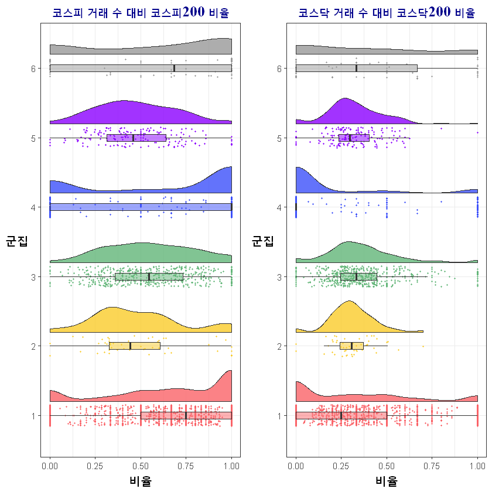

```r
### kospi200_kospi_ratio / kosdaq200_kosdaq_ratio ==> 코스피/코스닥 대비 200 비율

a <- final_df %>%
  ggplot(aes(cluster,kospi200_kospi_ratio, fill=cluster))+
  geom_flat_violin(position = position_nudge(x = .2, y = 0), alpha = .8) +
  geom_point(aes(y = kospi200_kospi_ratio, color = cluster), position = position_jitter(width = .15), size = .5, alpha = 0.8) +
  geom_boxplot(width = .1, outlier.shape = NA, alpha = 0.5) +
  expand_limits(x = 5.25) +
  scale_color_manual(values =col_2) + scale_fill_manual(values =col_2) +
  coord_flip() +theme_bw() +
  xlab('군집') + ylab('비율') +
  ggtitle("코스피 거래 수 대비 코스피200 비율") + theme_1

b <- final_df %>%
  ggplot(aes(cluster,kosdaq200_kosdaq_ratio, fill=cluster))+
  geom_flat_violin(position = position_nudge(x = .2, y = 0), alpha = .8) +
  geom_point(aes(y = kosdaq200_kosdaq_ratio, color = cluster), position = position_jitter(width = .15), size = .5, alpha = 0.8) +
  geom_boxplot(width = .1, outlier.shape = NA, alpha = 0.5) +
  expand_limits(x = 5.25) +
  scale_color_manual(values =col_2) + scale_fill_manual(values =col_2) +
  coord_flip() +theme_bw() + xlab('군집') + ylab('비율') +
  ggtitle("코스닥 거래 수 대비 코스닥200 비율") + theme_1

grid.arrange(a,b,nrow=1,ncol=2)
```

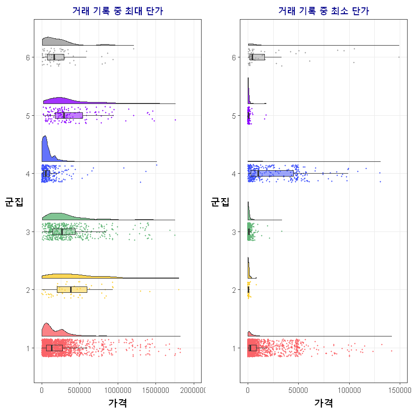

```r
############## 주식 단가 관련 ==> max_orrpr / min_orrpr / mean_orrpr #######################

a <- final_df %>%
  ggplot(aes(cluster,max_orrpr, fill=cluster))+
  geom_flat_violin(position = position_nudge(x = .2, y = 0), alpha = .8) +
  geom_point(aes(y = max_orrpr, color = cluster), position = position_jitter(width = .15), size = .5, alpha = 0.8) +
  geom_boxplot(width = .1, outlier.shape = NA, alpha = 0.5) +
  expand_limits(x = 5.25) +
  scale_color_manual(values =col_2) + scale_fill_manual(values =col_2) +
  coord_flip() +theme_bw() + xlab('군집') + ylab('가격') +
  ggtitle("거래 기록 중 최대 단가") + theme_1 +  scale_y_continuous(limits = c(0,2000000) )

b <- final_df %>%
  ggplot(aes(cluster,min_orrpr, fill=cluster))+
  geom_flat_violin(position = position_nudge(x = .2, y = 0), alpha = .8) +
  geom_point(aes(y = min_orrpr, color = cluster), position = position_jitter(width = .15), size = .5, alpha = 0.8) +
  geom_boxplot(width = .1, outlier.shape = NA, alpha = 0.5) +
  expand_limits(x = 5.25) +
  scale_color_manual(values =col_2) + scale_fill_manual(values =col_2) +
  coord_flip() +theme_bw()+ xlab('군집') + ylab('가격') +
  ggtitle("거래 기록 중 최소 단가") +
  scale_y_continuous(limits = c(0,150000)) + theme_1

grid.arrange(a,b,nrow = 1,ncol = 2 )
```

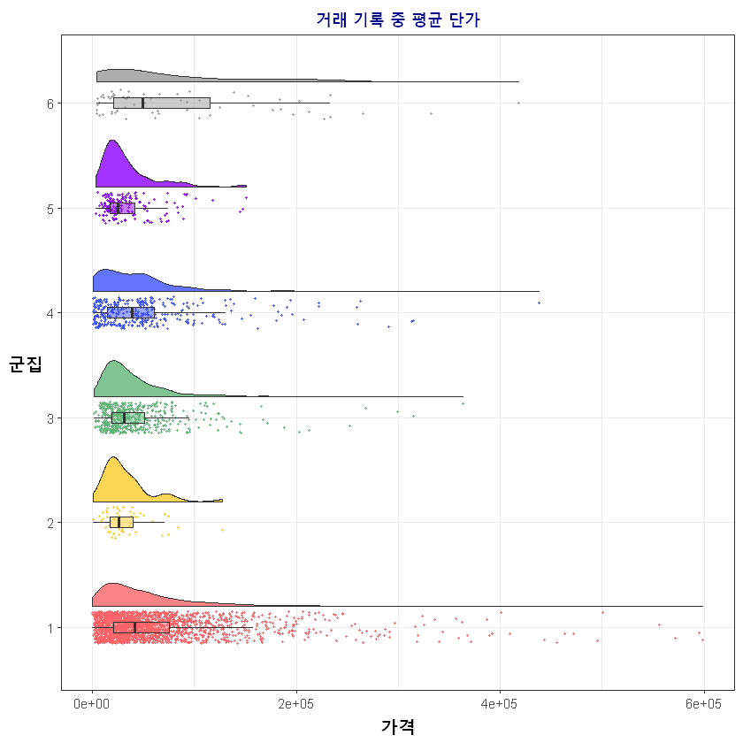

```r
final_df %>%
  ggplot(aes(cluster,mean_orrpr, fill=cluster))+
  geom_flat_violin(position = position_nudge(x = .2, y = 0), alpha = .8) +
  geom_point(aes(y = mean_orrpr, color = cluster), position = position_jitter(width = .15), size = .5, alpha = 0.8) +
  geom_boxplot(width = .1, outlier.shape = NA, alpha = 0.5) +
  expand_limits(x = 5.25) +
  scale_color_manual(values =col_2) + scale_fill_manual(values =col_2) +
  coord_flip() +theme_bw() +  xlab('군집') + ylab('가격') +
  ggtitle("거래 기록 중 평균 단가") + theme_1 +
  scale_y_continuous(limits = c(0,600000) )
```

```r
################ 투자중심성 ==> oss_trd / kr_oss_iem_ratio / kr_oss_freq_ratio / kr_oss_totpr_ratio ###
# oss_trd: 해외주식투자 경험 있으면 1
# table 형태
with(final_df, round(100*prop.table(table(cluster, oss_trd),2),2))
```

```
       oss_trd
cluster     0     1
      1 63.48 67.44
      2  1.70  0.93
      3 15.51 20.23
      4 12.24  4.42
      5  4.86  6.28
      6  2.20  0.70
```

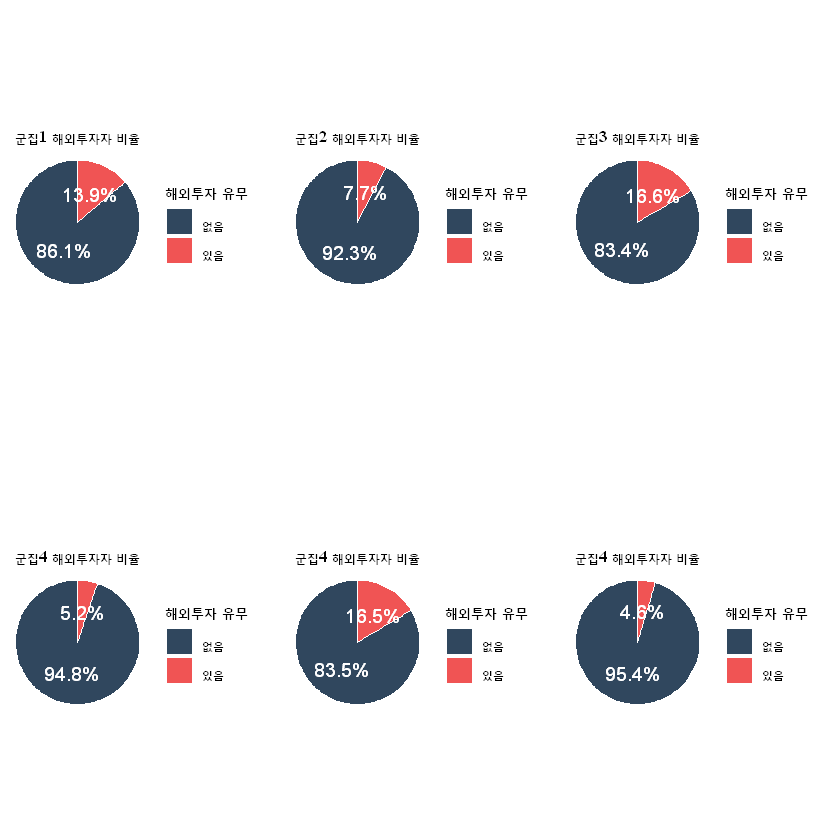

```r
#### 코드 / 시각화 설명 ####
### 군집별로 해외투자자 비율


oss_table <- table(final_df[final_df$cluster == 1,'oss_trd']) %>%
   data.frame() %>% rename(oss_trd= 'Var1', count = 'Freq') %>%
  arrange(desc('oss_trd')) %>%
  mutate(per = round(100*(count/sum(count)),1)) %>%
  mutate(ypos = cumsum(per) - 0.5*per)


a <- ggplot(oss_table, aes(x="", y=per, fill = factor(oss_trd))) +
  geom_bar(width = 1, stat='identity', color = 'white') +
  coord_polar("y", start = 0) +
  geom_text(aes(label = paste0(per,'%')),position = position_stack(vjust = 0.5),color = "white",size = 4) +
  scale_fill_manual(values = c('#30475E','#F05454'), name="해외투자 유무",breaks=c(0,1),labels=c("없음",'있음')) + theme_void() +
  ggtitle('군집1 해외투자자 비율') +
  theme(plot.title = element_text(family = "serif", face = "bold", hjust = 0.5, size = 10, color = "black"),
        text =element_text(face = "bold"))

oss_table <- table(final_df[final_df$cluster == 2,'oss_trd']) %>%
  data.frame() %>% rename(oss_trd= 'Var1', count = 'Freq') %>%
  arrange(desc('oss_trd')) %>%
  mutate(per = round(100*(count/sum(count)),1)) %>%
  mutate(ypos = cumsum(per) - 0.5*per)

b <- ggplot(oss_table, aes(x="", y=per, fill = factor(oss_trd))) +
  geom_bar(width = 1, stat='identity', color = 'white') +
  coord_polar("y", start = 0) +
  geom_text(aes(label = paste0(per,'%')),position = position_stack(vjust = 0.5),color = "white",size = 4) +
  scale_fill_manual(values = c('#30475E','#F05454'), name="해외투자 유무",breaks=c(0,1),labels=c("없음",'있음')) + theme_void() +
  ggtitle('군집2 해외투자자 비율') +
  theme(plot.title = element_text(family = "serif", face = "bold", hjust = 0.5, size = 10, color = "black"),
        text =element_text(face = "bold"))

oss_table <- table(final_df[final_df$cluster == 3,'oss_trd']) %>%
  data.frame() %>% rename(oss_trd= 'Var1', count = 'Freq') %>%
  arrange(desc('oss_trd')) %>%
  mutate(per = round(100*(count/sum(count)),1)) %>%
  mutate(ypos = cumsum(per) - 0.5*per)

c <- ggplot(oss_table, aes(x="", y=per, fill = factor(oss_trd))) +
  geom_bar(width = 1, stat='identity', color = 'white') +
  coord_polar("y", start = 0) +
  geom_text(aes(label = paste0(per,'%')),position = position_stack(vjust = 0.5),color = "white",size = 4) +
  scale_fill_manual(values = c('#30475E','#F05454'), name="해외투자 유무",breaks=c(0,1),labels=c("없음",'있음')) + theme_void() +
  ggtitle('군집3 해외투자자 비율') +
  theme(plot.title = element_text(family = "serif", face = "bold", hjust = 0.5, size = 10, color = "black"),
        text =element_text(face = "bold"))


oss_table <- table(final_df[final_df$cluster == 4,'oss_trd']) %>%
  data.frame() %>% rename(oss_trd= 'Var1', count = 'Freq') %>%
  arrange(desc('oss_trd')) %>%
  mutate(per = round(100*(count/sum(count)),1)) %>%
  mutate(ypos = cumsum(per) - 0.5*per)

d <- ggplot(oss_table, aes(x="", y=per, fill = factor(oss_trd))) +
  geom_bar(width = 1, stat='identity', color = 'white') +
  coord_polar("y", start = 0) +
  geom_text(aes(label = paste0(per,'%')),position = position_stack(vjust = 0.5),color = "white",size = 4) +
  scale_fill_manual(values = c('#30475E','#F05454'), name="해외투자 유무",breaks=c(0,1),labels=c("없음",'있음')) + theme_void() +
  ggtitle('군집4 해외투자자 비율') +
  theme(plot.title = element_text(family = "serif", face = "bold", hjust = 0.5, size = 10, color = "black"),
        text =element_text(face = "bold"))


oss_table <- table(final_df[final_df$cluster == 5,'oss_trd']) %>%
  data.frame() %>% rename(oss_trd= 'Var1', count = 'Freq') %>%
  arrange(desc('oss_trd')) %>%
  mutate(per = round(100*(count/sum(count)),1)) %>%
  mutate(ypos = cumsum(per) - 0.5*per)

e <- ggplot(oss_table, aes(x="", y=per, fill = factor(oss_trd))) +
  geom_bar(width = 1, stat='identity', color = 'white') +
  coord_polar("y", start = 0) +
  geom_text(aes(label = paste0(per,'%')),position = position_stack(vjust = 0.5),color = "white",size = 4) +
  scale_fill_manual(values = c('#30475E','#F05454'), name="해외투자 유무",breaks=c(0,1),labels=c("없음",'있음')) + theme_void() +
  ggtitle('군집4 해외투자자 비율') +
  theme(plot.title = element_text(family = "serif", face = "bold", hjust = 0.5, size = 10, color = "black"),
        text =element_text(face = "bold"))


oss_table <- table(final_df[final_df$cluster == 6,'oss_trd']) %>%
  data.frame() %>% rename(oss_trd= 'Var1', count = 'Freq') %>%
  arrange(desc('oss_trd')) %>%
  mutate(per = round(100*(count/sum(count)),1)) %>%
  mutate(ypos = cumsum(per) - 0.5*per)

f <- ggplot(oss_table, aes(x="", y=per, fill = factor(oss_trd))) +
  geom_bar(width = 1, stat='identity', color = 'white') +
  coord_polar("y", start = 0) +
  geom_text(aes(label = paste0(per,'%')),position = position_stack(vjust = 0.5),color = "white",size = 4) +
  scale_fill_manual(values = c('#30475E','#F05454'), name="해외투자 유무",breaks=c(0,1),labels=c("없음",'있음')) + theme_void() +
  ggtitle('군집4 해외투자자 비율') +
  theme(plot.title = element_text(family = "serif", face = "bold", hjust = 0.5, size = 10, color = "black"),
        text =element_text(face = "bold"))

grid.arrange(a,b,c,d,e,f,nrow = 2, ncol = 3)
```

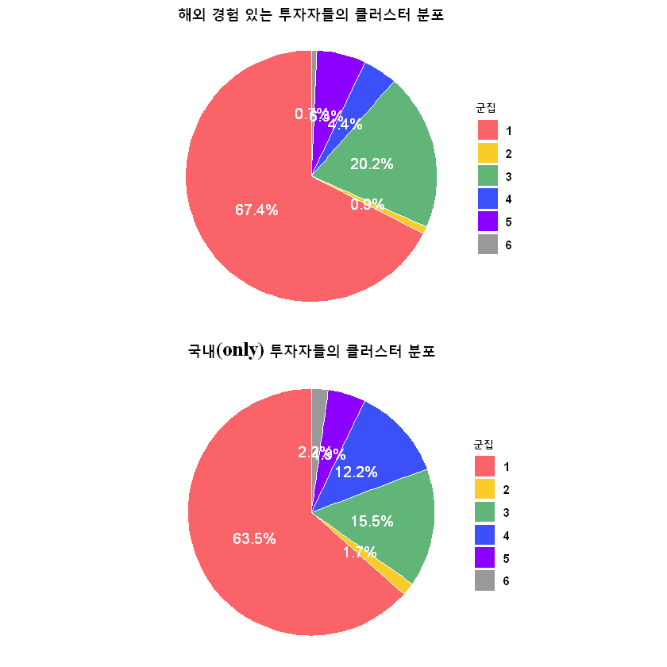

```r
#### 코드 / 시각화 설명 ###
### ==> 해외 경험 있는 사람들 기준 각 군집 비율 (oss_trd == 1)
### ==> 해외 경험 없는 사람들 기준 각 군집 비율 (oss_trd == 0)

oss_table <- table(final_df[final_df$oss_trd == 1,'cluster']) %>%
  data.frame() %>% rename(cluster = 'Var1', count = 'Freq') %>%
  arrange(desc('cluster')) %>%
  mutate(per = round(100*(count/sum(count)),1)) %>%
  mutate(ypos = cumsum(per) - 0.5*per)

a <- ggplot(oss_table, aes(x="", y=per, fill = factor(cluster))) +
  geom_bar(width = 1, stat='identity', color = 'white') +
  coord_polar("y", start = 0) +
  geom_text(aes(label = paste0(per,'%')),position = position_stack(vjust = 0.5),color = "white",size = 4) +
  scale_fill_manual(values = c('#FA6368','#FACC2A', '#62B578','#3C50FA','#8b00ff','#999999'), name="군집") + theme_void() +
  ggtitle('해외 경험 있는 투자자들의 클러스터 분포') +
  theme(plot.title = element_text(family = "serif", face = "bold", hjust = 0.5, size = 15, color = "black"),
        text =element_text(face = "bold"))

kr_table <- table(final_df[final_df$oss_trd == 0,'cluster']) %>%
  data.frame() %>% rename(cluster = 'Var1', count = 'Freq') %>%
  arrange(desc('cluster')) %>%
  mutate(per = round(100*(count/sum(count)),1)) %>%
  mutate(ypos = cumsum(per) - 0.5*per)

b <- ggplot(kr_table, aes(x="", y=per, fill = factor(cluster))) +
  geom_bar(width = 1, stat='identity', color = 'white') +
  coord_polar("y", start = 0) +
  geom_text(aes(label = paste0(per,'%')),position = position_stack(vjust = 0.5),color = "white",size = 4) +
  scale_fill_manual(values = c('#FA6368','#FACC2A', '#62B578','#3C50FA','#8b00ff','#999999'), name="군집") + theme_void() +
  ggtitle('국내(only) 투자자들의 클러스터 분포') +
  theme(plot.title = element_text(family = "serif", face = "bold", hjust = 0.5, size = 15, color = "black"),
        text =element_text(face = "bold"))

grid.arrange(a,b,nrow = 2,ncol = 1)
```

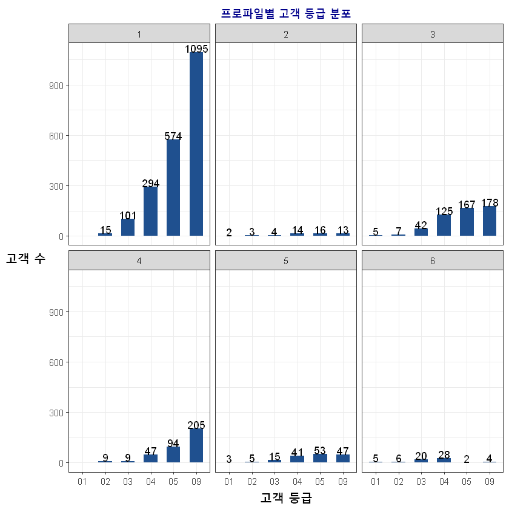

```r
######### 군집별 등급 분포 확인  ########################################
final_df <- left_join(final_df, cus_info, by='cus_id')

grade_tb <- final_df %>% group_by(cluster, tco_cus_grd_cd) %>% summarise(count = n_distinct(cus_id)) %>%
  data.frame()

grade_tb %>%
  ggplot(aes(x= tco_cus_grd_cd, y = count)) +
  geom_bar(stat="identity",width=.6,fill = "#1F508F") +
  ylab('고객 수') + xlab('고객 등급') +
  theme_bw() +
  ggtitle('프로파일별 고객 등급 분포') +
  geom_text(aes(label = count), vjust = 0, color = "black") +
  theme(axis.title.x = element_text(size  = 15, face  = "bold", angle = 0, vjust = 0.5),
        axis.title.y = element_text(size  = 15, face  = "bold", angle = 0, vjust = 0.5),
        plot.title = element_text(family = "serif", face = "bold", hjust = 0.5, size = 15, color = "darkblue")) +
facet_wrap(~cluster)
```

```r
## 각 등급안에서 비교하는 시각화
with(final_df, round(100*prop.table(table(cluster,tco_cus_grd_cd),2)))
```

```
       tco_cus_grd_cd
cluster _   01  02  03  04  05  09
      1      0  33  53  54  63  71
      2     13   7   2   3   2   1
      3     33  16  22  23  18  12
      4      0  20   5   9  10  13
      5     20  11   8   7   6   3
      6     33  13  10   5   0   0
```

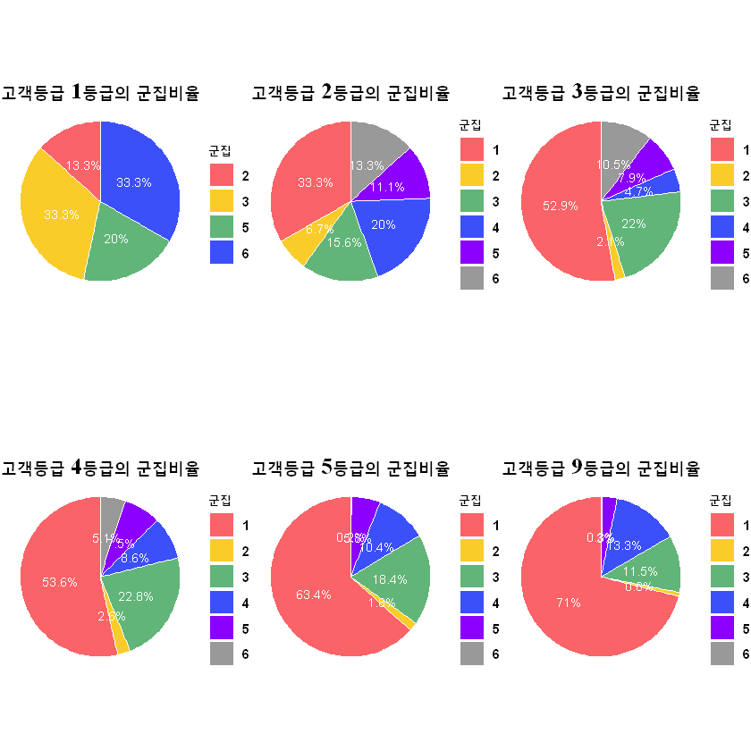

```r
### 각 등급별 클러스터 비율

grd_table <- grade_tb %>% filter(tco_cus_grd_cd == '01') %>%
  arrange(desc('cluster')) %>%
  mutate(per = round(100*(count/sum(count)),1)) %>%
  mutate(ypos = cumsum(per) - 0.5*per)

a <- ggplot(grd_table, aes(x="", y=per, fill = factor(cluster))) +
  geom_bar(width = 1, stat='identity', color = 'white') +
  coord_polar("y", start = 0) +
  geom_text(aes(label = paste0(per,'%')),position = position_stack(vjust = 0.5),color = "white",size = 3) +
  scale_fill_manual(values = c('#FA6368','#FACC2A', '#62B578','#3C50FA','#8b00ff','#999999'), name="군집") + theme_void() +
  ggtitle('고객등급 1등급의 군집비율') +
  theme(plot.title = element_text(family = "serif", face = "bold", hjust = 0.5, size = 15, color = "black"),
        text =element_text(face = "bold"))


grd_table <- grade_tb %>% filter(tco_cus_grd_cd == '02') %>%
  arrange(desc('cluster')) %>%
  mutate(per = round(100*(count/sum(count)),1)) %>%
  mutate(ypos = cumsum(per) - 0.5*per)

b <- ggplot(grd_table, aes(x="", y=per, fill = factor(cluster))) +
  geom_bar(width = 1, stat='identity', color = 'white') +
  coord_polar("y", start = 0) +
  geom_text(aes(label = paste0(per,'%')),position = position_stack(vjust = 0.5),color = "white",size = 3) +
  scale_fill_manual(values = c('#FA6368','#FACC2A', '#62B578','#3C50FA','#8b00ff','#999999'), name="군집") + theme_void() +
  ggtitle('고객등급 2등급의 군집비율') +
  theme(plot.title = element_text(family = "serif", face = "bold", hjust = 0.5, size = 15, color = "black"),
        text =element_text(face = "bold"))

grd_table <- grade_tb %>% filter(tco_cus_grd_cd == '03') %>%
  arrange(desc('cluster')) %>%
  mutate(per = round(100*(count/sum(count)),1)) %>%
  mutate(ypos = cumsum(per) - 0.5*per)

c <- ggplot(grd_table, aes(x="", y=per, fill = factor(cluster))) +
  geom_bar(width = 1, stat='identity', color = 'white') +
  coord_polar("y", start = 0) +
  geom_text(aes(label = paste0(per,'%')),position = position_stack(vjust = 0.5),color = "white",size =3) +
  scale_fill_manual(values = c('#FA6368','#FACC2A', '#62B578','#3C50FA','#8b00ff','#999999'), name="군집") + theme_void() +
  ggtitle('고객등급 3등급의 군집비율') +
  theme(plot.title = element_text(family = "serif", face = "bold", hjust = 0.5, size = 15, color = "black"),
        text =element_text(face = "bold"))

grd_table <- grade_tb %>% filter(tco_cus_grd_cd == '04') %>%
  arrange(desc('cluster')) %>%
  mutate(per = round(100*(count/sum(count)),1)) %>%
  mutate(ypos = cumsum(per) - 0.5*per)

d <- ggplot(grd_table, aes(x="", y=per, fill = factor(cluster))) +
  geom_bar(width = 1, stat='identity', color = 'white') +
  coord_polar("y", start = 0) +
  geom_text(aes(label = paste0(per,'%')),position = position_stack(vjust = 0.5),color = "white",size = 3) +
  scale_fill_manual(values = c('#FA6368','#FACC2A', '#62B578','#3C50FA','#8b00ff','#999999'), name="군집") + theme_void() +
  ggtitle('고객등급 4등급의 군집비율') +
  theme(plot.title = element_text(family = "serif", face = "bold", hjust = 0.5, size = 15, color = "black"),
        text =element_text(face = "bold"))


grd_table <- grade_tb %>% filter(tco_cus_grd_cd == '05') %>%
  arrange(desc('cluster')) %>%
  mutate(per = round(100*(count/sum(count)),1)) %>%
  mutate(ypos = cumsum(per) - 0.5*per)

e <- ggplot(grd_table, aes(x="", y=per, fill = factor(cluster))) +
  geom_bar(width = 1, stat='identity', color = 'white') +
  coord_polar("y", start = 0) +
  geom_text(aes(label = paste0(per,'%')),position = position_stack(vjust = 0.5),color = "white",size = 3) +
  scale_fill_manual(values = c('#FA6368','#FACC2A', '#62B578','#3C50FA','#8b00ff','#999999'), name="군집") + theme_void() +
  ggtitle('고객등급 5등급의 군집비율') +
  theme(plot.title = element_text(family = "serif", face = "bold", hjust = 0.5, size = 15, color = "black"),
        text =element_text(face = "bold"))

grd_table <- grade_tb %>% filter(tco_cus_grd_cd == '09') %>%
  arrange(desc('cluster')) %>%
  mutate(per = round(100*(count/sum(count)),1)) %>%
  mutate(ypos = cumsum(per) - 0.5*per)

f <- ggplot(grd_table, aes(x="", y=per, fill = factor(cluster))) +
  geom_bar(width = 1, stat='identity', color = 'white') +
  coord_polar("y", start = 0) +
  geom_text(aes(label = paste0(per,'%')),position = position_stack(vjust = 0.5),color = "white",size = 3) +
  scale_fill_manual(values = c('#FA6368','#FACC2A', '#62B578','#3C50FA','#8b00ff','#999999'), name="군집") + theme_void() +
  ggtitle('고객등급 9등급의 군집비율') +
  theme(plot.title = element_text(family = "serif", face = "bold", hjust = 0.5, size = 15, color = "black"),
        text =element_text(face = "bold"))

grid.arrange(a,b,c,d,e,f,nrow = 2,ncol = 3)
```

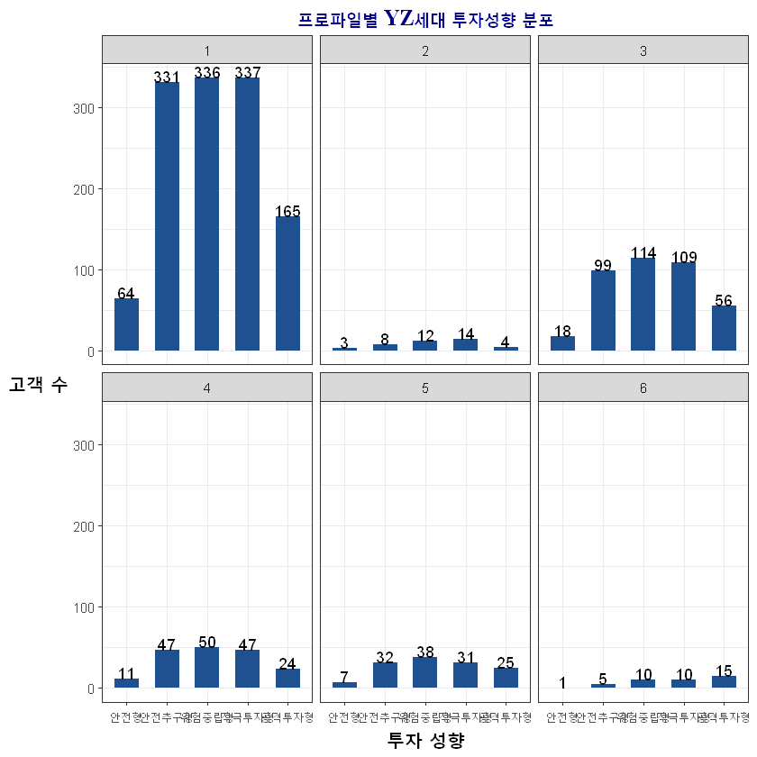

```r
###### 군집별 투자성향 분포 #####
label_ivs <- c('안전형','안전추구형','위험중립형','적극투자형','공격투자형')


icn_tb <- final_df %>% group_by(cluster, ivs_icn_cd) %>% summarise(count = n_distinct(cus_id)) %>%
  data.frame()

icn_tb %>%
  filter(ivs_icn_cd %in% c('01','02','03','04','05')) %>%  # - 랑 9제외 ==> 9는 한명뿐이라서
  ggplot(aes(x= ivs_icn_cd, y = count)) +
  geom_bar(stat="identity",width=.6,fill = "#1F508F") +
  ylab('고객 수') + xlab('투자 성향') +
  theme_bw() +
  ggtitle('프로파일별 YZ세대 투자성향 분포') +
  geom_text(aes(label = count), vjust = 0, color = "black") +
  theme(axis.title.x = element_text(size  = 15, face  = "bold", angle = 0, vjust = 0.5),
        axis.title.y = element_text(size  = 15, face  = "bold", angle = 0, vjust = 0.5),
        plot.title = element_text(family = "serif", face = "bold", hjust = 0.5, size = 15, color = "darkblue")) +
  facet_wrap(~cluster) +
  scale_x_discrete(labels = label_ivs )
```

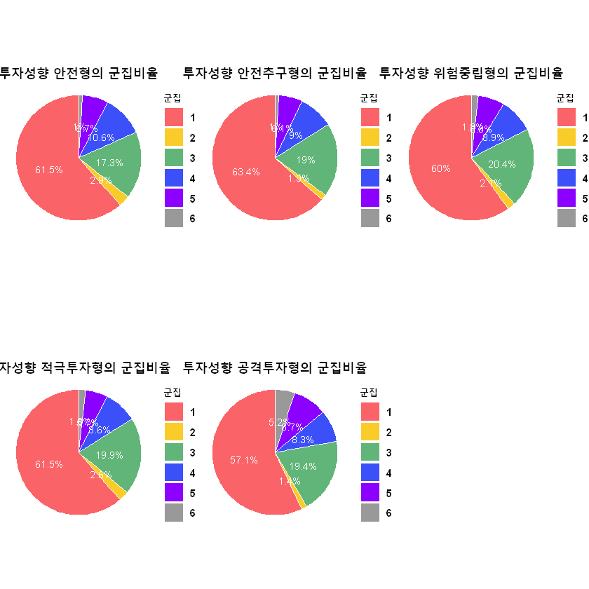

```r
####### 각 성향별 군집 분포 ########



ivs_table <- icn_tb %>% filter(ivs_icn_cd == '01') %>%
  arrange(desc('cluster')) %>%
  mutate(per = round(100*(count/sum(count)),1)) %>%
  mutate(ypos = cumsum(per) - 0.5*per)

a <- ggplot(ivs_table, aes(x="", y=per, fill = factor(cluster))) +
  geom_bar(width = 1, stat='identity', color = 'white') +
  coord_polar("y", start = 0) +
  geom_text(aes(label = paste0(per,'%')),position = position_stack(vjust = 0.5),color = "white",size = 3) +
  scale_fill_manual(values = c('#FA6368','#FACC2A', '#62B578','#3C50FA','#8b00ff','#999999'), name="군집") + theme_void() +
  ggtitle('투자성향 안전형의 군집비율') +
  theme(plot.title = element_text(family = "serif", face = "bold", hjust = 0.5, size = 15, color = "black"),
        text =element_text(face = "bold"))


ivs_table <- icn_tb %>% filter(ivs_icn_cd == '02') %>%
  arrange(desc('cluster')) %>%
  mutate(per = round(100*(count/sum(count)),1)) %>%
  mutate(ypos = cumsum(per) - 0.5*per)

b <- ggplot(ivs_table, aes(x="", y=per, fill = factor(cluster))) +
  geom_bar(width = 1, stat='identity', color = 'white') +
  coord_polar("y", start = 0) +
  geom_text(aes(label = paste0(per,'%')),position = position_stack(vjust = 0.5),color = "white",size = 3) +
  scale_fill_manual(values = c('#FA6368','#FACC2A', '#62B578','#3C50FA','#8b00ff','#999999'), name="군집") + theme_void() +
  ggtitle('투자성향 안전추구형의 군집비율') +
  theme(plot.title = element_text(family = "serif", face = "bold", hjust = 0.5, size = 15, color = "black"),
        text =element_text(face = "bold"))


ivs_table <- icn_tb %>% filter(ivs_icn_cd == '03') %>%
  arrange(desc('cluster')) %>%
  mutate(per = round(100*(count/sum(count)),1)) %>%
  mutate(ypos = cumsum(per) - 0.5*per)

c <- ggplot(ivs_table, aes(x="", y=per, fill = factor(cluster))) +
  geom_bar(width = 1, stat='identity', color = 'white') +
  coord_polar("y", start = 0) +
  geom_text(aes(label = paste0(per,'%')),position = position_stack(vjust = 0.5),color = "white",size = 3) +
  scale_fill_manual(values = c('#FA6368','#FACC2A', '#62B578','#3C50FA','#8b00ff','#999999'), name="군집") + theme_void() +
  ggtitle('투자성향 위험중립형의 군집비율') +
  theme(plot.title = element_text(family = "serif", face = "bold", hjust = 0.5, size = 15, color = "black"),
        text =element_text(face = "bold"))


ivs_table <- icn_tb %>% filter(ivs_icn_cd == '04') %>%
  arrange(desc('cluster')) %>%
  mutate(per = round(100*(count/sum(count)),1)) %>%
  mutate(ypos = cumsum(per) - 0.5*per)

d <- ggplot(ivs_table, aes(x="", y=per, fill = factor(cluster))) +
  geom_bar(width = 1, stat='identity', color = 'white') +
  coord_polar("y", start = 0) +
  geom_text(aes(label = paste0(per,'%')),position = position_stack(vjust = 0.5),color = "white",size = 3) +
  scale_fill_manual(values = c('#FA6368','#FACC2A', '#62B578','#3C50FA','#8b00ff','#999999'), name="군집") + theme_void() +
  ggtitle('투자성향 적극투자형의 군집비율') +
  theme(plot.title = element_text(family = "serif", face = "bold", hjust = 0.5, size = 15, color = "black"),
        text =element_text(face = "bold"))


ivs_table <- icn_tb %>% filter(ivs_icn_cd == '05') %>%
  arrange(desc('cluster')) %>%
  mutate(per = round(100*(count/sum(count)),1)) %>%
  mutate(ypos = cumsum(per) - 0.5*per)

e <- ggplot(ivs_table, aes(x="", y=per, fill = factor(cluster))) +
  geom_bar(width = 1, stat='identity', color = 'white') +
  coord_polar("y", start = 0) +
  geom_text(aes(label = paste0(per,'%')),position = position_stack(vjust = 0.5),color = "white",size = 3) +
  scale_fill_manual(values = c('#FA6368','#FACC2A', '#62B578','#3C50FA','#8b00ff','#999999'), name="군집") + theme_void() +
  ggtitle('투자성향 공격투자형의 군집비율') +
  theme(plot.title = element_text(family = "serif", face = "bold", hjust = 0.5, size = 15, color = "black"),
        text =element_text(face = "bold"))

grid.arrange(a,b,c,d,e,nrow = 2,ncol = 3)
```

# 4. Conclusion (결론)

## 4.1 Implication (시사점)

### 1. 해외 투자 경험 유무에 상관없이 프로파일의 분포 비율은 비슷하다.

```
고객군은 해외 투자 경험을 한다해도 거시적으로 비슷하다.
```

### 2. Y&Z세대 대부분의 투자자들의 수익은 제로섬 (zero-sum)이다.

```
높은 수익을 얻는 것은 소수이다. 오히려 약간의 손해를 보는 경우가 많다. 일확천금은 드물다.
```

### 3. Y&Z세대 대부분의 투자자들은 많은 종목을 경험해보지 않았다.

```
고액의 장기 투자자들도 적은 종목의 경험 위주다.
```

### 4. 주식을 '자주', '꾸준히' 투자를 하는 고객군이 수익 편차가 작다.

```
 이들은 많은 종목을 경험해보았고, 큰 손해를 보진 않는다.
```

### 5. 최근에 소액 매수하는 간헐적 주기의 투자자는 코스닥 상위 200종목에는 투자를 잘 하지 않는다.

```
이들은 코스피 상위 200종목에 대해서도 극단적인 태도를 보인다. (아예 코스피 상위 200종목 vs 아예 코스피 상위200종목 X)
이들은 아직 많은 종목을 경험해보지도 못했다.
```

## 4.2 Proposal 1 (기획 1: 커뮤니티, 네트워킹, 멘토링, 팔로워)

## 같은 고객 프로파일에 속하는 투자자들간의 팔로잉 시스템을 구축한다.

#### ▶ 기대효과

```
Y&Z세대는 개성 표현과 디지털 소통에 익숙하기 때문에, 비슷한 집단에 속한 사람들간의 정보 교류를 희망한다. 따라서 서로간의 팔로잉 시스템을 통해 주식 모바일 어플에 더 자주 접속하게 되고, 자연스레 거래로까지 이어질 수 있다.
```

#### ▶ Y&Z 세대 투자자에게 본인이 속한 프로파일 집단을 알려준다.

```
투자자들의 자신에 대한 개성을 확인할 수 있고, 동시에 고객 프로파일마다의 특성을 알려준다. 특히 주식을 '자주', '꾸준히'하는 투자자가 수익 편차가 적고, 결과적으로 큰 손해를 보지 않을 확률이 높다는 것을 강조한다.
    결국 투자자들은 주식을 자주, 꾸준히 하도록 유도하여 증권사 입장에서는 수익을 발생시키고, 고객들은 자연스레 자주/꾸준히 투자하는 고객군에 가까워지면서 수익편차가 줄어드는 안정적인 효과를 얻는다. 증권사 입장에서도 지속적으로 주식을 자주/꾸준히 하는 편이 큰 손해를 보지 않는다는 것을 강조하여 알려준다.
```

#### ▶ Y&Z세대의 특징을 살린다

```
투자자들의 개성과 소통 욕구를 충족시켜줌과 동시에 고객으로서의 충성심이 아닌 흥미를 통한 재방문을 높이는 방향의 전략.
기부로 누적된 금액이 얼마인지 개인이 확인할 수 있도록 한다. 즉, 포인트처럼 적립하는 즐거움을 통해 투자자들에게 또 다른 만족감을 부여.
```

## 4.3 Proposal 2 (기획 2: 기부 & 포인트 적립 개념)

## 주식 투자시 발생하는 수수료의 일정 %를 기부하는 제도를 구축한다.

#### ▶ 기대효과

```
기부 시스템을 구축하여 플랫폼을 운영은 NH투자증권의 이미지 향상과 차별적 요소로 이용자의 꾸준한 방문을 유도할 수 있고, 이용자들은 주식 거래뿐만 아니라 기부를 통한 만족감을 얻을 수 있다 (손소영 et al., 2019)
```

#### ▶ Y&Z 세대 투자자에게 본인이 속한 프로파일 집단을 알려준다.

```
투자자들의 자신에 대한 개성을 확인할 수 있고, 동시에 고객 프로파일마다의 특성을 알려준다. 특히 주식을 '자주', '꾸준히'하는 투자자가 수익 편차가 적고, 결과적으로 큰 손해를 보지 않을 확률이 높다는 것을 강조한다.
    결국 투자자들은 주식을 자주, 꾸준히 하도록 유도하여 증권사 입장에서는 수익을 발생시키고, 고객들은 자연스레 자주/꾸준히 투자하는 고객군에 가까워지면서 수익편차가 줄어드는 안정적인 효과를 얻는다. 증권사 입장에서도 지속적으로 주식을 자주/꾸준히 하는 편이 큰 손해를 보지 않는다는 것을 강조하여 알려준다.
```

#### ▶ Y&Z세대의 특징을 살린다

```
투자자들의 개성과 소통 욕구를 충족시켜줌과 동시에 고객으로서의 충성심이 아닌 흥미를 통한 재방문을 높이는 방향의 전략.
기부로 누적된 금액이 얼마인지 개인이 확인할 수 있도록 한다. 즉, 포인트처럼 적립하는 즐거움을 통해 투자자들에게 또 다른 만족감을 부여.
```

# References (참고 문헌)

손소영, 김유정, & 나하나. (2019). 지역 사회 기부속성을 고려한 배달앱 고객 확대 방안. 한국품질경영학회 춘계학술발표논문집, 2019, 163-163.

이필원. (2019). [트렌드탐구] '소유 아닌 사용과 경험' 밀레니엄 세대 트렌드를 읽어라. 메가경제. Retrieved from https://www.megaeconomy.co.kr/news/newsview.php?ncode=179565914409356

Lee, J.M., Wei, Lu. (2018). Gen Z Is Set to Outnumber Millennials Within a Year. Bloomberg. Retrieved from https://www.bloomberg.com/news/articles/2018-08-20/gen-z-to-outnumber-millennials-within-a-year-demographic-trends

Fromm, J., Lindell, C., & Decker, L. (2011). American millennials: deciphering the enigma generation. Barkley, Kansas City, MO.